# Home Credit Default Risk (HCDR)

The course project is based on the [Home Credit Default Risk (HCDR) Kaggle Competition](https://www.kaggle.com/c/home-credit-default-risk/). The goal of this project is to predict whether or not a client will repay a loan. In order to make sure that people who struggle to get loans due to insufficient or non-existent credit histories have a positive loan experience, Home Credit makes use of a variety of alternative data--including telco and transactional information--to predict their clients' repayment abilities.

## Some of the challenges

1. Dataset size
   - (688 meg uncompressed) with millions of rows of data
   - 2.71 Gig of data uncompressed
2. Dealing with missing data
3. Imbalanced datasets
4. Summarizing transaction data

# Kaggle API setup

Kaggle is a Data Science Competition Platform which shares a lot of datasets. In the past, it was troublesome to submit your result as your have to go through the console in your browser and drag your files there. Now you can interact with Kaggle via the command line. E.g.,

```
! kaggle competitions files home-credit-default-risk
```

It is quite easy to setup, it takes me less than 15 minutes to finish a submission.

1. Install library
2. Create a API Token (edit your profile on [Kaggle.com](https://www.kaggle.com/)); this produces `kaggle.json` file
3. Put your JSON `kaggle.json` in the right place
4. Access competition files; make submissions via the command (see examples below)
5. Submit result

For more detailed information on setting the Kaggle API see [here](https://medium.com/@nokkk/make-your-kaggle-submissions-with-kaggle-official-api-f49093c04f8a) and [here](https://github.com/Kaggle/kaggle-api).

```python
# !pip install kaggle
```

```python
# from google.colab import files
# files.upload()
```

```python
# !mkdir -p ~/.kaggle
# !cp kaggle.json ~/.kaggle/
# !chmod 600 ~/.kaggle/kaggle.json
# !ls ~/.kaggle
```

```python
# !ls -l ~/.kaggle
# !cat ~/.kaggle/kaggle.json
```

```python
# ! kaggle competitions files home-credit-default-risk
```

# Dataset and how to download

## Back ground Home Credit Group

Many people struggle to get loans due to insufficient or non-existent credit histories. And, unfortunately, this population is often taken advantage of by untrustworthy lenders.

### Home Credit Group

Home Credit strives to broaden financial inclusion for the unbanked population by providing a positive and safe borrowing experience. In order to make sure this underserved population has a positive loan experience, Home Credit makes use of a variety of alternative data--including telco and transactional information--to predict their clients' repayment abilities.

While Home Credit is currently using various statistical and machine learning methods to make these predictions, they're challenging Kagglers to help them unlock the full potential of their data. Doing so will ensure that clients capable of repayment are not rejected and that loans are given with a principal, maturity, and repayment calendar that will empower their clients to be successful.

## Background on the dataset

Home Credit is a non-banking financial institution, founded in 1997 in the Czech Republic.

The company operates in 14 countries (including United States, Russia, Kazahstan, Belarus, China, India) and focuses on lending primarily to people with little or no credit history which will either not obtain loans or became victims of untrustworthly lenders.

Home Credit group has over 29 million customers, total assests of 21 billions Euro, over 160 millions loans, with the majority in Asia and and almost half of them in China (as of 19-05-2018).

While Home Credit is currently using various statistical and machine learning methods to make these predictions, they're challenging Kagglers to help them unlock the full potential of their data. Doing so will ensure that clients capable of repayment are not rejected and that loans are given with a principal, maturity, and repayment calendar that will empower their clients to be successful.

## Data files overview

There are 7 different sources of data:

- **application_train/application_test:** the main training and testing data with information about each loan application at Home Credit. Every loan has its own row and is identified by the feature SK_ID_CURR. The training application data comes with the TARGET indicating **0: the loan was repaid** or **1: the loan was not repaid**. The target variable defines if the client had payment difficulties meaning he/she had late payment more than X days on at least one of the first Y installments of the loan. Such case is marked as 1 while other all other cases as 0.
- **bureau:** data concerning client's previous credits from other financial institutions. Each previous credit has its own row in bureau, but one loan in the application data can have multiple previous credits.
- **bureau_balance:** monthly data about the previous credits in bureau. Each row is one month of a previous credit, and a single previous credit can have multiple rows, one for each month of the credit length.
- **previous_application:** previous applications for loans at Home Credit of clients who have loans in the application data. Each current loan in the application data can have multiple previous loans. Each previous application has one row and is identified by the feature SK_ID_PREV.
- **POS_CASH_BALANCE:** monthly data about previous point of sale or cash loans clients have had with Home Credit. Each row is one month of a previous point of sale or cash loan, and a single previous loan can have many rows.
- credit_card_balance: monthly data about previous credit cards clients have had with Home Credit. Each row is one month of a credit card balance, and a single credit card can have many rows.
- **installments_payment:** payment history for previous loans at Home Credit. There is one row for every made payment and one row for every missed payment.

[figure not shown]

## Downloading the files via Kaggle API

Create a base directory:

```
DATA_DIR = "../../../Data/home-credit-default-risk"   #same level as course repo in the data directory
```

Please download the project data files and data dictionary and unzip them using either of the following approaches:

1. Click on the `Download` button on the following [Data Webpage](https://www.kaggle.com/c/home-credit-default-risk/data) and unzip the zip file to the `BASE_DIR`
2. If you plan to use the Kaggle API, please use the following steps.

```python
# DATA_DIR = "../../../Data/home-credit-default-risk"   #same level as course repo in the data directory
# #DATA_DIR = os.path.join('./ddddd/')
# !mkdir $BASE_DIR
```

```python
# !ls $DATA_DIR
```

```python
# ! kaggle competitions download home-credit-default-risk -p $DATA_DIR
```

### Imports

```python
import numpy as np
import pandas as pd
from sklearn.preprocessing import LabelEncoder
import os
import zipfile
from sklearn.base import BaseEstimator, TransformerMixin
import matplotlib.pyplot as plt
import seaborn as sns
from sklearn.linear_model import LogisticRegression
from sklearn.model_selection import train_test_split
from sklearn.model_selection import KFold
from sklearn.model_selection import cross_val_score
from sklearn.model_selection import GridSearchCV
from sklearn.impute import SimpleImputer
from sklearn.preprocessing import MinMaxScaler
from sklearn.pipeline import Pipeline, FeatureUnion
from pandas.plotting import scatter_matrix
from sklearn.preprocessing import StandardScaler
from sklearn.preprocessing import OneHotEncoder
import warnings

import re
from time import time
from scipy import stats
import json

warnings.filterwarnings('ignore')
plt.style.use('ggplot')
```

```python
# from google.colab import drive
# drive.mount('/content/gdrive')
```

```python
# os.chdir('/content/gdrive/My Drive/Final project')
# DATA_DIR = "/content/gdrive/My Drive/Final project/datasets"
```

```python
#this cell is required if using Kaggle API to download the data

# unzippingReq = False
# if unzippingReq: #please modify this code
#     zip_ref = zipfile.ZipFile('application_train.csv.zip', 'r')
#     zip_ref.extractall('datasets')
#     zip_ref.close()
#     zip_ref = zipfile.ZipFile('application_test.csv.zip', 'r')
#     zip_ref.extractall('datasets')
#     zip_ref.close()
#     zip_ref = zipfile.ZipFile('bureau_balance.csv.zip', 'r')
#     zip_ref.extractall('datasets')
#     zip_ref.close()
#     zip_ref = zipfile.ZipFile('bureau.csv.zip', 'r')
#     zip_ref.extractall('datasets')
#     zip_ref.close()
#     zip_ref = zipfile.ZipFile('credit_card_balance.csv.zip', 'r')
#     zip_ref.extractall('datasets')
#     zip_ref.close()
#     zip_ref = zipfile.ZipFile('installments_payments.csv.zip', 'r')
#     zip_ref.extractall('datasets')
#     zip_ref.close()
#     zip_ref = zipfile.ZipFile('POS_CASH_balance.csv.zip', 'r')
#     zip_ref.extractall('datasets')
#     zip_ref.close()
#     zip_ref = zipfile.ZipFile('previous_application.csv.zip', 'r')
#     zip_ref.extractall('datasets')
#     zip_ref.close()
```

## Data files overview

### Data Dictionary

As part of the data download comes a Data Dictionary. It named `HomeCredit_columns_description.csv`

[figure not shown]

### Application train

```python
import numpy as np
import pandas as pd
from sklearn.preprocessing import LabelEncoder
import os
import zipfile
from sklearn.base import BaseEstimator, TransformerMixin
import matplotlib.pyplot as plt
import seaborn as sns
from sklearn.linear_model import LogisticRegression
from sklearn.model_selection import train_test_split
from sklearn.model_selection import KFold
from sklearn.model_selection import cross_val_score
from sklearn.model_selection import GridSearchCV
from sklearn.impute import SimpleImputer
from sklearn.preprocessing import MinMaxScaler
from sklearn.pipeline import Pipeline, FeatureUnion
from pandas.plotting import scatter_matrix
from sklearn.preprocessing import StandardScaler
from sklearn.preprocessing import OneHotEncoder
import warnings
warnings.filterwarnings('ignore')

config_file = os.path.join(os.getcwd(), "workingdir.config")
with open(config_file, 'r') as f:
    WORKING_DIR = f.readline()
DATA_DIR = os.path.join(WORKING_DIR, 'Data')

def load_data(name):
    in_path = os.path.join(DATA_DIR, f'{name}.csv')
    df = pd.read_csv(in_path)
    print(f"{name}: shape is {df.shape}")
    print(df.info())
    display(df.head(5))
    return df

datasets={}  # lets store the datasets in a dictionary so we can keep track of them easily
ds_name = 'application_train'
datasets[ds_name] = load_data(ds_name)

datasets['application_train'].shape
```

```
application_train: shape is (307511, 122)
<class 'pandas.core.frame.DataFrame'>
RangeIndex: 307511 entries, 0 to 307510
Columns: 122 entries, SK_ID_CURR to AMT_REQ_CREDIT_BUREAU_YEAR
dtypes: float64(65), int64(41), object(16)
memory usage: 286.2+ MB
None
```

|  | SK_ID_CURR | TARGET | NAME_CONTRACT_TYPE | CODE_GENDER | FLAG_OWN_CAR | FLAG_OWN_REALTY | CNT_CHILDREN | AMT_INCOME_TOTAL | AMT_CREDIT | AMT_ANNUITY | ... | FLAG_DOCUMENT_18 | FLAG_DOCUMENT_19 | FLAG_DOCUMENT_20 | FLAG_DOCUMENT_21 | AMT_REQ_CREDIT_BUREAU_HOUR | AMT_REQ_CREDIT_BUREAU_DAY | AMT_REQ_CREDIT_BUREAU_WEEK | AMT_REQ_CREDIT_BUREAU_MON | AMT_REQ_CREDIT_BUREAU_QRT | AMT_REQ_CREDIT_BUREAU_YEAR |
| --- | --- | --- | --- | --- | --- | --- | --- | --- | --- | --- | --- | --- | --- | --- | --- | --- | --- | --- | --- | --- | --- |
| 0 | 100002 | 1 | Cash loans | M | N | Y | 0 | 202500.0 | 406597.5 | 24700.5 | ... | 0 | 0 | 0 | 0 | 0.0 | 0.0 | 0.0 | 0.0 | 0.0 | 1.0 |
| 1 | 100003 | 0 | Cash loans | F | N | N | 0 | 270000.0 | 1293502.5 | 35698.5 | ... | 0 | 0 | 0 | 0 | 0.0 | 0.0 | 0.0 | 0.0 | 0.0 | 0.0 |
| 2 | 100004 | 0 | Revolving loans | M | Y | Y | 0 | 67500.0 | 135000.0 | 6750.0 | ... | 0 | 0 | 0 | 0 | 0.0 | 0.0 | 0.0 | 0.0 | 0.0 | 0.0 |
| 3 | 100006 | 0 | Cash loans | F | N | Y | 0 | 135000.0 | 312682.5 | 29686.5 | ... | 0 | 0 | 0 | 0 | NaN | NaN | NaN | NaN | NaN | NaN |
| 4 | 100007 | 0 | Cash loans | M | N | Y | 0 | 121500.0 | 513000.0 | 21865.5 | ... | 0 | 0 | 0 | 0 | 0.0 | 0.0 | 0.0 | 0.0 | 0.0 | 0.0 |

5 rows × 122 columns

```
(307511, 122)
```

### Application test

- **application_train/application_test:** the main training and testing data with information about each loan application at Home Credit. Every loan has its own row and is identified by the feature SK_ID_CURR. The training application data comes with the TARGET indicating **0: the loan was repaid** or **1: the loan was not repaid**. The target variable defines if the client had payment difficulties meaning he/she had late payment more than X days on at least one of the first Y installments of the loan. Such case is marked as 1 while other all other cases as 0.

```python
ds_name = 'application_test'
datasets[ds_name] = load_data(ds_name)
```

```
application_test: shape is (48744, 121)
<class 'pandas.core.frame.DataFrame'>
RangeIndex: 48744 entries, 0 to 48743
Columns: 121 entries, SK_ID_CURR to AMT_REQ_CREDIT_BUREAU_YEAR
dtypes: float64(65), int64(40), object(16)
memory usage: 45.0+ MB
None
```

|  | SK_ID_CURR | NAME_CONTRACT_TYPE | CODE_GENDER | FLAG_OWN_CAR | FLAG_OWN_REALTY | CNT_CHILDREN | AMT_INCOME_TOTAL | AMT_CREDIT | AMT_ANNUITY | AMT_GOODS_PRICE | ... | FLAG_DOCUMENT_18 | FLAG_DOCUMENT_19 | FLAG_DOCUMENT_20 | FLAG_DOCUMENT_21 | AMT_REQ_CREDIT_BUREAU_HOUR | AMT_REQ_CREDIT_BUREAU_DAY | AMT_REQ_CREDIT_BUREAU_WEEK | AMT_REQ_CREDIT_BUREAU_MON | AMT_REQ_CREDIT_BUREAU_QRT | AMT_REQ_CREDIT_BUREAU_YEAR |
| --- | --- | --- | --- | --- | --- | --- | --- | --- | --- | --- | --- | --- | --- | --- | --- | --- | --- | --- | --- | --- | --- |
| 0 | 100001 | Cash loans | F | N | Y | 0 | 135000.0 | 568800.0 | 20560.5 | 450000.0 | ... | 0 | 0 | 0 | 0 | 0.0 | 0.0 | 0.0 | 0.0 | 0.0 | 0.0 |
| 1 | 100005 | Cash loans | M | N | Y | 0 | 99000.0 | 222768.0 | 17370.0 | 180000.0 | ... | 0 | 0 | 0 | 0 | 0.0 | 0.0 | 0.0 | 0.0 | 0.0 | 3.0 |
| 2 | 100013 | Cash loans | M | Y | Y | 0 | 202500.0 | 663264.0 | 69777.0 | 630000.0 | ... | 0 | 0 | 0 | 0 | 0.0 | 0.0 | 0.0 | 0.0 | 1.0 | 4.0 |
| 3 | 100028 | Cash loans | F | N | Y | 2 | 315000.0 | 1575000.0 | 49018.5 | 1575000.0 | ... | 0 | 0 | 0 | 0 | 0.0 | 0.0 | 0.0 | 0.0 | 0.0 | 3.0 |
| 4 | 100038 | Cash loans | M | Y | N | 1 | 180000.0 | 625500.0 | 32067.0 | 625500.0 | ... | 0 | 0 | 0 | 0 | NaN | NaN | NaN | NaN | NaN | NaN |

5 rows × 121 columns

The application dataset has the most information about the client: Gender, income, family status, education ...

### The Other datasets

- **bureau:** data concerning client's previous credits from other financial institutions. Each previous credit has its own row in bureau, but one loan in the application data can have multiple previous credits.
- **bureau_balance:** monthly data about the previous credits in bureau. Each row is one month of a previous credit, and a single previous credit can have multiple rows, one for each month of the credit length.
- **previous_application:** previous applications for loans at Home Credit of clients who have loans in the application data. Each current loan in the application data can have multiple previous loans. Each previous application has one row and is identified by the feature SK_ID_PREV.
- **POS_CASH_BALANCE:** monthly data about previous point of sale or cash loans clients have had with Home Credit. Each row is one month of a previous point of sale or cash loan, and a single previous loan can have many rows.
- credit_card_balance: monthly data about previous credit cards clients have had with Home Credit. Each row is one month of a credit card balance, and a single credit card can have many rows.
- **installments_payment:** payment history for previous loans at Home Credit. There is one row for every made payment and one row for every missed payment.

```python
%%time
ds_names = ("application_train", "application_test", "bureau","bureau_balance","credit_card_balance","installments_payments",
            "previous_application","POS_CASH_balance")
for ds_name in ds_names:
    datasets[ds_name] = load_data(ds_name)
```

```
application_train: shape is (307511, 122)
<class 'pandas.core.frame.DataFrame'>
RangeIndex: 307511 entries, 0 to 307510
Columns: 122 entries, SK_ID_CURR to AMT_REQ_CREDIT_BUREAU_YEAR
dtypes: float64(65), int64(41), object(16)
memory usage: 286.2+ MB
None
```

|  | SK_ID_CURR | TARGET | NAME_CONTRACT_TYPE | CODE_GENDER | FLAG_OWN_CAR | FLAG_OWN_REALTY | CNT_CHILDREN | AMT_INCOME_TOTAL | AMT_CREDIT | AMT_ANNUITY | ... | FLAG_DOCUMENT_18 | FLAG_DOCUMENT_19 | FLAG_DOCUMENT_20 | FLAG_DOCUMENT_21 | AMT_REQ_CREDIT_BUREAU_HOUR | AMT_REQ_CREDIT_BUREAU_DAY | AMT_REQ_CREDIT_BUREAU_WEEK | AMT_REQ_CREDIT_BUREAU_MON | AMT_REQ_CREDIT_BUREAU_QRT | AMT_REQ_CREDIT_BUREAU_YEAR |
| --- | --- | --- | --- | --- | --- | --- | --- | --- | --- | --- | --- | --- | --- | --- | --- | --- | --- | --- | --- | --- | --- |
| 0 | 100002 | 1 | Cash loans | M | N | Y | 0 | 202500.0 | 406597.5 | 24700.5 | ... | 0 | 0 | 0 | 0 | 0.0 | 0.0 | 0.0 | 0.0 | 0.0 | 1.0 |
| 1 | 100003 | 0 | Cash loans | F | N | N | 0 | 270000.0 | 1293502.5 | 35698.5 | ... | 0 | 0 | 0 | 0 | 0.0 | 0.0 | 0.0 | 0.0 | 0.0 | 0.0 |
| 2 | 100004 | 0 | Revolving loans | M | Y | Y | 0 | 67500.0 | 135000.0 | 6750.0 | ... | 0 | 0 | 0 | 0 | 0.0 | 0.0 | 0.0 | 0.0 | 0.0 | 0.0 |
| 3 | 100006 | 0 | Cash loans | F | N | Y | 0 | 135000.0 | 312682.5 | 29686.5 | ... | 0 | 0 | 0 | 0 | NaN | NaN | NaN | NaN | NaN | NaN |
| 4 | 100007 | 0 | Cash loans | M | N | Y | 0 | 121500.0 | 513000.0 | 21865.5 | ... | 0 | 0 | 0 | 0 | 0.0 | 0.0 | 0.0 | 0.0 | 0.0 | 0.0 |

5 rows × 122 columns

```
application_test: shape is (48744, 121)
<class 'pandas.core.frame.DataFrame'>
RangeIndex: 48744 entries, 0 to 48743
Columns: 121 entries, SK_ID_CURR to AMT_REQ_CREDIT_BUREAU_YEAR
dtypes: float64(65), int64(40), object(16)
memory usage: 45.0+ MB
None
```

|  | SK_ID_CURR | NAME_CONTRACT_TYPE | CODE_GENDER | FLAG_OWN_CAR | FLAG_OWN_REALTY | CNT_CHILDREN | AMT_INCOME_TOTAL | AMT_CREDIT | AMT_ANNUITY | AMT_GOODS_PRICE | ... | FLAG_DOCUMENT_18 | FLAG_DOCUMENT_19 | FLAG_DOCUMENT_20 | FLAG_DOCUMENT_21 | AMT_REQ_CREDIT_BUREAU_HOUR | AMT_REQ_CREDIT_BUREAU_DAY | AMT_REQ_CREDIT_BUREAU_WEEK | AMT_REQ_CREDIT_BUREAU_MON | AMT_REQ_CREDIT_BUREAU_QRT | AMT_REQ_CREDIT_BUREAU_YEAR |
| --- | --- | --- | --- | --- | --- | --- | --- | --- | --- | --- | --- | --- | --- | --- | --- | --- | --- | --- | --- | --- | --- |
| 0 | 100001 | Cash loans | F | N | Y | 0 | 135000.0 | 568800.0 | 20560.5 | 450000.0 | ... | 0 | 0 | 0 | 0 | 0.0 | 0.0 | 0.0 | 0.0 | 0.0 | 0.0 |
| 1 | 100005 | Cash loans | M | N | Y | 0 | 99000.0 | 222768.0 | 17370.0 | 180000.0 | ... | 0 | 0 | 0 | 0 | 0.0 | 0.0 | 0.0 | 0.0 | 0.0 | 3.0 |
| 2 | 100013 | Cash loans | M | Y | Y | 0 | 202500.0 | 663264.0 | 69777.0 | 630000.0 | ... | 0 | 0 | 0 | 0 | 0.0 | 0.0 | 0.0 | 0.0 | 1.0 | 4.0 |
| 3 | 100028 | Cash loans | F | N | Y | 2 | 315000.0 | 1575000.0 | 49018.5 | 1575000.0 | ... | 0 | 0 | 0 | 0 | 0.0 | 0.0 | 0.0 | 0.0 | 0.0 | 3.0 |
| 4 | 100038 | Cash loans | M | Y | N | 1 | 180000.0 | 625500.0 | 32067.0 | 625500.0 | ... | 0 | 0 | 0 | 0 | NaN | NaN | NaN | NaN | NaN | NaN |

5 rows × 121 columns

```
bureau: shape is (1716428, 17)
<class 'pandas.core.frame.DataFrame'>
RangeIndex: 1716428 entries, 0 to 1716427
Data columns (total 17 columns):
SK_ID_CURR                int64
SK_ID_BUREAU              int64
CREDIT_ACTIVE             object
CREDIT_CURRENCY           object
DAYS_CREDIT               int64
CREDIT_DAY_OVERDUE        int64
DAYS_CREDIT_ENDDATE       float64
DAYS_ENDDATE_FACT         float64
AMT_CREDIT_MAX_OVERDUE    float64
CNT_CREDIT_PROLONG        int64
AMT_CREDIT_SUM            float64
AMT_CREDIT_SUM_DEBT       float64
AMT_CREDIT_SUM_LIMIT      float64
AMT_CREDIT_SUM_OVERDUE    float64
CREDIT_TYPE               object
DAYS_CREDIT_UPDATE        int64
AMT_ANNUITY               float64
dtypes: float64(8), int64(6), object(3)
memory usage: 222.6+ MB
None
```

|  | SK_ID_CURR | SK_ID_BUREAU | CREDIT_ACTIVE | CREDIT_CURRENCY | DAYS_CREDIT | CREDIT_DAY_OVERDUE | DAYS_CREDIT_ENDDATE | DAYS_ENDDATE_FACT | AMT_CREDIT_MAX_OVERDUE | CNT_CREDIT_PROLONG | AMT_CREDIT_SUM | AMT_CREDIT_SUM_DEBT | AMT_CREDIT_SUM_LIMIT | AMT_CREDIT_SUM_OVERDUE | CREDIT_TYPE | DAYS_CREDIT_UPDATE | AMT_ANNUITY |
| --- | --- | --- | --- | --- | --- | --- | --- | --- | --- | --- | --- | --- | --- | --- | --- | --- | --- |
| 0 | 215354 | 5714462 | Closed | currency 1 | -497 | 0 | -153.0 | -153.0 | NaN | 0 | 91323.0 | 0.0 | NaN | 0.0 | Consumer credit | -131 | NaN |
| 1 | 215354 | 5714463 | Active | currency 1 | -208 | 0 | 1075.0 | NaN | NaN | 0 | 225000.0 | 171342.0 | NaN | 0.0 | Credit card | -20 | NaN |
| 2 | 215354 | 5714464 | Active | currency 1 | -203 | 0 | 528.0 | NaN | NaN | 0 | 464323.5 | NaN | NaN | 0.0 | Consumer credit | -16 | NaN |
| 3 | 215354 | 5714465 | Active | currency 1 | -203 | 0 | NaN | NaN | NaN | 0 | 90000.0 | NaN | NaN | 0.0 | Credit card | -16 | NaN |
| 4 | 215354 | 5714466 | Active | currency 1 | -629 | 0 | 1197.0 | NaN | 77674.5 | 0 | 2700000.0 | NaN | NaN | 0.0 | Consumer credit | -21 | NaN |

```
bureau_balance: shape is (27299925, 3)
<class 'pandas.core.frame.DataFrame'>
RangeIndex: 27299925 entries, 0 to 27299924
Data columns (total 3 columns):
SK_ID_BUREAU      int64
MONTHS_BALANCE    int64
STATUS            object
dtypes: int64(2), object(1)
memory usage: 624.8+ MB
None
```

|  | SK_ID_BUREAU | MONTHS_BALANCE | STATUS |
| --- | --- | --- | --- |
| 0 | 5715448 | 0 | C |
| 1 | 5715448 | -1 | C |
| 2 | 5715448 | -2 | C |
| 3 | 5715448 | -3 | C |
| 4 | 5715448 | -4 | C |

```
credit_card_balance: shape is (3840312, 23)
<class 'pandas.core.frame.DataFrame'>
RangeIndex: 3840312 entries, 0 to 3840311
Data columns (total 23 columns):
SK_ID_PREV                    int64
SK_ID_CURR                    int64
MONTHS_BALANCE                int64
AMT_BALANCE                   float64
AMT_CREDIT_LIMIT_ACTUAL       int64
AMT_DRAWINGS_ATM_CURRENT      float64
AMT_DRAWINGS_CURRENT          float64
AMT_DRAWINGS_OTHER_CURRENT    float64
AMT_DRAWINGS_POS_CURRENT      float64
AMT_INST_MIN_REGULARITY       float64
AMT_PAYMENT_CURRENT           float64
AMT_PAYMENT_TOTAL_CURRENT     float64
AMT_RECEIVABLE_PRINCIPAL      float64
AMT_RECIVABLE                 float64
AMT_TOTAL_RECEIVABLE          float64
CNT_DRAWINGS_ATM_CURRENT      float64
CNT_DRAWINGS_CURRENT          int64
CNT_DRAWINGS_OTHER_CURRENT    float64
CNT_DRAWINGS_POS_CURRENT      float64
CNT_INSTALMENT_MATURE_CUM     float64
NAME_CONTRACT_STATUS          object
SK_DPD                        int64
SK_DPD_DEF                    int64
dtypes: float64(15), int64(7), object(1)
memory usage: 673.9+ MB
None
```

|  | SK_ID_PREV | SK_ID_CURR | MONTHS_BALANCE | AMT_BALANCE | AMT_CREDIT_LIMIT_ACTUAL | AMT_DRAWINGS_ATM_CURRENT | AMT_DRAWINGS_CURRENT | AMT_DRAWINGS_OTHER_CURRENT | AMT_DRAWINGS_POS_CURRENT | AMT_INST_MIN_REGULARITY | ... | AMT_RECIVABLE | AMT_TOTAL_RECEIVABLE | CNT_DRAWINGS_ATM_CURRENT | CNT_DRAWINGS_CURRENT | CNT_DRAWINGS_OTHER_CURRENT | CNT_DRAWINGS_POS_CURRENT | CNT_INSTALMENT_MATURE_CUM | NAME_CONTRACT_STATUS | SK_DPD | SK_DPD_DEF |
| --- | --- | --- | --- | --- | --- | --- | --- | --- | --- | --- | --- | --- | --- | --- | --- | --- | --- | --- | --- | --- | --- |
| 0 | 2562384 | 378907 | -6 | 56.970 | 135000 | 0.0 | 877.5 | 0.0 | 877.5 | 1700.325 | ... | 0.000 | 0.000 | 0.0 | 1 | 0.0 | 1.0 | 35.0 | Active | 0 | 0 |
| 1 | 2582071 | 363914 | -1 | 63975.555 | 45000 | 2250.0 | 2250.0 | 0.0 | 0.0 | 2250.000 | ... | 64875.555 | 64875.555 | 1.0 | 1 | 0.0 | 0.0 | 69.0 | Active | 0 | 0 |
| 2 | 1740877 | 371185 | -7 | 31815.225 | 450000 | 0.0 | 0.0 | 0.0 | 0.0 | 2250.000 | ... | 31460.085 | 31460.085 | 0.0 | 0 | 0.0 | 0.0 | 30.0 | Active | 0 | 0 |
| 3 | 1389973 | 337855 | -4 | 236572.110 | 225000 | 2250.0 | 2250.0 | 0.0 | 0.0 | 11795.760 | ... | 233048.970 | 233048.970 | 1.0 | 1 | 0.0 | 0.0 | 10.0 | Active | 0 | 0 |
| 4 | 1891521 | 126868 | -1 | 453919.455 | 450000 | 0.0 | 11547.0 | 0.0 | 11547.0 | 22924.890 | ... | 453919.455 | 453919.455 | 0.0 | 1 | 0.0 | 1.0 | 101.0 | Active | 0 | 0 |

5 rows × 23 columns

```
installments_payments: shape is (13605401, 8)
<class 'pandas.core.frame.DataFrame'>
RangeIndex: 13605401 entries, 0 to 13605400
Data columns (total 8 columns):
SK_ID_PREV                int64
SK_ID_CURR                int64
NUM_INSTALMENT_VERSION    float64
NUM_INSTALMENT_NUMBER     int64
DAYS_INSTALMENT           float64
DAYS_ENTRY_PAYMENT        float64
AMT_INSTALMENT            float64
AMT_PAYMENT               float64
dtypes: float64(5), int64(3)
memory usage: 830.4 MB
None
```

|  | SK_ID_PREV | SK_ID_CURR | NUM_INSTALMENT_VERSION | NUM_INSTALMENT_NUMBER | DAYS_INSTALMENT | DAYS_ENTRY_PAYMENT | AMT_INSTALMENT | AMT_PAYMENT |
| --- | --- | --- | --- | --- | --- | --- | --- | --- |
| 0 | 1054186 | 161674 | 1.0 | 6 | -1180.0 | -1187.0 | 6948.360 | 6948.360 |
| 1 | 1330831 | 151639 | 0.0 | 34 | -2156.0 | -2156.0 | 1716.525 | 1716.525 |
| 2 | 2085231 | 193053 | 2.0 | 1 | -63.0 | -63.0 | 25425.000 | 25425.000 |
| 3 | 2452527 | 199697 | 1.0 | 3 | -2418.0 | -2426.0 | 24350.130 | 24350.130 |
| 4 | 2714724 | 167756 | 1.0 | 2 | -1383.0 | -1366.0 | 2165.040 | 2160.585 |

```
previous_application: shape is (1670214, 37)
<class 'pandas.core.frame.DataFrame'>
RangeIndex: 1670214 entries, 0 to 1670213
Data columns (total 37 columns):
SK_ID_PREV                     1670214 non-null int64
SK_ID_CURR                     1670214 non-null int64
NAME_CONTRACT_TYPE             1670214 non-null object
AMT_ANNUITY                    1297979 non-null float64
AMT_APPLICATION                1670214 non-null float64
AMT_CREDIT                     1670213 non-null float64
AMT_DOWN_PAYMENT               774370 non-null float64
AMT_GOODS_PRICE                1284699 non-null float64
WEEKDAY_APPR_PROCESS_START     1670214 non-null object
HOUR_APPR_PROCESS_START        1670214 non-null int64
FLAG_LAST_APPL_PER_CONTRACT    1670214 non-null object
NFLAG_LAST_APPL_IN_DAY         1670214 non-null int64
RATE_DOWN_PAYMENT              774370 non-null float64
RATE_INTEREST_PRIMARY          5951 non-null float64
RATE_INTEREST_PRIVILEGED       5951 non-null float64
NAME_CASH_LOAN_PURPOSE         1670214 non-null object
NAME_CONTRACT_STATUS           1670214 non-null object
DAYS_DECISION                  1670214 non-null int64
NAME_PAYMENT_TYPE              1670214 non-null object
CODE_REJECT_REASON             1670214 non-null object
NAME_TYPE_SUITE                849809 non-null object
NAME_CLIENT_TYPE               1670214 non-null object
NAME_GOODS_CATEGORY            1670214 non-null object
NAME_PORTFOLIO                 1670214 non-null object
NAME_PRODUCT_TYPE              1670214 non-null object
CHANNEL_TYPE                   1670214 non-null object
SELLERPLACE_AREA               1670214 non-null int64
NAME_SELLER_INDUSTRY           1670214 non-null object
CNT_PAYMENT                    1297984 non-null float64
NAME_YIELD_GROUP               1670214 non-null object
PRODUCT_COMBINATION            1669868 non-null object
DAYS_FIRST_DRAWING             997149 non-null float64
DAYS_FIRST_DUE                 997149 non-null float64
DAYS_LAST_DUE_1ST_VERSION      997149 non-null float64
DAYS_LAST_DUE                  997149 non-null float64
DAYS_TERMINATION               997149 non-null float64
NFLAG_INSURED_ON_APPROVAL      997149 non-null float64
dtypes: float64(15), int64(6), object(16)
memory usage: 471.5+ MB
None
```

|  | SK_ID_PREV | SK_ID_CURR | NAME_CONTRACT_TYPE | AMT_ANNUITY | AMT_APPLICATION | AMT_CREDIT | AMT_DOWN_PAYMENT | AMT_GOODS_PRICE | WEEKDAY_APPR_PROCESS_START | HOUR_APPR_PROCESS_START | ... | NAME_SELLER_INDUSTRY | CNT_PAYMENT | NAME_YIELD_GROUP | PRODUCT_COMBINATION | DAYS_FIRST_DRAWING | DAYS_FIRST_DUE | DAYS_LAST_DUE_1ST_VERSION | DAYS_LAST_DUE | DAYS_TERMINATION | NFLAG_INSURED_ON_APPROVAL |
| --- | --- | --- | --- | --- | --- | --- | --- | --- | --- | --- | --- | --- | --- | --- | --- | --- | --- | --- | --- | --- | --- |
| 0 | 2030495 | 271877 | Consumer loans | 1730.430 | 17145.0 | 17145.0 | 0.0 | 17145.0 | SATURDAY | 15 | ... | Connectivity | 12.0 | middle | POS mobile with interest | 365243.0 | -42.0 | 300.0 | -42.0 | -37.0 | 0.0 |
| 1 | 2802425 | 108129 | Cash loans | 25188.615 | 607500.0 | 679671.0 | NaN | 607500.0 | THURSDAY | 11 | ... | XNA | 36.0 | low_action | Cash X-Sell: low | 365243.0 | -134.0 | 916.0 | 365243.0 | 365243.0 | 1.0 |
| 2 | 2523466 | 122040 | Cash loans | 15060.735 | 112500.0 | 136444.5 | NaN | 112500.0 | TUESDAY | 11 | ... | XNA | 12.0 | high | Cash X-Sell: high | 365243.0 | -271.0 | 59.0 | 365243.0 | 365243.0 | 1.0 |
| 3 | 2819243 | 176158 | Cash loans | 47041.335 | 450000.0 | 470790.0 | NaN | 450000.0 | MONDAY | 7 | ... | XNA | 12.0 | middle | Cash X-Sell: middle | 365243.0 | -482.0 | -152.0 | -182.0 | -177.0 | 1.0 |
| 4 | 1784265 | 202054 | Cash loans | 31924.395 | 337500.0 | 404055.0 | NaN | 337500.0 | THURSDAY | 9 | ... | XNA | 24.0 | high | Cash Street: high | NaN | NaN | NaN | NaN | NaN | NaN |

5 rows × 37 columns

```
POS_CASH_balance: shape is (10001358, 8)
<class 'pandas.core.frame.DataFrame'>
RangeIndex: 10001358 entries, 0 to 10001357
Data columns (total 8 columns):
SK_ID_PREV               int64
SK_ID_CURR               int64
MONTHS_BALANCE           int64
CNT_INSTALMENT           float64
CNT_INSTALMENT_FUTURE    float64
NAME_CONTRACT_STATUS     object
SK_DPD                   int64
SK_DPD_DEF               int64
dtypes: float64(2), int64(5), object(1)
memory usage: 610.4+ MB
None
```

|  | SK_ID_PREV | SK_ID_CURR | MONTHS_BALANCE | CNT_INSTALMENT | CNT_INSTALMENT_FUTURE | NAME_CONTRACT_STATUS | SK_DPD | SK_DPD_DEF |
| --- | --- | --- | --- | --- | --- | --- | --- | --- |
| 0 | 1803195 | 182943 | -31 | 48.0 | 45.0 | Active | 0 | 0 |
| 1 | 1715348 | 367990 | -33 | 36.0 | 35.0 | Active | 0 | 0 |
| 2 | 1784872 | 397406 | -32 | 12.0 | 9.0 | Active | 0 | 0 |
| 3 | 1903291 | 269225 | -35 | 48.0 | 42.0 | Active | 0 | 0 |
| 4 | 2341044 | 334279 | -35 | 36.0 | 35.0 | Active | 0 | 0 |

```
Wall time: 1min 5s
```

```python
for ds_name in ds_names:
    print(f'dataset {ds_name:24}: [ {datasets[ds_name].shape[0]:10,}, {datasets[ds_name].shape[1]}]')
```

```
dataset application_train       : [    307,511, 122]
dataset application_test        : [     48,744, 121]
dataset bureau                  : [  1,716,428, 17]
dataset bureau_balance          : [ 27,299,925, 3]
dataset credit_card_balance     : [  3,840,312, 23]
dataset installments_payments   : [ 13,605,401, 8]
dataset previous_application    : [  1,670,214, 37]
dataset POS_CASH_balance        : [ 10,001,358, 8]
```

# Exploratory Data Analysis

## Summary of Application train

```python
datasets["application_train"].info()
```

```
<class 'pandas.core.frame.DataFrame'>
RangeIndex: 307511 entries, 0 to 307510
Columns: 122 entries, SK_ID_CURR to AMT_REQ_CREDIT_BUREAU_YEAR
dtypes: float64(65), int64(41), object(16)
memory usage: 286.2+ MB
```

```python
datasets["application_train"].describe()
```

|  | SK_ID_CURR | TARGET | CNT_CHILDREN | AMT_INCOME_TOTAL | AMT_CREDIT | AMT_ANNUITY | AMT_GOODS_PRICE | REGION_POPULATION_RELATIVE | DAYS_BIRTH | DAYS_EMPLOYED | ... | FLAG_DOCUMENT_18 | FLAG_DOCUMENT_19 | FLAG_DOCUMENT_20 | FLAG_DOCUMENT_21 | AMT_REQ_CREDIT_BUREAU_HOUR | AMT_REQ_CREDIT_BUREAU_DAY | AMT_REQ_CREDIT_BUREAU_WEEK | AMT_REQ_CREDIT_BUREAU_MON | AMT_REQ_CREDIT_BUREAU_QRT | AMT_REQ_CREDIT_BUREAU_YEAR |
| --- | --- | --- | --- | --- | --- | --- | --- | --- | --- | --- | --- | --- | --- | --- | --- | --- | --- | --- | --- | --- | --- |
| count | 307511.000000 | 307511.000000 | 307511.000000 | 3.075110e+05 | 3.075110e+05 | 307499.000000 | 3.072330e+05 | 307511.000000 | 307511.000000 | 307511.000000 | ... | 307511.000000 | 307511.000000 | 307511.000000 | 307511.000000 | 265992.000000 | 265992.000000 | 265992.000000 | 265992.000000 | 265992.000000 | 265992.000000 |
| mean | 278180.518577 | 0.080729 | 0.417052 | 1.687979e+05 | 5.990260e+05 | 27108.573909 | 5.383962e+05 | 0.020868 | -16036.995067 | 63815.045904 | ... | 0.008130 | 0.000595 | 0.000507 | 0.000335 | 0.006402 | 0.007000 | 0.034362 | 0.267395 | 0.265474 | 1.899974 |
| std | 102790.175348 | 0.272419 | 0.722121 | 2.371231e+05 | 4.024908e+05 | 14493.737315 | 3.694465e+05 | 0.013831 | 4363.988632 | 141275.766519 | ... | 0.089798 | 0.024387 | 0.022518 | 0.018299 | 0.083849 | 0.110757 | 0.204685 | 0.916002 | 0.794056 | 1.869295 |
| min | 100002.000000 | 0.000000 | 0.000000 | 2.565000e+04 | 4.500000e+04 | 1615.500000 | 4.050000e+04 | 0.000290 | -25229.000000 | -17912.000000 | ... | 0.000000 | 0.000000 | 0.000000 | 0.000000 | 0.000000 | 0.000000 | 0.000000 | 0.000000 | 0.000000 | 0.000000 |
| 25% | 189145.500000 | 0.000000 | 0.000000 | 1.125000e+05 | 2.700000e+05 | 16524.000000 | 2.385000e+05 | 0.010006 | -19682.000000 | -2760.000000 | ... | 0.000000 | 0.000000 | 0.000000 | 0.000000 | 0.000000 | 0.000000 | 0.000000 | 0.000000 | 0.000000 | 0.000000 |
| 50% | 278202.000000 | 0.000000 | 0.000000 | 1.471500e+05 | 5.135310e+05 | 24903.000000 | 4.500000e+05 | 0.018850 | -15750.000000 | -1213.000000 | ... | 0.000000 | 0.000000 | 0.000000 | 0.000000 | 0.000000 | 0.000000 | 0.000000 | 0.000000 | 0.000000 | 1.000000 |
| 75% | 367142.500000 | 0.000000 | 1.000000 | 2.025000e+05 | 8.086500e+05 | 34596.000000 | 6.795000e+05 | 0.028663 | -12413.000000 | -289.000000 | ... | 0.000000 | 0.000000 | 0.000000 | 0.000000 | 0.000000 | 0.000000 | 0.000000 | 0.000000 | 0.000000 | 3.000000 |
| max | 456255.000000 | 1.000000 | 19.000000 | 1.170000e+08 | 4.050000e+06 | 258025.500000 | 4.050000e+06 | 0.072508 | -7489.000000 | 365243.000000 | ... | 1.000000 | 1.000000 | 1.000000 | 1.000000 | 4.000000 | 9.000000 | 8.000000 | 27.000000 | 261.000000 | 25.000000 |

8 rows × 106 columns

## Missing data for application train

```python
total = datasets["application_train"].isnull().sum().sort_values(ascending = False)
percent = (datasets["application_train"].isnull().sum()/datasets["application_train"].isnull().count()*100).sort_values(ascending = False).round(2)
missing_application_train_data  = pd.concat([total, percent], axis=1, keys=['Count', 'Percent'])
missing_application_train_data.head(20)
```

|  | Count | Percent |
| --- | --- | --- |
| COMMONAREA_MEDI | 214865 | 69.87 |
| COMMONAREA_AVG | 214865 | 69.87 |
| COMMONAREA_MODE | 214865 | 69.87 |
| NONLIVINGAPARTMENTS_MODE | 213514 | 69.43 |
| NONLIVINGAPARTMENTS_MEDI | 213514 | 69.43 |
| NONLIVINGAPARTMENTS_AVG | 213514 | 69.43 |
| FONDKAPREMONT_MODE | 210295 | 68.39 |
| LIVINGAPARTMENTS_MEDI | 210199 | 68.35 |
| LIVINGAPARTMENTS_MODE | 210199 | 68.35 |
| LIVINGAPARTMENTS_AVG | 210199 | 68.35 |
| FLOORSMIN_MEDI | 208642 | 67.85 |
| FLOORSMIN_MODE | 208642 | 67.85 |
| FLOORSMIN_AVG | 208642 | 67.85 |
| YEARS_BUILD_MEDI | 204488 | 66.50 |
| YEARS_BUILD_AVG | 204488 | 66.50 |
| YEARS_BUILD_MODE | 204488 | 66.50 |
| OWN_CAR_AGE | 202929 | 65.99 |
| LANDAREA_MODE | 182590 | 59.38 |
| LANDAREA_AVG | 182590 | 59.38 |
| LANDAREA_MEDI | 182590 | 59.38 |

## Features having missing percent <= 25%

```python
missing_application_train_data[missing_application_train_data.Percent <= 25]
```

|  | Count | Percent |
| --- | --- | --- |
| EXT_SOURCE_3 | 60965 | 19.83 |
| AMT_REQ_CREDIT_BUREAU_QRT | 41519 | 13.50 |
| AMT_REQ_CREDIT_BUREAU_YEAR | 41519 | 13.50 |
| AMT_REQ_CREDIT_BUREAU_WEEK | 41519 | 13.50 |
| AMT_REQ_CREDIT_BUREAU_MON | 41519 | 13.50 |
| AMT_REQ_CREDIT_BUREAU_DAY | 41519 | 13.50 |
| AMT_REQ_CREDIT_BUREAU_HOUR | 41519 | 13.50 |
| NAME_TYPE_SUITE | 1292 | 0.42 |
| OBS_30_CNT_SOCIAL_CIRCLE | 1021 | 0.33 |
| OBS_60_CNT_SOCIAL_CIRCLE | 1021 | 0.33 |
| DEF_60_CNT_SOCIAL_CIRCLE | 1021 | 0.33 |
| DEF_30_CNT_SOCIAL_CIRCLE | 1021 | 0.33 |
| EXT_SOURCE_2 | 660 | 0.21 |
| AMT_GOODS_PRICE | 278 | 0.09 |
| AMT_ANNUITY | 12 | 0.00 |
| CNT_FAM_MEMBERS | 2 | 0.00 |
| DAYS_LAST_PHONE_CHANGE | 1 | 0.00 |
| AMT_CREDIT | 0 | 0.00 |
| FLAG_OWN_CAR | 0 | 0.00 |
| FLAG_EMAIL | 0 | 0.00 |
| TARGET | 0 | 0.00 |
| FLAG_PHONE | 0 | 0.00 |
| FLAG_CONT_MOBILE | 0 | 0.00 |
| FLAG_WORK_PHONE | 0 | 0.00 |
| FLAG_EMP_PHONE | 0 | 0.00 |
| FLAG_MOBIL | 0 | 0.00 |
| NAME_CONTRACT_TYPE | 0 | 0.00 |
| CODE_GENDER | 0 | 0.00 |
| FLAG_OWN_REALTY | 0 | 0.00 |
| AMT_INCOME_TOTAL | 0 | 0.00 |
| ... | ... | ... |
| REGION_RATING_CLIENT_W_CITY | 0 | 0.00 |
| WEEKDAY_APPR_PROCESS_START | 0 | 0.00 |
| FLAG_DOCUMENT_2 | 0 | 0.00 |
| FLAG_DOCUMENT_3 | 0 | 0.00 |
| FLAG_DOCUMENT_4 | 0 | 0.00 |
| FLAG_DOCUMENT_5 | 0 | 0.00 |
| FLAG_DOCUMENT_6 | 0 | 0.00 |
| FLAG_DOCUMENT_7 | 0 | 0.00 |
| FLAG_DOCUMENT_8 | 0 | 0.00 |
| FLAG_DOCUMENT_9 | 0 | 0.00 |
| FLAG_DOCUMENT_10 | 0 | 0.00 |
| FLAG_DOCUMENT_11 | 0 | 0.00 |
| FLAG_DOCUMENT_12 | 0 | 0.00 |
| FLAG_DOCUMENT_13 | 0 | 0.00 |
| FLAG_DOCUMENT_14 | 0 | 0.00 |
| FLAG_DOCUMENT_15 | 0 | 0.00 |
| FLAG_DOCUMENT_16 | 0 | 0.00 |
| FLAG_DOCUMENT_17 | 0 | 0.00 |
| FLAG_DOCUMENT_18 | 0 | 0.00 |
| FLAG_DOCUMENT_19 | 0 | 0.00 |
| FLAG_DOCUMENT_20 | 0 | 0.00 |
| FLAG_DOCUMENT_21 | 0 | 0.00 |
| ORGANIZATION_TYPE | 0 | 0.00 |
| LIVE_CITY_NOT_WORK_CITY | 0 | 0.00 |
| REG_CITY_NOT_WORK_CITY | 0 | 0.00 |
| REG_CITY_NOT_LIVE_CITY | 0 | 0.00 |
| LIVE_REGION_NOT_WORK_REGION | 0 | 0.00 |
| REG_REGION_NOT_WORK_REGION | 0 | 0.00 |
| HOUR_APPR_PROCESS_START | 0 | 0.00 |
| SK_ID_CURR | 0 | 0.00 |

72 rows × 2 columns

## Distribution of the target column

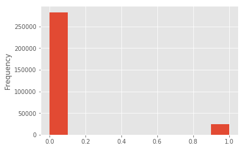

```python
datasets["application_train"]['TARGET'].astype(int).plot.hist();
```

## Correlation with the target column

```python
correlations = datasets["application_train"].corr()['TARGET'].sort_values()
print('Most Positive Correlations:\n', correlations.tail(10))
print('\nMost Negative Correlations:\n', correlations.head(10))
```

```
Most Positive Correlations:
 FLAG_DOCUMENT_3                0.044346
REG_CITY_NOT_LIVE_CITY         0.044395
FLAG_EMP_PHONE                 0.045982
REG_CITY_NOT_WORK_CITY         0.050994
DAYS_ID_PUBLISH                0.051457
DAYS_LAST_PHONE_CHANGE         0.055218
REGION_RATING_CLIENT           0.058899
REGION_RATING_CLIENT_W_CITY    0.060893
DAYS_BIRTH                     0.078239
TARGET                         1.000000
Name: TARGET, dtype: float64

Most Negative Correlations:
 EXT_SOURCE_3                 -0.178919
EXT_SOURCE_2                 -0.160472
EXT_SOURCE_1                 -0.155317
DAYS_EMPLOYED                -0.044932
FLOORSMAX_AVG                -0.044003
FLOORSMAX_MEDI               -0.043768
FLOORSMAX_MODE               -0.043226
AMT_GOODS_PRICE              -0.039645
REGION_POPULATION_RELATIVE   -0.037227
ELEVATORS_AVG                -0.034199
Name: TARGET, dtype: float64
```

Out of the three strongest numerical features, **EXT_SOURCE_1** has more than 50% missing value. So we will try the option of only using the other two.

```python
datasets['application_train'][['EXT_SOURCE_1', 'EXT_SOURCE_2', 'EXT_SOURCE_3']].isnull().sum()/datasets['application_train'].shape[0]
```

```
EXT_SOURCE_1    0.563811
EXT_SOURCE_2    0.002146
EXT_SOURCE_3    0.198253
dtype: float64
```

```python
datasets['application_train'][['EXT_SOURCE_1', 'EXT_SOURCE_2', 'EXT_SOURCE_3']].corr()
```

|  | EXT_SOURCE_1 | EXT_SOURCE_2 | EXT_SOURCE_3 |
| --- | --- | --- | --- |
| EXT_SOURCE_1 | 1.000000 | 0.213982 | 0.186846 |
| EXT_SOURCE_2 | 0.213982 | 1.000000 | 0.109167 |
| EXT_SOURCE_3 | 0.186846 | 0.109167 | 1.000000 |

## Applicants Age

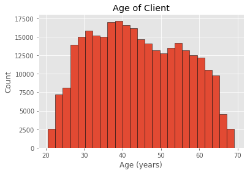

```python
plt.hist(datasets["application_train"]['DAYS_BIRTH'] / -365, edgecolor = 'k', bins = 25)
plt.title('Age of Client'); plt.xlabel('Age (years)'); plt.ylabel('Count');
```

## Applicants occupations

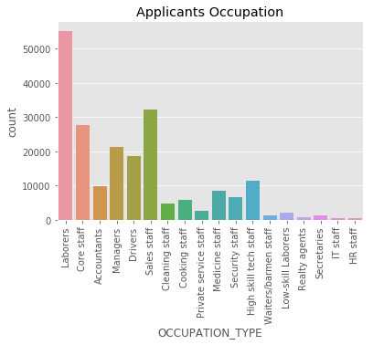

```python
sns.countplot(x='OCCUPATION_TYPE', data=datasets["application_train"]);
plt.title('Applicants Occupation');
plt.xticks(rotation=90);
```

## FLAG_OWN_REALTY

```python
datasets['application_train']['FLAG_OWN_REALTY'].value_counts()
```

```
Y    213312
N     94199
Name: FLAG_OWN_REALTY, dtype: int64
```

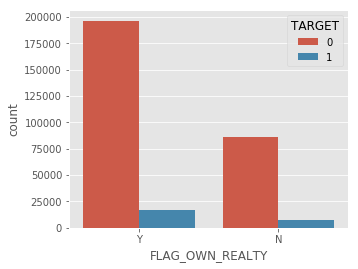

```python
plt.figure(figsize=(5,4))
sns.countplot(datasets['application_train']['FLAG_OWN_REALTY'], hue=datasets['application_train']['TARGET'])
plt.show()
```

Is owning real estate a good predictor of credit risk? First let's look at the default rate among those who own real estate:

```python
datasets['application_train'].loc[(datasets['application_train']['FLAG_OWN_REALTY'] == 'Y') & (datasets['application_train']['TARGET'] == 1),
         ].shape[0]/datasets['application_train'].loc[datasets['application_train']['FLAG_OWN_REALTY'] == 'Y', ].shape[0]
```

```
0.07961577407740775
```

And now among those who do not own real estate:

```python
datasets['application_train'].loc[(datasets['application_train']['FLAG_OWN_REALTY'] == 'N') & (datasets['application_train']['TARGET'] == 1),
         ].shape[0]/datasets['application_train'].loc[datasets['application_train']['FLAG_OWN_REALTY'] == 'N', ].shape[0]
```

```
0.08324929139375152
```

There is a difference, but it's rather subtle.

## REGION_POPULATION_RELATIVE

```python
datasets['application_train'].REGION_POPULATION_RELATIVE.value_counts()
```

```
0.035792    16408
0.046220    13442
0.030755    12163
0.025164    11950
0.026392    11601
0.031329    11321
0.028663    11157
0.019101     8694
0.072508     8412
0.020713     8066
0.018850     7668
0.020246     7178
0.018634     7038
0.022625     6943
0.015221     6824
0.032561     6636
0.024610     6404
0.019689     6172
0.018029     6167
0.018801     6108
0.018209     6052
0.014520     4785
0.016612     4408
0.007020     4105
0.022800     3807
0.010032     3570
0.010006     3563
0.014464     3422
0.004960     3300
0.011703     3252
            ...
0.006008     1796
0.003069     1783
0.008575     1763
0.008474     1740
0.007274     1724
0.007114     1684
0.006305     1672
0.008068     1668
0.008866     1654
0.006671     1653
0.002042     1642
0.003813     1616
0.005084     1482
0.006296     1225
0.005313     1218
0.003818     1212
0.003122     1147
0.006233     1087
0.005002     1068
0.002134     1051
0.004849     1038
0.005144      967
0.002506      944
0.003541      627
0.001276      558
0.001417      467
0.001333      235
0.000533       39
0.000938       28
0.000290        2
Name: REGION_POPULATION_RELATIVE, Length: 81, dtype: int64
```

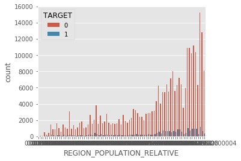

```python
plt.figure(figsize=(5,4))
sns.countplot(datasets['application_train']['REGION_POPULATION_RELATIVE'], hue=datasets['application_train']['TARGET'])
plt.show()
```

We may segment this variable as it clearly seperates the default rate

```python
def target_1_ratio(df):
  return df[df['TARGET'] == 1].shape[0]/df.shape[0]

region_pop_relative = datasets['application_train'].groupby('REGION_POPULATION_RELATIVE').apply(target_1_ratio).to_frame()
region_pop_relative.columns = ['target_1_ratio']
region_pop_relative.reset_index(inplace=True)
region_pop_relative.sort_values(['target_1_ratio'], inplace=True)
region_pop_relative
```

|  | REGION_POPULATION_RELATIVE | target_1_ratio |
| --- | --- | --- |
| 0 | 0.000290 | 0.000000 |
| 80 | 0.072508 | 0.039705 |
| 77 | 0.032561 | 0.045660 |
| 79 | 0.046220 | 0.049323 |
| 41 | 0.009175 | 0.054152 |
| 20 | 0.006008 | 0.057906 |
| 55 | 0.011703 | 0.059348 |
| 46 | 0.010006 | 0.059781 |
| 3 | 0.001276 | 0.060932 |
| 22 | 0.006233 | 0.061638 |
| 11 | 0.003541 | 0.062201 |
| 73 | 0.026392 | 0.062236 |
| 8 | 0.002506 | 0.063559 |
| 64 | 0.018850 | 0.065728 |
| 25 | 0.006629 | 0.066359 |
| 54 | 0.011657 | 0.069156 |
| 78 | 0.035792 | 0.070088 |
| 21 | 0.006207 | 0.070248 |
| 71 | 0.024610 | 0.070269 |
| 26 | 0.006671 | 0.071990 |
| 15 | 0.004960 | 0.072121 |
| 52 | 0.010643 | 0.072377 |
| 38 | 0.008575 | 0.073171 |
| 42 | 0.009334 | 0.073452 |
| 33 | 0.007330 | 0.073826 |
| 28 | 0.007020 | 0.074056 |
| 65 | 0.019101 | 0.074419 |
| 43 | 0.009549 | 0.074700 |
| 49 | 0.010276 | 0.075740 |
| 48 | 0.010147 | 0.075999 |
| ... | ... | ... |
| 36 | 0.008230 | 0.089246 |
| 50 | 0.010500 | 0.089552 |
| 51 | 0.010556 | 0.089573 |
| 62 | 0.018634 | 0.089798 |
| 66 | 0.019689 | 0.091056 |
| 10 | 0.003122 | 0.091543 |
| 30 | 0.007120 | 0.091576 |
| 57 | 0.014520 | 0.092581 |
| 16 | 0.005002 | 0.093633 |
| 45 | 0.009657 | 0.094447 |
| 23 | 0.006296 | 0.097959 |
| 32 | 0.007305 | 0.098661 |
| 37 | 0.008474 | 0.099425 |
| 63 | 0.018801 | 0.100851 |
| 40 | 0.008866 | 0.100967 |
| 6 | 0.002042 | 0.103532 |
| 61 | 0.018209 | 0.103602 |
| 68 | 0.020713 | 0.105009 |
| 14 | 0.004849 | 0.105010 |
| 2 | 0.000938 | 0.107143 |
| 12 | 0.003813 | 0.115718 |
| 67 | 0.020246 | 0.118696 |
| 24 | 0.006305 | 0.119617 |
| 60 | 0.018029 | 0.120156 |
| 4 | 0.001333 | 0.123404 |
| 5 | 0.001417 | 0.128480 |
| 35 | 0.008068 | 0.136091 |
| 7 | 0.002134 | 0.158896 |
| 27 | 0.006852 | 0.161396 |
| 1 | 0.000533 | 0.205128 |

81 rows × 2 columns

It will require some work to find the best 'cut' to bin the **REGION_POPULATION_RELATIVE** feature, so we will just divide the variable into three bins: [0, 0.07), [0.07, 0.1)] and [0.1, 1] and create a new feature in the feature engineering section.

## FLAG_EMP_PHONE

**FLAG_EMP_PHONE** seems to have some separating power, so we will use this feature.

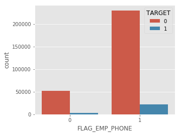

```python
plt.figure(figsize=(5,4))
sns.countplot(datasets['application_train']['FLAG_EMP_PHONE'], hue=datasets['application_train']['TARGET'])
plt.show()
```

```python
datasets['application_train'].groupby('FLAG_EMP_PHONE').apply(target_1_ratio).to_frame()
```

| FLAG_EMP_PHONE | 0 |
| --- | --- |
| 0 | 0.054003 |
| 1 | 0.086600 |

## FLAG_WORK_PHONE

**FLAG_WORK_PHONE** seems to have some separating power. So we will use this feature.

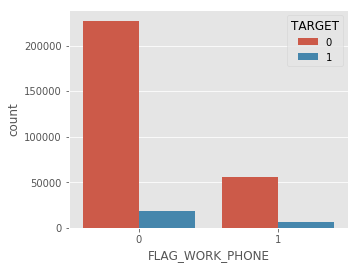

```python
plt.figure(figsize=(5,4))
sns.countplot(datasets['application_train']['FLAG_WORK_PHONE'], hue=datasets['application_train']['TARGET'])
plt.show()
```

```python
datasets['application_train'].groupby('FLAG_WORK_PHONE').apply(target_1_ratio).to_frame()
```

| FLAG_WORK_PHONE | 0 |
| --- | --- |
| 0 | 0.076851 |
| 1 | 0.096301 |

## REGION_RATING_CLIENT

**REGION_RATING_CLIENT** seems to have some separating power, so we will use this feature.

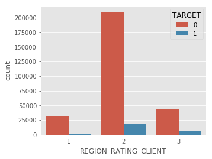

```python
plt.figure(figsize=(5,4))
sns.countplot(datasets['application_train']['REGION_RATING_CLIENT'], hue=datasets['application_train']['TARGET'])
plt.show()
```

```python
datasets['application_train'].groupby('REGION_RATING_CLIENT').apply(target_1_ratio).to_frame()
```

| REGION_RATING_CLIENT | 0 |
| --- | --- |
| 1 | 0.048203 |
| 2 | 0.078891 |
| 3 | 0.111028 |

## HOUR_APPR_PROCESS_START

It seems like applications in the evening (5pm-9pm) have a lower default rate but the volumne in this time frame is relatively small.

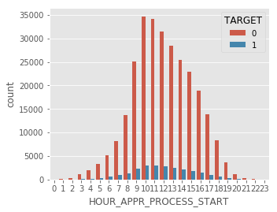

```python
plt.figure(figsize=(5,4))
sns.countplot(datasets['application_train']['HOUR_APPR_PROCESS_START'], hue=datasets['application_train']['TARGET'])
plt.show()
```

```python
datasets['application_train'].groupby('HOUR_APPR_PROCESS_START').apply(target_1_ratio).to_frame()
```

| HOUR_APPR_PROCESS_START | 0 |
| --- | --- |
| 0 | 0.150000 |
| 1 | 0.081395 |
| 2 | 0.098361 |
| 3 | 0.086992 |
| 4 | 0.082775 |
| 5 | 0.105827 |
| 6 | 0.110407 |
| 7 | 0.100427 |
| 8 | 0.090765 |
| 9 | 0.082055 |
| 10 | 0.080218 |
| 11 | 0.080744 |
| 12 | 0.082581 |
| 13 | 0.080267 |
| 14 | 0.079077 |
| 15 | 0.075929 |
| 16 | 0.074614 |
| 17 | 0.064899 |
| 18 | 0.070173 |
| 19 | 0.068607 |
| 20 | 0.070234 |
| 21 | 0.061728 |
| 22 | 0.100000 |
| 23 | 0.121951 |

## ORGANIZATION_TYPE

**ORGANIZATION_TYPE** seems to have some separating power, so we will use this feature.

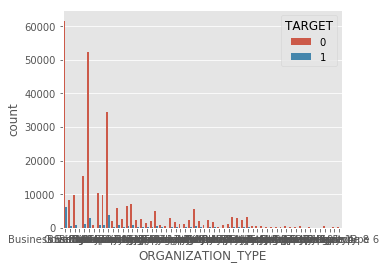

```python
plt.figure(figsize=(5,4))
sns.countplot(datasets['application_train']['ORGANIZATION_TYPE'], hue=datasets['application_train']['TARGET'])
plt.show()
```

```python
datasets['application_train'].groupby('ORGANIZATION_TYPE').apply(target_1_ratio).to_frame()
```

| ORGANIZATION_TYPE | 0 |
| --- | --- |
| Advertising | 0.081585 |
| Agriculture | 0.104727 |
| Bank | 0.051855 |
| Business Entity Type 1 | 0.081384 |
| Business Entity Type 2 | 0.085284 |
| Business Entity Type 3 | 0.092996 |
| Cleaning | 0.111538 |
| Construction | 0.116798 |
| Culture | 0.055409 |
| Electricity | 0.066316 |
| Emergency | 0.071429 |
| Government | 0.069781 |
| Hotel | 0.064182 |
| Housing | 0.079446 |
| Industry: type 1 | 0.110683 |
| Industry: type 10 | 0.064220 |
| Industry: type 11 | 0.086538 |
| Industry: type 12 | 0.037940 |
| Industry: type 13 | 0.134328 |
| Industry: type 2 | 0.072052 |
| Industry: type 3 | 0.106162 |
| Industry: type 4 | 0.101482 |
| Industry: type 5 | 0.068447 |
| Industry: type 6 | 0.071429 |
| Industry: type 7 | 0.080337 |
| Industry: type 8 | 0.125000 |
| Industry: type 9 | 0.066805 |
| Insurance | 0.056951 |
| Kindergarten | 0.070349 |
| Legal Services | 0.078689 |
| Medicine | 0.065845 |
| Military | 0.051253 |
| Mobile | 0.091483 |
| Other | 0.076425 |
| Police | 0.049979 |
| Postal | 0.084376 |
| Realtor | 0.106061 |
| Religion | 0.058824 |
| Restaurant | 0.117062 |
| School | 0.059148 |
| Security | 0.099784 |
| Security Ministries | 0.048632 |
| Self-employed | 0.101739 |
| Services | 0.066032 |
| Telecom | 0.076256 |
| Trade: type 1 | 0.089080 |
| Trade: type 2 | 0.070000 |
| Trade: type 3 | 0.103379 |
| Trade: type 4 | 0.031250 |
| Trade: type 5 | 0.061224 |
| Trade: type 6 | 0.045959 |
| Trade: type 7 | 0.094496 |
| Transport: type 1 | 0.044776 |
| Transport: type 2 | 0.078040 |
| Transport: type 3 | 0.157540 |
| Transport: type 4 | 0.092812 |
| University | 0.048983 |
| XNA | 0.053996 |

## FLAG_DOCUMENT_3

**FLAG_DOCUMENT_3** seems to have some separating power, so we will use this feature.

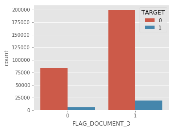

```python
plt.figure(figsize=(5,4))
sns.countplot(datasets['application_train']['FLAG_DOCUMENT_3'], hue=datasets['application_train']['TARGET'])
plt.show()
```

```python
datasets['application_train'].groupby('FLAG_DOCUMENT_3').apply(target_1_ratio).to_frame()
```

| FLAG_DOCUMENT_3 | 0 |
| --- | --- |
| 0 | 0.061825 |
| 1 | 0.088449 |

## FONDKAPREMONT_MODE

**FONDKAPREMONT_MODE** seems to have some separating power, so we will use this feature.

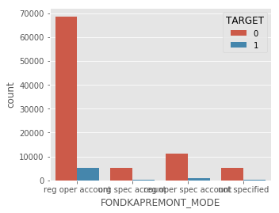

```python
plt.figure(figsize=(5,4))
sns.countplot(datasets['application_train']['FONDKAPREMONT_MODE'], hue=datasets['application_train']['TARGET'])
plt.show()
```

```python
datasets['application_train'].groupby('FONDKAPREMONT_MODE').apply(target_1_ratio).to_frame()
```

| FONDKAPREMONT_MODE | 0 |
| --- | --- |
| not specified | 0.075435 |
| org spec account | 0.058195 |
| reg oper account | 0.069782 |
| reg oper spec account | 0.065563 |

## WALLSMATERIAL_MODE

**WALLSMATERIAL_MODE** seems to have some separating power, so we will use this feature.

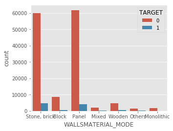

```python
plt.figure(figsize=(5,4))
sns.countplot(datasets['application_train']['WALLSMATERIAL_MODE'], hue=datasets['application_train']['TARGET'])
plt.show()
```

```python
datasets['application_train'].groupby('WALLSMATERIAL_MODE').apply(target_1_ratio).to_frame()
```

| WALLSMATERIAL_MODE | 0 |
| --- | --- |
| Block | 0.070247 |
| Mixed | 0.075348 |
| Monolithic | 0.047218 |
| Others | 0.083077 |
| Panel | 0.063477 |
| Stone, brick | 0.074057 |
| Wooden | 0.096979 |

## Summary of previous_application

- Explore which column to use for indicating the application days within 24 months/365 days

```python
datasets['previous_application'].head()
```

|  | SK_ID_PREV | SK_ID_CURR | NAME_CONTRACT_TYPE | AMT_ANNUITY | AMT_APPLICATION | AMT_CREDIT | AMT_DOWN_PAYMENT | AMT_GOODS_PRICE | WEEKDAY_APPR_PROCESS_START | HOUR_APPR_PROCESS_START | ... | NAME_SELLER_INDUSTRY | CNT_PAYMENT | NAME_YIELD_GROUP | PRODUCT_COMBINATION | DAYS_FIRST_DRAWING | DAYS_FIRST_DUE | DAYS_LAST_DUE_1ST_VERSION | DAYS_LAST_DUE | DAYS_TERMINATION | NFLAG_INSURED_ON_APPROVAL |
| --- | --- | --- | --- | --- | --- | --- | --- | --- | --- | --- | --- | --- | --- | --- | --- | --- | --- | --- | --- | --- | --- |
| 0 | 2030495 | 271877 | Consumer loans | 1730.430 | 17145.0 | 17145.0 | 0.0 | 17145.0 | SATURDAY | 15 | ... | Connectivity | 12.0 | middle | POS mobile with interest | 365243.0 | -42.0 | 300.0 | -42.0 | -37.0 | 0.0 |
| 1 | 2802425 | 108129 | Cash loans | 25188.615 | 607500.0 | 679671.0 | NaN | 607500.0 | THURSDAY | 11 | ... | XNA | 36.0 | low_action | Cash X-Sell: low | 365243.0 | -134.0 | 916.0 | 365243.0 | 365243.0 | 1.0 |
| 2 | 2523466 | 122040 | Cash loans | 15060.735 | 112500.0 | 136444.5 | NaN | 112500.0 | TUESDAY | 11 | ... | XNA | 12.0 | high | Cash X-Sell: high | 365243.0 | -271.0 | 59.0 | 365243.0 | 365243.0 | 1.0 |
| 3 | 2819243 | 176158 | Cash loans | 47041.335 | 450000.0 | 470790.0 | NaN | 450000.0 | MONDAY | 7 | ... | XNA | 12.0 | middle | Cash X-Sell: middle | 365243.0 | -482.0 | -152.0 | -182.0 | -177.0 | 1.0 |
| 4 | 1784265 | 202054 | Cash loans | 31924.395 | 337500.0 | 404055.0 | NaN | 337500.0 | THURSDAY | 9 | ... | XNA | 24.0 | high | Cash Street: high | NaN | NaN | NaN | NaN | NaN | NaN |

5 rows × 37 columns

```python
datasets['previous_application'].shape
```

```
(1670214, 37)
```

- Explore which column to use for indicating the application days within 24 months/365 days

```python
datasets['previous_application'].columns[datasets['previous_application'].columns.str.contains('DAYS')]
```

```
Index(['DAYS_DECISION', 'DAYS_FIRST_DRAWING', 'DAYS_FIRST_DUE',
       'DAYS_LAST_DUE_1ST_VERSION', 'DAYS_LAST_DUE', 'DAYS_TERMINATION'],
      dtype='object')
```

```python
datasets['previous_application'][['DAYS_DECISION', 'DAYS_FIRST_DRAWING', 'DAYS_FIRST_DUE',
       'DAYS_LAST_DUE_1ST_VERSION', 'DAYS_LAST_DUE', 'DAYS_TERMINATION']].head(20)
```

|  | DAYS_DECISION | DAYS_FIRST_DRAWING | DAYS_FIRST_DUE | DAYS_LAST_DUE_1ST_VERSION | DAYS_LAST_DUE | DAYS_TERMINATION |
| --- | --- | --- | --- | --- | --- | --- |
| 0 | -73 | 365243.0 | -42.0 | 300.0 | -42.0 | -37.0 |
| 1 | -164 | 365243.0 | -134.0 | 916.0 | 365243.0 | 365243.0 |
| 2 | -301 | 365243.0 | -271.0 | 59.0 | 365243.0 | 365243.0 |
| 3 | -512 | 365243.0 | -482.0 | -152.0 | -182.0 | -177.0 |
| 4 | -781 | NaN | NaN | NaN | NaN | NaN |
| 5 | -684 | 365243.0 | -654.0 | -144.0 | -144.0 | -137.0 |
| 6 | -14 | NaN | NaN | NaN | NaN | NaN |
| 7 | -21 | NaN | NaN | NaN | NaN | NaN |
| 8 | -386 | NaN | NaN | NaN | NaN | NaN |
| 9 | -57 | NaN | NaN | NaN | NaN | NaN |
| 10 | -735 | 365243.0 | -705.0 | 885.0 | -345.0 | -334.0 |
| 11 | -815 | 365243.0 | -785.0 | 85.0 | -725.0 | -721.0 |
| 12 | -860 | 365243.0 | -830.0 | -140.0 | -200.0 | -197.0 |
| 13 | -408 | 365243.0 | -378.0 | -168.0 | -168.0 | -163.0 |
| 14 | -726 | 365243.0 | -693.0 | -633.0 | -633.0 | -627.0 |
| 15 | -699 | 365243.0 | -668.0 | -518.0 | -518.0 | -512.0 |
| 16 | -1473 | 365243.0 | -1440.0 | -1230.0 | -1230.0 | -1226.0 |
| 17 | -336 | -277.0 | -257.0 | 365243.0 | 365243.0 | 365243.0 |
| 18 | -700 | NaN | NaN | NaN | NaN | NaN |
| 19 | -584 | NaN | NaN | NaN | NaN | NaN |

Looks like we will have to choose *DAYS_DECISION*

```python
datasets['previous_application'][['DAYS_DECISION', 'DAYS_FIRST_DRAWING', 'DAYS_FIRST_DUE',
       'DAYS_LAST_DUE_1ST_VERSION', 'DAYS_LAST_DUE', 'DAYS_TERMINATION']].isnull().sum()/datasets['previous_application'].shape[0]
```

```
DAYS_DECISION                0.000000
DAYS_FIRST_DRAWING           0.402981
DAYS_FIRST_DUE               0.402981
DAYS_LAST_DUE_1ST_VERSION    0.402981
DAYS_LAST_DUE                0.402981
DAYS_TERMINATION             0.402981
dtype: float64
```

```python
no_app_customer = datasets['previous_application'].loc[(datasets['previous_application'].DAYS_DECISION >= -365) &
           (datasets['previous_application'].NAME_CONTRACT_STATUS != 'Canceled'), ].groupby('SK_ID_CURR').SK_ID_PREV.count().sort_values(ascending=False) # only select the applications in the past 12 months
no_app_customer = no_app_customer.to_frame()
no_app_customer.reset_index(inplace=True)
no_app_customer.rename(columns={'SK_ID_PREV':'no_prev_appl'}, inplace=True)
no_app_customer.head()
```

|  | SK_ID_CURR | no_prev_appl |
| --- | --- | --- |
| 0 | 133023 | 54 |
| 1 | 401563 | 50 |
| 2 | 167400 | 36 |
| 3 | 345161 | 33 |
| 4 | 205430 | 33 |

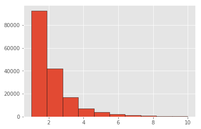

```python
plt.hist(no_app_customer.loc[no_app_customer.no_prev_appl <= 10, 'no_prev_appl'], bins=10, edgecolor='black')

plt.show()
```

Merge *no_app_customer* with train and test data

```python
train = pd.merge(datasets['application_train'], no_app_customer, on='SK_ID_CURR', how='left')
test = pd.merge(datasets['application_test'], no_app_customer, on='SK_ID_CURR', how='left')
```

About 53% current applicants don't have any previous applications.

```python
(train.no_prev_appl.isnull().sum()/train.shape[0], test.no_prev_appl.isnull().sum()/test.shape[0])
```

```
(0.5288656340748786, 0.5370917446249794)
```

now create **no_approved_prev_appl**

```python
no_approved_app_customer = datasets['previous_application'].loc[(datasets['previous_application'].DAYS_DECISION >= -365) &
           (datasets['previous_application'].NAME_CONTRACT_STATUS == 'Approved'), ].groupby('SK_ID_CURR').SK_ID_PREV.count().sort_values(ascending=False) # only select the applications in the past 12 months
no_approved_app_customer = no_approved_app_customer.to_frame()
no_approved_app_customer.reset_index(inplace=True)
no_approved_app_customer.rename(columns={'SK_ID_PREV':'no_approved_prev_appl'}, inplace=True)
no_approved_app_customer.head()
```

|  | SK_ID_CURR | no_approved_prev_appl |
| --- | --- | --- |
| 0 | 271000 | 8 |
| 1 | 237145 | 8 |
| 2 | 407501 | 7 |
| 3 | 304969 | 7 |
| 4 | 357741 | 7 |

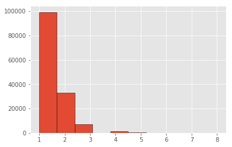

```python
plt.hist(no_approved_app_customer.no_approved_prev_appl, bins=10, edgecolor='black')

plt.show()
```

Merge *no_approved_app_customer* with train and test data

```python
train = pd.merge(train, no_approved_app_customer, on='SK_ID_CURR', how='left')
test = pd.merge(test, no_approved_app_customer, on='SK_ID_CURR', how='left')
```

About 60% percent current customers don't have any previous application info.

```python
train.no_approved_prev_appl.isnull().sum()/train.shape[0]
```

```
0.6023426804244401
```

```python
test.no_approved_prev_appl.isnull().sum()/test.shape[0]
```

```
0.618373543410471
```

fill NA for the 2 newly created features

```python
train[['no_prev_appl']] = train[['no_prev_appl']].fillna(value=0)
test[['no_prev_appl']] = test[['no_prev_appl']].fillna(value=0)
train[['no_approved_prev_appl']] = train[['no_approved_prev_appl']].fillna(0)
test[['no_approved_prev_appl']] = test[['no_approved_prev_appl']].fillna(0)
```

distribution of the two newly created features

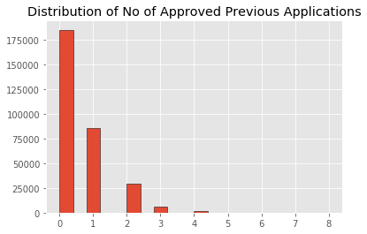

```python
plt.hist(train.no_approved_prev_appl, bins=20, edgecolor='black')
plt.title('Distribution of No of Approved Previous Applications')

plt.show()
```

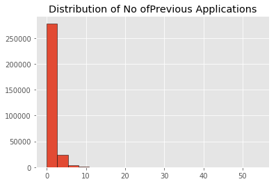

```python
plt.hist(train.no_prev_appl, bins=20, edgecolor='black')
plt.title('Distribution of No ofPrevious Applications')

plt.show()
```

One example of a customer having multiple previous applications

```python
datasets['previous_application'].loc[datasets['previous_application'].SK_ID_CURR == 133023, ['SK_ID_CURR', 'DAYS_DECISION', 'NAME_CONTRACT_STATUS',
                                                                     'AMT_APPLICATION', 'AMT_CREDIT','CODE_REJECT_REASON']].head(20)
```

|  | SK_ID_CURR | DAYS_DECISION | NAME_CONTRACT_STATUS | AMT_APPLICATION | AMT_CREDIT | CODE_REJECT_REASON |
| --- | --- | --- | --- | --- | --- | --- |
| 22889 | 133023 | -369 | Refused | 0.0 | 0.0 | HC |
| 26916 | 133023 | -412 | Approved | 42030.0 | 39325.5 | XAP |
| 46145 | 133023 | -287 | Refused | 0.0 | 0.0 | HC |
| 127831 | 133023 | -300 | Refused | 0.0 | 0.0 | HC |
| 127832 | 133023 | -356 | Refused | 0.0 | 0.0 | HC |
| 139251 | 133023 | -296 | Refused | 0.0 | 0.0 | HC |
| 139252 | 133023 | -271 | Refused | 0.0 | 0.0 | HC |
| 274869 | 133023 | -665 | Approved | 15237.0 | 15160.5 | XAP |
| 326508 | 133023 | -338 | Refused | 0.0 | 0.0 | HC |
| 332839 | 133023 | -295 | Refused | 0.0 | 0.0 | HC |
| 332840 | 133023 | -284 | Refused | 0.0 | 0.0 | HC |
| 362763 | 133023 | -369 | Refused | 0.0 | 0.0 | HC |
| 362764 | 133023 | -352 | Refused | 0.0 | 0.0 | HC |
| 380991 | 133023 | -315 | Refused | 0.0 | 0.0 | HC |
| 417386 | 133023 | -343 | Refused | 0.0 | 0.0 | HC |
| 417387 | 133023 | -342 | Refused | 0.0 | 0.0 | HC |
| 500034 | 133023 | -307 | Refused | 0.0 | 0.0 | HC |
| 500035 | 133023 | -330 | Refused | 0.0 | 0.0 | HC |
| 518112 | 133023 | -355 | Refused | 0.0 | 0.0 | HC |
| 529842 | 133023 | -302 | Refused | 0.0 | 0.0 | HC |

## Summary of bureau.csv

```python
datasets['bureau'].head()
```

|  | SK_ID_CURR | SK_ID_BUREAU | CREDIT_ACTIVE | CREDIT_CURRENCY | DAYS_CREDIT | CREDIT_DAY_OVERDUE | DAYS_CREDIT_ENDDATE | DAYS_ENDDATE_FACT | AMT_CREDIT_MAX_OVERDUE | CNT_CREDIT_PROLONG | AMT_CREDIT_SUM | AMT_CREDIT_SUM_DEBT | AMT_CREDIT_SUM_LIMIT | AMT_CREDIT_SUM_OVERDUE | CREDIT_TYPE | DAYS_CREDIT_UPDATE | AMT_ANNUITY |
| --- | --- | --- | --- | --- | --- | --- | --- | --- | --- | --- | --- | --- | --- | --- | --- | --- | --- |
| 0 | 215354 | 5714462 | Closed | currency 1 | -497 | 0 | -153.0 | -153.0 | NaN | 0 | 91323.0 | 0.0 | NaN | 0.0 | Consumer credit | -131 | NaN |
| 1 | 215354 | 5714463 | Active | currency 1 | -208 | 0 | 1075.0 | NaN | NaN | 0 | 225000.0 | 171342.0 | NaN | 0.0 | Credit card | -20 | NaN |
| 2 | 215354 | 5714464 | Active | currency 1 | -203 | 0 | 528.0 | NaN | NaN | 0 | 464323.5 | NaN | NaN | 0.0 | Consumer credit | -16 | NaN |
| 3 | 215354 | 5714465 | Active | currency 1 | -203 | 0 | NaN | NaN | NaN | 0 | 90000.0 | NaN | NaN | 0.0 | Credit card | -16 | NaN |
| 4 | 215354 | 5714466 | Active | currency 1 | -629 | 0 | 1197.0 | NaN | 77674.5 | 0 | 2700000.0 | NaN | NaN | 0.0 | Consumer credit | -21 | NaN |

```python
datasets['bureau'].shape
```

```
(1716428, 17)
```

Vast majority (99.75%) of customers didn't have any loans that are overdued, so number of times of 30 days over due is not very useful here.

```python
datasets['bureau'].loc[datasets['bureau'].CREDIT_DAY_OVERDUE == 0, ].shape[0]/datasets['bureau'].shape[0]
```

```
0.997543153572419
```

```python
datasets['bureau'].loc[(datasets['bureau'].AMT_CREDIT_MAX_OVERDUE.notnull()) & (datasets['bureau'].DAYS_CREDIT_UPDATE >= -365), ].shape[0]/datasets['bureau'].shape[0]
```

```
0.16036210082799862
```

to create no_active_loans, total_creditLimit and ave_creditLimit

```python
datasets['bureau'].CREDIT_ACTIVE.value_counts()
```

```
Closed      1079273
Active       630607
Sold           6527
Bad debt         21
Name: CREDIT_ACTIVE, dtype: int64
```

Most loans use currency 1 so we will use this currency for credit limit calculation.

```python
datasets['bureau'].CREDIT_CURRENCY.value_counts()
```

```
currency 1    1715020
currency 2       1224
currency 3        174
currency 4         10
Name: CREDIT_CURRENCY, dtype: int64
```

calculate the total credit limit per customer

```python
bureau_info = datasets['bureau'][(datasets['bureau'].CREDIT_ACTIVE == 'Active') & (datasets['bureau'].CREDIT_CURRENCY == 'currency 1')
                                ].groupby('SK_ID_CURR').AMT_CREDIT_SUM.sum()
bureau_info = bureau_info.to_frame()
bureau_info.reset_index(inplace=True)
bureau_info.head()
```

|  | SK_ID_CURR | AMT_CREDIT_SUM |
| --- | --- | --- |
| 0 | 100001 | 884025.000 |
| 1 | 100002 | 481988.565 |
| 2 | 100003 | 810000.000 |
| 3 | 100005 | 598626.000 |
| 4 | 100008 | 267606.000 |

```python
bureau_info.shape
```

```
(251792, 2)
```

calculate the total no of loans per customer

```python
bureau_info_no_loans = datasets['bureau'][(datasets['bureau'].CREDIT_ACTIVE == 'Active') & (datasets['bureau'].CREDIT_CURRENCY == 'currency 1')
                                ].groupby('SK_ID_CURR').SK_ID_BUREAU.count()
bureau_info_no_loans = bureau_info_no_loans.to_frame()
bureau_info_no_loans.reset_index(inplace=True)
bureau_info_no_loans.head()
```

|  | SK_ID_CURR | SK_ID_BUREAU |
| --- | --- | --- |
| 0 | 100001 | 3 |
| 1 | 100002 | 2 |
| 2 | 100003 | 1 |
| 3 | 100005 | 2 |
| 4 | 100008 | 1 |

```python
bureau_info_no_loans.shape
```

```
(251792, 2)
```

merge the two data sets

```python
bureau_info = pd.merge(bureau_info, bureau_info_no_loans, how='outer', on='SK_ID_CURR')
bureau_info.rename(columns={'AMT_CREDIT_SUM':'total_creditLimit', 'SK_ID_BUREAU':'no_of_loans'}, inplace=True)
bureau_info['ave_creditLimit'] = bureau_info.eval('total_creditLimit/no_of_loans')
bureau_info.head()
```

|  | SK_ID_CURR | total_creditLimit | no_of_loans | ave_creditLimit |
| --- | --- | --- | --- | --- |
| 0 | 100001 | 884025.000 | 3 | 294675.0000 |
| 1 | 100002 | 481988.565 | 2 | 240994.2825 |
| 2 | 100003 | 810000.000 | 1 | 810000.0000 |
| 3 | 100005 | 598626.000 | 2 | 299313.0000 |
| 4 | 100008 | 267606.000 | 1 | 267606.0000 |

Merge this dataset with the train and test data set later.

```python
train = pd.merge(train, bureau_info, on='SK_ID_CURR', how='left')
test = pd.merge(test, bureau_info, on='SK_ID_CURR', how='left')
```

There is about 29% missing data for the 3 newly created features.

```python
(train.total_creditLimit.isnull().sum()/train.shape[0], test.total_creditLimit.isnull().sum()/test.shape[0])
```

```
(0.2939211930630124, 0.288835548990645)
```

We fill NA with 0.

```python
train[['total_creditLimit', 'no_of_loans', 'ave_creditLimit']] = train[['total_creditLimit', 'no_of_loans', 'ave_creditLimit']].fillna(0)
train[['total_creditLimit', 'no_of_loans', 'ave_creditLimit']].head()
```

|  | total_creditLimit | no_of_loans | ave_creditLimit |
| --- | --- | --- | --- |
| 0 | 481988.565 | 2.0 | 240994.2825 |
| 1 | 810000.000 | 1.0 | 810000.0000 |
| 2 | 0.000 | 0.0 | 0.0000 |
| 3 | 0.000 | 0.0 | 0.0000 |
| 4 | 0.000 | 0.0 | 0.0000 |

```python
test[['total_creditLimit', 'no_of_loans', 'ave_creditLimit']] = test[['total_creditLimit', 'no_of_loans', 'ave_creditLimit']].fillna(0)
test[['total_creditLimit', 'no_of_loans', 'ave_creditLimit']].head()
```

|  | total_creditLimit | no_of_loans | ave_creditLimit |
| --- | --- | --- | --- |
| 0 | 884025.00 | 3.0 | 294675.000 |
| 1 | 598626.00 | 2.0 | 299313.000 |
| 2 | 0.00 | 0.0 | 0.000 |
| 3 | 864721.08 | 5.0 | 172944.216 |
| 4 | 0.00 | 0.0 | 0.000 |

## credit_card_balance.csv

```python
datasets['credit_card_balance'].head()
```

|  | SK_ID_PREV | SK_ID_CURR | MONTHS_BALANCE | AMT_BALANCE | AMT_CREDIT_LIMIT_ACTUAL | AMT_DRAWINGS_ATM_CURRENT | AMT_DRAWINGS_CURRENT | AMT_DRAWINGS_OTHER_CURRENT | AMT_DRAWINGS_POS_CURRENT | AMT_INST_MIN_REGULARITY | ... | AMT_RECIVABLE | AMT_TOTAL_RECEIVABLE | CNT_DRAWINGS_ATM_CURRENT | CNT_DRAWINGS_CURRENT | CNT_DRAWINGS_OTHER_CURRENT | CNT_DRAWINGS_POS_CURRENT | CNT_INSTALMENT_MATURE_CUM | NAME_CONTRACT_STATUS | SK_DPD | SK_DPD_DEF |
| --- | --- | --- | --- | --- | --- | --- | --- | --- | --- | --- | --- | --- | --- | --- | --- | --- | --- | --- | --- | --- | --- |
| 0 | 2562384 | 378907 | -6 | 56.970 | 135000 | 0.0 | 877.5 | 0.0 | 877.5 | 1700.325 | ... | 0.000 | 0.000 | 0.0 | 1 | 0.0 | 1.0 | 35.0 | Active | 0 | 0 |
| 1 | 2582071 | 363914 | -1 | 63975.555 | 45000 | 2250.0 | 2250.0 | 0.0 | 0.0 | 2250.000 | ... | 64875.555 | 64875.555 | 1.0 | 1 | 0.0 | 0.0 | 69.0 | Active | 0 | 0 |
| 2 | 1740877 | 371185 | -7 | 31815.225 | 450000 | 0.0 | 0.0 | 0.0 | 0.0 | 2250.000 | ... | 31460.085 | 31460.085 | 0.0 | 0 | 0.0 | 0.0 | 30.0 | Active | 0 | 0 |
| 3 | 1389973 | 337855 | -4 | 236572.110 | 225000 | 2250.0 | 2250.0 | 0.0 | 0.0 | 11795.760 | ... | 233048.970 | 233048.970 | 1.0 | 1 | 0.0 | 0.0 | 10.0 | Active | 0 | 0 |
| 4 | 1891521 | 126868 | -1 | 453919.455 | 450000 | 0.0 | 11547.0 | 0.0 | 11547.0 | 22924.890 | ... | 453919.455 | 453919.455 | 0.0 | 1 | 0.0 | 1.0 | 101.0 | Active | 0 | 0 |

5 rows × 23 columns

we can use *AMT_BALANCE*, *AMT_CREDIT_LIMIT_ACTUAL* and *AMT_PAYMENT_TOTAL_CURRENT* to calculate the total credit limit, utilization and payment ratio.

```python
datasets['credit_card_balance'].isnull().sum()/datasets['credit_card_balance'].shape[0]
```

```
SK_ID_PREV                    0.000000
SK_ID_CURR                    0.000000
MONTHS_BALANCE                0.000000
AMT_BALANCE                   0.000000
AMT_CREDIT_LIMIT_ACTUAL       0.000000
AMT_DRAWINGS_ATM_CURRENT      0.195249
AMT_DRAWINGS_CURRENT          0.000000
AMT_DRAWINGS_OTHER_CURRENT    0.195249
AMT_DRAWINGS_POS_CURRENT      0.195249
AMT_INST_MIN_REGULARITY       0.079482
AMT_PAYMENT_CURRENT           0.199981
AMT_PAYMENT_TOTAL_CURRENT     0.000000
AMT_RECEIVABLE_PRINCIPAL      0.000000
AMT_RECIVABLE                 0.000000
AMT_TOTAL_RECEIVABLE          0.000000
CNT_DRAWINGS_ATM_CURRENT      0.195249
CNT_DRAWINGS_CURRENT          0.000000
CNT_DRAWINGS_OTHER_CURRENT    0.195249
CNT_DRAWINGS_POS_CURRENT      0.195249
CNT_INSTALMENT_MATURE_CUM     0.079482
NAME_CONTRACT_STATUS          0.000000
SK_DPD                        0.000000
SK_DPD_DEF                    0.000000
dtype: float64
```

```python
datasets['credit_card_balance'].NAME_CONTRACT_STATUS.value_counts()
```

```
Active           3698436
Completed         128918
Signed             11058
Demand              1365
Sent proposal        513
Refused               17
Approved               5
Name: NAME_CONTRACT_STATUS, dtype: int64
```

some accounts have 0 credit limit, so we have to exclude them.

```python
creditCard_info = datasets['credit_card_balance'][(datasets['credit_card_balance'].MONTHS_BALANCE >= -24) &
                                                  (datasets['credit_card_balance'].NAME_CONTRACT_STATUS =='Active') &
                                                 (datasets['credit_card_balance'].AMT_CREDIT_LIMIT_ACTUAL > 0)].groupby('SK_ID_CURR')['AMT_BALANCE',
                                                                                 'AMT_CREDIT_LIMIT_ACTUAL', 'AMT_PAYMENT_TOTAL_CURRENT'].sum()
```

some accounts have 0 credit limit, which is strange...

```python
creditCard_info.reset_index(inplace=True)
```

```python
creditCard_info.head()
```

|  | SK_ID_CURR | AMT_BALANCE | AMT_CREDIT_LIMIT_ACTUAL | AMT_PAYMENT_TOTAL_CURRENT |
| --- | --- | --- | --- | --- |
| 0 | 100006 | 0.0 | 1620000 | 0.0 |
| 1 | 100011 | 0.0 | 2970000 | 0.0 |
| 2 | 100013 | 0.0 | 1305000 | 0.0 |
| 3 | 100021 | 0.0 | 4725000 | 0.0 |
| 4 | 100023 | 0.0 | 1080000 | 0.0 |

calculate **utilization_CC** and **payment_ratio_CC**

```python
creditCard_info['utilization_CC'] = creditCard_info.eval('AMT_BALANCE/AMT_CREDIT_LIMIT_ACTUAL')
creditCard_info['payment_ratio_CC'] = creditCard_info.eval('AMT_PAYMENT_TOTAL_CURRENT/AMT_BALANCE')
```

set **payment_ratio_CC** to 1 if it is NaN (when there is no unpaid balance).

```python
creditCard_info.loc[creditCard_info.payment_ratio_CC.isnull(), 'payment_ratio_CC'] = 1
#creditCard_info['payment_ratio_CC'] = creditCard_info['payment_ratio_CC'].fillna(1)
```

```python
creditCard_info.isnull().sum()
```

```
SK_ID_CURR                   0
AMT_BALANCE                  0
AMT_CREDIT_LIMIT_ACTUAL      0
AMT_PAYMENT_TOTAL_CURRENT    0
utilization_CC               0
payment_ratio_CC             0
dtype: int64
```

drop un-necessory columns

```python
creditCard_info.drop(columns=['AMT_BALANCE', 'AMT_PAYMENT_TOTAL_CURRENT'], inplace=True)
creditCard_info.rename(columns={'AMT_CREDIT_LIMIT_ACTUAL':'total_creditLimit_CC'}, inplace=True)
```

```python
#ceiling the payment_ratio_CC to 1
creditCard_info.loc[creditCard_info.payment_ratio_CC > 1, 'payment_ratio_CC'] = 1
```

```python
creditCard_info.payment_ratio_CC.min()
```

```
0.0
```

```python
train = pd.merge(train, creditCard_info, on='SK_ID_CURR', how='left')
test = pd.merge(test, creditCard_info, on='SK_ID_CURR', how='left')
```

There are about 75% missing data - 75% customers don't have credit card with Home Credit Group.

```python
train.total_creditLimit_CC.isnull().sum()/train.shape[0]
```

```
0.7482561599422459
```

We need to decide the strategy for imputing the missing data - 0 doesn't seem to be a good choice here. We will leave this problem for hyperparameter tuning in grid serach step.

## Summary of install_payment.csv

```python
datasets['installments_payments'].head()
```

|  | SK_ID_PREV | SK_ID_CURR | NUM_INSTALMENT_VERSION | NUM_INSTALMENT_NUMBER | DAYS_INSTALMENT | DAYS_ENTRY_PAYMENT | AMT_INSTALMENT | AMT_PAYMENT |
| --- | --- | --- | --- | --- | --- | --- | --- | --- |
| 0 | 1054186 | 161674 | 1.0 | 6 | -1180.0 | -1187.0 | 6948.360 | 6948.360 |
| 1 | 1330831 | 151639 | 0.0 | 34 | -2156.0 | -2156.0 | 1716.525 | 1716.525 |
| 2 | 2085231 | 193053 | 2.0 | 1 | -63.0 | -63.0 | 25425.000 | 25425.000 |
| 3 | 2452527 | 199697 | 1.0 | 3 | -2418.0 | -2426.0 | 24350.130 | 24350.130 |
| 4 | 2714724 | 167756 | 1.0 | 2 | -1383.0 | -1366.0 | 2165.040 | 2160.585 |

```python
datasets['installments_payments']['days_past_due'] = datasets['installments_payments'].eval('DAYS_ENTRY_PAYMENT - DAYS_INSTALMENT')
datasets['installments_payments']['past_due_times'] = (datasets['installments_payments']['days_past_due'] > 0 ).astype(int)
```

```python
past_due_info = datasets['installments_payments'][datasets['installments_payments']['DAYS_INSTALMENT'] >= -730].groupby('SK_ID_CURR')['past_due_times'].sum()
past_due_info = past_due_info.to_frame()
past_due_info.reset_index(inplace=True)
```

About 36% customers had past due events in the past 2 years.

```python
past_due_info[past_due_info['past_due_times'] > 0].shape[0]/past_due_info.shape[0]
```

```
0.3634009215962537
```

```python
past_due_info.head()
```

|  | SK_ID_CURR | past_due_times |
| --- | --- | --- |
| 0 | 100002 | 0 |
| 1 | 100003 | 0 |
| 2 | 100004 | 0 |
| 3 | 100005 | 1 |
| 4 | 100006 | 0 |

merge with the main data sets

```python
train = pd.merge(train, past_due_info, on='SK_ID_CURR', how='left')
test = pd.merge(test, past_due_info, on='SK_ID_CURR', how='left')
```

About 18% missing data here. We will leave the imputation to gridsearch step.

```python
train.past_due_times.isnull().sum()/train.shape[0]
```

```
0.18039354689750936
```

# Feature Engineering

## Features created in the EDA step

```python
train.columns[-9:]
```

```
Index(['no_prev_appl', 'no_approved_prev_appl', 'total_creditLimit',
       'no_of_loans', 'ave_creditLimit', 'total_creditLimit_CC',
       'utilization_CC', 'payment_ratio_CC', 'past_due_times'],
      dtype='object')
```

Based on domain knowledge, we have created the following new features from the files other than the two application data sets:

Check the corelation between the newly created features and the target variable:

- utilization_CC is a very strong feature;
- past_due_times, no_of_loans and no_prev_appl may also help.

```python
train[['TARGET', 'no_prev_appl', 'no_approved_prev_appl', 'total_creditLimit',
       'no_of_loans', 'ave_creditLimit', 'total_creditLimit_CC',
       'utilization_CC', 'payment_ratio_CC', 'past_due_times']].corr()['TARGET'].sort_values()
```

```
payment_ratio_CC        -0.126491
ave_creditLimit         -0.022718
total_creditLimit_CC    -0.019050
total_creditLimit       -0.005492
no_approved_prev_appl    0.006952
no_of_loans              0.043632
no_prev_appl             0.047260
past_due_times           0.066971
utilization_CC           0.149147
TARGET                   1.000000
Name: TARGET, dtype: float64
```

## Develop More New Features manually

develop some more new features:

- credit_income_ratio
- annuity_income_ratio

```python
train['credit_income_ratio'] = train.eval('AMT_CREDIT/AMT_INCOME_TOTAL') #credit to income ratio
train['annuity_income_ratio'] = train.eval('AMT_ANNUITY/AMT_INCOME_TOTAL') #annuity to income ratio

test['credit_income_ratio'] = test.eval('AMT_CREDIT/AMT_INCOME_TOTAL') #credit to income ratio
test['annuity_income_ratio'] = test.eval('AMT_ANNUITY/AMT_INCOME_TOTAL') #annuity to income ratio

# some more new features

train['income_population_percen'] = (
    train.AMT_INCOME_TOTAL / train.REGION_POPULATION_RELATIVE).replace(np.inf, 0)
train['credit_population_percen'] = (
    train.AMT_CREDIT / train.REGION_POPULATION_RELATIVE).replace(np.inf, 0)
train['annuity_population_percen'] = (
    train.AMT_ANNUITY / train.REGION_POPULATION_RELATIVE).replace(np.inf, 0)
train['fam_member_population_percen'] = (
    train.CNT_FAM_MEMBERS / train.REGION_POPULATION_RELATIVE).replace(np.inf, 0)
train['child_population_percen'] = (
    train.CNT_CHILDREN / train.REGION_POPULATION_RELATIVE).replace(np.inf, 0)
train['goods_prices_population_percen'] = (
    train.AMT_GOODS_PRICE / train.REGION_POPULATION_RELATIVE).replace(np.inf, 0)
train['car_age_population_percen'] = (
    train.OWN_CAR_AGE / train.REGION_POPULATION_RELATIVE).replace(np.inf, 0)

test['income_population_percen'] = (
    test.AMT_INCOME_TOTAL / test.REGION_POPULATION_RELATIVE).replace(np.inf, 0)
test['credit_population_percen'] = (
    test.AMT_CREDIT / test.REGION_POPULATION_RELATIVE).replace(np.inf, 0)
test['annuity_population_percen'] = (
    test.AMT_ANNUITY / test.REGION_POPULATION_RELATIVE).replace(np.inf, 0)
test['fam_member_population_percen'] = (
    test.CNT_FAM_MEMBERS / test.REGION_POPULATION_RELATIVE).replace(np.inf, 0)
test['child_population_percen'] = (
    test.CNT_CHILDREN / test.REGION_POPULATION_RELATIVE).replace(np.inf, 0)
test['goods_prices_population_percen'] = (
    test.AMT_GOODS_PRICE / test.REGION_POPULATION_RELATIVE).replace(np.inf, 0)
test['car_age_population_percen'] = (
    test.OWN_CAR_AGE / test.REGION_POPULATION_RELATIVE).replace(np.inf, 0)



# from Nishad and Naimesh
train[train.columns[train.columns.str.contains('DAYS')]] = abs(
    train[train.columns[train.columns.str.contains('DAYS')]]).replace(365243, np.nan)/365
train['income_credit_percen'] = (
    train.AMT_INCOME_TOTAL / train.AMT_CREDIT).replace(np.inf, 0)
train['fam_member_income'] = (
    train.AMT_INCOME_TOTAL / train.CNT_FAM_MEMBERS).replace(np.inf, 0)
train['ann_incom_percen'] = (
    train.AMT_ANNUITY / train.AMT_INCOME_TOTAL).replace(np.inf, 0)
train['new_employ_to_birth_ratio'] = (
    train.DAYS_EMPLOYED / train.DAYS_BIRTH).replace(np.inf, 0)
train['new_credit_to_annuity'] = (
    train['AMT_CREDIT'] / train['AMT_ANNUITY']).replace(np.inf, 0)
train['new_credit_to_goods_ratio'] = (
    train['AMT_CREDIT'] / train['AMT_GOODS_PRICE']).replace(np.inf, 0)
train['new_car_to_birth_ratio'] = (
    train['OWN_CAR_AGE'] / train['DAYS_BIRTH']).replace(np.inf, 0)
train['new_car_to_emp_ratio'] = (
    train['OWN_CAR_AGE'] / train['DAYS_EMPLOYED']).replace(np.inf, 0)
train['new_inc_per_child'] = (
    train['AMT_INCOME_TOTAL'] / (1 + train['CNT_CHILDREN'])).replace(np.inf, 0)

test[test.columns[test.columns.str.contains('DAYS')]] = abs(
    test[test.columns[test.columns.str.contains('DAYS')]]).replace(365243, np.nan)/365
test['income_credit_percen'] = (
    test.AMT_INCOME_TOTAL / test.AMT_CREDIT).replace(np.inf, 0)
test['fam_member_income'] = (
    test.AMT_INCOME_TOTAL / test.CNT_FAM_MEMBERS).replace(np.inf, 0)
test['ann_incom_percen'] = (
    test.AMT_ANNUITY / test.AMT_INCOME_TOTAL).replace(np.inf, 0)
test['new_employ_to_birth_ratio'] = (
    test.DAYS_EMPLOYED / test.DAYS_BIRTH).replace(np.inf, 0)
test['new_credit_to_annuity'] = (
    test['AMT_CREDIT'] / test['AMT_ANNUITY']).replace(np.inf, 0)
test['new_credit_to_goods_ratio'] = (
    test['AMT_CREDIT'] / test['AMT_GOODS_PRICE']).replace(np.inf, 0)
test['new_car_to_birth_ratio'] = (
    test['OWN_CAR_AGE'] / test['DAYS_BIRTH']).replace(np.inf, 0)
test['new_car_to_emp_ratio'] = (
    test['OWN_CAR_AGE'] / test['DAYS_EMPLOYED']).replace(np.inf, 0)
test['new_inc_per_child'] = (
    test['AMT_INCOME_TOTAL'] / (1 + test['CNT_CHILDREN'])).replace(np.inf, 0)
```

# Processing pipeline

```python
# Create a class to select numerical or categorical columns
# since Scikit-Learn doesn't handle DataFrames yet
class DataFrameSelector(BaseEstimator, TransformerMixin):
    def __init__(self, attribute_names):
        self.attribute_names = attribute_names
    def fit(self, X, y=None):
        return self
    def transform(self, X):
        return X[self.attribute_names].values
```

```python
# Identify the numeric features we wish to consider.
num_attribs = [
    'AMT_INCOME_TOTAL',  'AMT_CREDIT','DAYS_EMPLOYED','DAYS_BIRTH','EXT_SOURCE_1',
    'EXT_SOURCE_2','EXT_SOURCE_3']

num_pipeline = Pipeline([
        ('selector', DataFrameSelector(num_attribs)),
        ('imputer', SimpleImputer(strategy='mean')),
        ('std_scaler', StandardScaler()),
    ])
# Identify the categorical features we wish to consider.
cat_attribs = ['CODE_GENDER', 'FLAG_OWN_REALTY','FLAG_OWN_CAR','NAME_CONTRACT_TYPE',
               'NAME_EDUCATION_TYPE','OCCUPATION_TYPE','NAME_INCOME_TYPE']
cat_pipeline = Pipeline([
        ('selector', DataFrameSelector(cat_attribs)),
        ('imputer', SimpleImputer(strategy='most_frequent')),
        ('ohe', OneHotEncoder(sparse=False, handle_unknown="ignore"))
    ])

data_prep_pipeline = FeatureUnion(transformer_list=[
        ("num_pipeline", num_pipeline),
        ("cat_pipeline", cat_pipeline),
    ])
```

```python
list(datasets["application_train"].columns)
```

```
['SK_ID_CURR',
 'TARGET',
 'NAME_CONTRACT_TYPE',
 'CODE_GENDER',
 'FLAG_OWN_CAR',
 'FLAG_OWN_REALTY',
 'CNT_CHILDREN',
 'AMT_INCOME_TOTAL',
 'AMT_CREDIT',
 'AMT_ANNUITY',
 'AMT_GOODS_PRICE',
 'NAME_TYPE_SUITE',
 'NAME_INCOME_TYPE',
 'NAME_EDUCATION_TYPE',
 'NAME_FAMILY_STATUS',
 'NAME_HOUSING_TYPE',
 'REGION_POPULATION_RELATIVE',
 'DAYS_BIRTH',
 'DAYS_EMPLOYED',
 'DAYS_REGISTRATION',
 'DAYS_ID_PUBLISH',
 'OWN_CAR_AGE',
 'FLAG_MOBIL',
 'FLAG_EMP_PHONE',
 'FLAG_WORK_PHONE',
 'FLAG_CONT_MOBILE',
 'FLAG_PHONE',
 'FLAG_EMAIL',
 'OCCUPATION_TYPE',
 'CNT_FAM_MEMBERS',
 'REGION_RATING_CLIENT',
 'REGION_RATING_CLIENT_W_CITY',
 'WEEKDAY_APPR_PROCESS_START',
 'HOUR_APPR_PROCESS_START',
 'REG_REGION_NOT_LIVE_REGION',
 'REG_REGION_NOT_WORK_REGION',
 'LIVE_REGION_NOT_WORK_REGION',
 'REG_CITY_NOT_LIVE_CITY',
 'REG_CITY_NOT_WORK_CITY',
 'LIVE_CITY_NOT_WORK_CITY',
```

[output cut: 67 more lines]

```
 'FLAG_DOCUMENT_13',
 'FLAG_DOCUMENT_14',
 'FLAG_DOCUMENT_15',
 'FLAG_DOCUMENT_16',
 'FLAG_DOCUMENT_17',
 'FLAG_DOCUMENT_18',
 'FLAG_DOCUMENT_19',
 'FLAG_DOCUMENT_20',
 'FLAG_DOCUMENT_21',
 'AMT_REQ_CREDIT_BUREAU_HOUR',
 'AMT_REQ_CREDIT_BUREAU_DAY',
 'AMT_REQ_CREDIT_BUREAU_WEEK',
 'AMT_REQ_CREDIT_BUREAU_MON',
 'AMT_REQ_CREDIT_BUREAU_QRT',
 'AMT_REQ_CREDIT_BUREAU_YEAR']
```

```python
# Split the provided training data into training and validationa and test
# The kaggle evaluation test set has no labels
#
from sklearn.model_selection import train_test_split

# just selected a few features for a baseline experiment
selected_features = ['AMT_INCOME_TOTAL',  'AMT_CREDIT','DAYS_EMPLOYED','DAYS_BIRTH','EXT_SOURCE_1',
    'EXT_SOURCE_2','EXT_SOURCE_3','CODE_GENDER', 'FLAG_OWN_REALTY','FLAG_OWN_CAR','NAME_CONTRACT_TYPE',
               'NAME_EDUCATION_TYPE','OCCUPATION_TYPE','NAME_INCOME_TYPE']
X_train= datasets["application_train"][selected_features]
y_train = datasets["application_train"]['TARGET']
X_train, X_valid, y_train, y_valid = train_test_split(X_train, y_train, test_size=0.15, random_state=42)
X_train, X_test, y_train, y_test = train_test_split(X_train, y_train, test_size=0.15, random_state=42)
X_kaggle_test= datasets["application_test"][selected_features]
# y_test = datasets["application_test"]['TARGET']   #why no  TARGET?!! (hint: kaggle competition)
print(f"X train           shape: {X_train.shape}")
print(f"X validation      shape: {X_valid.shape}")
print(f"X test            shape: {X_test.shape}")
print(f"X X_kaggle_test   shape: {X_kaggle_test.shape}")
```

```
X train           shape: (222176, 14)
X validation      shape: (46127, 14)
X test            shape: (39208, 14)
X X_kaggle_test   shape: (48744, 14)
```

# Baseline Model

To get a baseline, we will use some of the features after being preprocessed through the pipeline. The baseline model is a logistic regression model

```python
def pct(x):
    return round(100*x,3)
```

```python
try:
    expLog
except NameError:
    expLog = pd.DataFrame(columns=["exp_name",
                                   "Train Acc",
                                   "Valid Acc",
                                   "Test  Acc",
                                   "Train AUC",
                                   "Valid AUC",
                                   "Test  AUC"
                                  ])
```

```python
%%time
np.random.seed(42)
full_pipeline_with_predictor = Pipeline([
        ("preparation", data_prep_pipeline),
        ("linear", LogisticRegression(n_jobs = -1))
    ])
model = full_pipeline_with_predictor.fit(X_train, y_train)
```

```
Wall time: 10min 5s
```

```python
from sklearn.metrics import accuracy_score

np.round(accuracy_score(y_train, model.predict(X_train)), 3)
```

```
0.92
```

## Evaluation metrics

Submissions are evaluated on [area under the ROC curve](http://en.wikipedia.org/wiki/Receiver_operating_characteristic) between the predicted probability and the observed target.

The SkLearn `roc_auc_score` function computes the area under the receiver operating characteristic (ROC) curve, which is also denoted by AUC or AUROC. By computing the area under the roc curve, the curve information is summarized in one number.

```
from sklearn.metrics import roc_auc_score
>>> y_true = np.array([0, 0, 1, 1])
>>> y_scores = np.array([0.1, 0.4, 0.35, 0.8])
>>> roc_auc_score(y_true, y_scores)
0.75
```

```python
from sklearn.metrics import roc_auc_score
roc_auc_score(y_train, model.predict_proba(X_train)[:, 1])
```

```
0.7359284437419668
```

```python
# baseline_scores = cross_val_score(model, X_train, y_train, scoring = 'roc_auc', cv=30)
```

```python
exp_name = f"Baseline_{len(selected_features)}_features"
expLog.loc[len(expLog)] = [f"{exp_name}"] + list(np.round(
               [accuracy_score(y_train, model.predict(X_train)),
                accuracy_score(y_valid, model.predict(X_valid)),
                accuracy_score(y_test, model.predict(X_test)),
                roc_auc_score(y_train, model.predict_proba(X_train)[:, 1]),
                roc_auc_score(y_valid, model.predict_proba(X_valid)[:, 1]),
                roc_auc_score(y_test, model.predict_proba(X_test)[:, 1])],
    4))
expLog
```

|  | exp_name | Train Acc | Valid Acc | Test Acc | Train AUC | Valid AUC | Test AUC |
| --- | --- | --- | --- | --- | --- | --- | --- |
| 0 | Baseline_14_features | 0.9198 | 0.9192 | 0.9159 | 0.7359 | 0.7361 | 0.7362 |

## Submission File Prep

For each SK_ID_CURR in the test set, you must predict a probability for the TARGET variable. The file should contain a header and have the following format:

```
SK_ID_CURR,TARGET
100001,0.1
100005,0.9
100013,0.2
etc.
```

```python
test_class_scores = model.predict_proba(X_kaggle_test)[:, 1]
```

```python
test_class_scores[0:10]
```

[output not shown]

```python
cv = cv = KFold(n_splits=5, random_state=42, shuffle=False)
logit_scores = cross_val_score(fit_pipeline, app_train_subset, train_labels, cv=cv)
log_reg_pred = fit_pipeline.predict_proba(test)[:, 1]
logit_score_train = logit_scores.mean()
results.loc[0] = ["Baseline", pct(logit_score_train),"Untuned LogisticRegression"]
results
```

[output not shown]

```python
exp_name = f"Baseline_{len(selected_features)}"
```

```python
# Submission dataframe
submit_df = datasets["application_test"][['SK_ID_CURR']]
submit_df['TARGET'] = test_class_scores

submit_df.head()
```

[output not shown]

```python
submit_df.to_csv("submission.csv",index=False)
```

# Benchmark Model

## Set up a pipeline that incorporates feature engineering

```python
from sklearn.feature_selection import SelectKBest
from sklearn.feature_selection import f_classif
from sklearn.preprocessing import PolynomialFeatures
from sklearn.base import BaseEstimator, TransformerMixin
from sklearn.compose import ColumnTransformer
from sklearn.pipeline import Pipeline

# Create a class to select numerical or categorical columns
# since Scikit-Learn doesn't handle DataFrames yet
class DataFrameSelector(BaseEstimator, TransformerMixin):
    def __init__(self, attribute_names):
        self.attribute_names = attribute_names
    def fit(self, X, y=None):
        return self
    def transform(self, X):
        return X[self.attribute_names].values

class Feature_engineering(BaseEstimator, TransformerMixin):
    def __init__(self, features = None): # no *args or **kargs  , features=None
        self.features = features
#         pass
    def fit(self, X, y=None):
        return self  # nothing else to do
    def transform(self, X):
#         df = pd.DataFrame(columns = None)
        df = X.copy()
        df['credit_income_ratio'] = df.eval('AMT_CREDIT/AMT_INCOME_TOTAL') #credit to income ratio
        df['annuity_income_ratio'] = df.eval('AMT_ANNUITY/AMT_INCOME_TOTAL') #annuity to income ratio

        return df
```

```python
# # Identify the numeric features we wish to consider.

num_attribs = ['EXT_SOURCE_1', 'EXT_SOURCE_2','EXT_SOURCE_3', 'no_prev_appl', 'no_approved_prev_appl','utilization_CC',
               'past_due_times', 'OWN_CAR_AGE', 'FLOORSMAX_AVG', 'AMT_GOODS_PRICE', 'REGION_POPULATION_RELATIVE',
               'AMT_INCOME_TOTAL',  'AMT_CREDIT','DAYS_EMPLOYED','credit_income_ratio', 'annuity_income_ratio']


num_pipeline = Pipeline([
        ('selector', DataFrameSelector(num_attribs)),
        ('imputer', SimpleImputer(strategy='mean')),
        ('std_scaler', StandardScaler()),
    ])

# Identify the categorical features we wish to consider.
cat_attribs = ['CODE_GENDER', 'FLAG_OWN_REALTY','FLAG_OWN_CAR','NAME_CONTRACT_TYPE',
               'NAME_EDUCATION_TYPE','OCCUPATION_TYPE','NAME_INCOME_TYPE',
              'FLAG_EMP_PHONE', 'FLAG_WORK_PHONE', 'REGION_RATING_CLIENT', 'REGION_RATING_CLIENT_W_CITY',
              'ORGANIZATION_TYPE', 'FONDKAPREMONT_MODE', 'WALLSMATERIAL_MODE']

cat_pipeline = Pipeline([
        ('selector', DataFrameSelector(cat_attribs)),
        ('imputer', SimpleImputer(strategy='most_frequent')),
        ('ohe', OneHotEncoder(sparse=False, handle_unknown="ignore"))
    ])


# feature_eng = Pipeline([
#     ('feature_eng', Feature_engineering())
# ])


# num_cat_pipeline = ColumnTransformer([
#     ('num_pipeline', num_pipeline, num_attribs),
#     ('cat_pipeline', cat_pipeline, cat_attribs),
# ], remainder = 'drop' )


# data_prep_pipeline = Pipeline([
#     ('feature_eng', feature_eng),
#     ('num_cat_pipe', num_cat_pipeline)
# ])

data_prep_pipeline = FeatureUnion(transformer_list=[
        ("num_pipeline", num_pipeline),
        ("cat_pipeline", cat_pipeline),
    ])
```

```python
# Split the provided training data into training and validationa and test
# The kaggle evaluation test set has no labels
#
from sklearn.model_selection import train_test_split

# just selected a few features for a baseline experiment
selected_features = num_attribs + cat_attribs
X_train= train[selected_features]
y_train = train['TARGET']
X_train, X_valid, y_train, y_valid = train_test_split(X_train, y_train, test_size=0.15, random_state=42)
X_train, X_test, y_train, y_test = train_test_split(X_train, y_train, test_size=0.15, random_state=42)
X_kaggle_test= test[selected_features]
# y_test = datasets["application_test"]['TARGET']   #why no  TARGET?!! (hint: kaggle competition)
print(f"X train           shape: {X_train.shape}")
print(f"X validation      shape: {X_valid.shape}")
print(f"X test            shape: {X_test.shape}")
print(f"X X_kaggle_test   shape: {X_kaggle_test.shape}")
```

## Logistic Regression Model

```python
try:
    expLog
except NameError:
    expLog = pd.DataFrame(columns=["exp_name",
                                   "Train Acc",
                                   "Valid Acc",
                                   "Test  Acc",
                                   "Train AUC",
                                   "Valid AUC",
                                   "Test  AUC"
                                  ])
```

```python
%%time
np.random.seed(42)

full_pipeline_with_predictor = Pipeline([
("preparation", data_prep_pipeline),
("feature_selector", SelectKBest(score_func=f_classif, k=25)),
("polynomial", PolynomialFeatures(degree=2)),
("classifier", LogisticRegression(random_state=42))
])

model_benchmark = full_pipeline_with_predictor.fit(X_train, y_train)
```

```python
from sklearn.metrics import accuracy_score

np.round(accuracy_score(y_train, model_benchmark.predict(X_train)), 3)
```

## Evaluation metrics

Submissions are evaluated on [area under the ROC curve](http://en.wikipedia.org/wiki/Receiver_operating_characteristic) between the predicted probability and the observed target.

The SkLearn `roc_auc_score` function computes the area under the receiver operating characteristic (ROC) curve, which is also denoted by AUC or AUROC. By computing the area under the roc curve, the curve information is summarized in one number.

```
from sklearn.metrics import roc_auc_score
>>> y_true = np.array([0, 0, 1, 1])
>>> y_scores = np.array([0.1, 0.4, 0.35, 0.8])
>>> roc_auc_score(y_true, y_scores)
0.75
```

```python
from sklearn.metrics import roc_auc_score
roc_auc_score(y_train, model_benchmark.predict_proba(X_train)[:, 1])
```

```python
exp_name = f"Baseline_{len(selected_features)}_features"
expLog.loc[len(expLog)] = [f"{exp_name}"] + list(np.round(
               [accuracy_score(y_train, model_benchmark.predict(X_train)),
                accuracy_score(y_valid, model_benchmark.predict(X_valid)),
                accuracy_score(y_test, model_benchmark.predict(X_test)),
                roc_auc_score(y_train, model_benchmark.predict_proba(X_train)[:, 1]),
                roc_auc_score(y_valid, model_benchmark.predict_proba(X_valid)[:, 1]),
                roc_auc_score(y_test, model_benchmark.predict_proba(X_test)[:, 1])],
    4))
expLog
```

## submission preperation

```python
test_class_scores = model_benchmark.predict_proba(X_kaggle_test)[:, 1]
```

```python
test_class_scores[0:10]
```

```python
# Submission dataframe
submit_df = datasets["application_test"][['SK_ID_CURR']]
submit_df['TARGET'] = test_class_scores

submit_df.head()
```

```python
submit_df.to_csv("submission.csv",index=False)
```

# Logistic Regression Model

```python
from sklearn.feature_selection import SelectKBest
from sklearn.feature_selection import f_classif
from sklearn.preprocessing import PolynomialFeatures


# Create a class to select numerical or categorical columns
# since Scikit-Learn doesn't handle DataFrames yet
class DataFrameSelector(BaseEstimator, TransformerMixin):
    def __init__(self, attribute_names):
        self.attribute_names = attribute_names
    def fit(self, X, y=None):
        return self
    def transform(self, X):
        return X[self.attribute_names].values

def pct(x):
    return round(100*x,3)

class Feature_engineering(BaseEstimator, TransformerMixin):
    def __init__(self, features = None): # no *args or **kargs  , features=None
        self.features = features
#         pass
    def fit(self, X, y=None):
        return self  # nothing else to do
    def transform(self, X):
#         df = pd.DataFrame(columns = None)
        df = X.copy()
        df['credit_income_ratio'] = df.eval('AMT_CREDIT/AMT_INCOME_TOTAL') #credit to income ratio
        df['annuity_income_ratio'] = df.eval('AMT_ANNUITY/AMT_INCOME_TOTAL') #annuity to income ratio
        df['REGION_POPULATION_RELATIVE_flag'] = 0
        df.loc[(df['REGION_POPULATION_RELATIVE'] >= 0.07) & (df['REGION_POPULATION_RELATIVE'] < 0.1), 'REGION_POPULATION_RELATIVE_flag'] = 1
        df.loc[df['REGION_POPULATION_RELATIVE'] >= 0.1, 'REGION_POPULATION_RELATIVE_flag'] = 2
        return df
```

```python
# Identify the numeric features we wish to consider.
num_attribs = ['EXT_SOURCE_1', 'EXT_SOURCE_2','EXT_SOURCE_3', 'no_prev_appl', 'no_approved_prev_appl','utilization_CC',
               'past_due_times', 'OWN_CAR_AGE', 'FLOORSMAX_AVG', 'AMT_GOODS_PRICE', 'REGION_POPULATION_RELATIVE',
               'AMT_INCOME_TOTAL',  'AMT_CREDIT','DAYS_EMPLOYED','credit_income_ratio', 'annuity_income_ratio']

num_pipeline = Pipeline([
        ('selector', DataFrameSelector(num_attribs)),
        ('imputer', SimpleImputer(strategy='median')),
        ('polynomial', PolynomialFeatures(degree=2)),
        ('std_scaler', StandardScaler()),
    ])
# Identify the categorical features we wish to consider.
cat_attribs = ['CODE_GENDER', 'FLAG_OWN_REALTY','FLAG_OWN_CAR','NAME_CONTRACT_TYPE',
               'NAME_EDUCATION_TYPE','OCCUPATION_TYPE','NAME_INCOME_TYPE',
              'FLAG_EMP_PHONE', 'FLAG_WORK_PHONE', 'REGION_RATING_CLIENT', 'REGION_RATING_CLIENT_W_CITY',
              'ORGANIZATION_TYPE', 'FONDKAPREMONT_MODE', 'WALLSMATERIAL_MODE']
cat_pipeline = Pipeline([
        ('selector', DataFrameSelector(cat_attribs)),
        ('imputer', SimpleImputer(strategy='most_frequent')),
        ('ohe', OneHotEncoder(sparse=False, handle_unknown="ignore"))
    ])


feature_eng = Pipeline([
    ('feature_eng', Feature_engineering())
])


num_cat_pipeline = ColumnTransformer([
    ('num_pipeline', num_pipeline, num_attribs),
    ('cat_pipeline', cat_pipeline, cat_attribs),
], remainder = 'drop' )


data_prep_pipeline = Pipeline([
    ('feature_eng', feature_eng),
    ('num_cat_pipe', num_cat_pipeline)
])


# data_prep_pipeline = FeatureUnion(transformer_list=[
#         ("num_pipeline", num_pipeline),
#         ("cat_pipeline", cat_pipeline),
#     ])

#set up reporting format
results = pd.DataFrame(columns=["Classifier", "Cross fold train AUC", "test AUC", "Train Time(s)",
                                "Test Time(s)", "Experiment description"])
```

```python
# Split the provided training data into training and validationa and test
# The kaggle evaluation test set has no labels
#
from sklearn.model_selection import train_test_split

# just selected a few features for a baseline experiment
selected_features = num_attribs + cat_attribs
X_train= train[selected_features]
y_train = train['TARGET']
X_train, X_valid, y_train, y_valid = train_test_split(X_train, y_train, test_size=0.15, random_state=42)
# X_train, X_test, y_train, y_test = train_test_split(X_train, y_train, test_size=0.15, random_state=42)
X_kaggle_test= test[selected_features]
# y_test = datasets["application_test"]['TARGET']   #why no  TARGET?!! (hint: kaggle competition)
print(f"X train           shape: {X_train.shape}")
print(f"X validation      shape: {X_valid.shape}")
# print(f"X test            shape: {X_test.shape}")
print(f"X X_kaggle_test   shape: {X_kaggle_test.shape}")
```

```python
from sklearn.feature_selection import SelectKBest
from sklearn.feature_selection import f_classif
from sklearn.decomposition import PCA
from sklearn.preprocessing import PolynomialFeatures

from sklearn.linear_model import LogisticRegression
from sklearn.ensemble import RandomForestClassifier

# A Function to execute the grid search and record the results.
def ConductGridSearch_LogisticRegression(X_train, y_train, X_test, y_test, i=0, prefix=''):

    i += 1
    # generate the pipeline
    full_pipeline_with_predictor = Pipeline([
    ("preparation", data_prep_pipeline),
    ("classifier", LogisticRegression(random_state=42))
    ])

    params = {'classifier__penalty': ('l1', 'l2'),
        'classifier__C': (10, 1, 0.1, 0.01),
    }

    grid_search = GridSearchCV(full_pipeline_with_predictor, params, scoring='roc_auc', cv=10, verbose=1, n_jobs=2)
    grid_search.fit(X_train, y_train)

    # Best estimator score
    best_train_score = np.round(grid_search.best_score_, 3)

    # Best estimator fitting time
    start = time()
    grid_search.best_estimator_.fit(X_train, y_train)
    train_time = round(time() - start, 4)

    # Best estimator prediction time
    start = time()
    best_test_score = np.round(grid_search.best_estimator_.score(X_test, y_test), 3)
    test_time = round(time() - start, 4)

    # Collect the best parameters found by the grid search
    print("Best Parameters:")
    best_parameters = {}
    best_parameters['penalty'] = grid_search.best_estimator_.get_params()['classifier__penalty']
    best_parameters['C'] = grid_search.best_estimator_.get_params()['classifier__C']
    param_dump = []
    param_dump.append(best_parameters)
    print("\t"+"best parameters: " + str(best_parameters))
    print("****** FINISH",prefix," *****")
    print("")

    # Record the results
    results.loc[i] = [prefix, best_train_score, best_test_score,  train_time, test_time, json.dumps(param_dump)]
```

```python
# from sklearn.feature_selection import SelectKBest
# from sklearn.feature_selection import f_classif
# from sklearn.decomposition import PCA
# from sklearn.preprocessing import PolynomialFeatures

# from sklearn.linear_model import LogisticRegression
# from sklearn.ensemble import RandomForestClassifier

# # A Function to execute the grid search and record the results.
# def ConductGridSearch_LogisticRegression(X_train, y_train, X_test, y_test, i=0, prefix=''):
#    # Create a list of classifiers for our grid search experiment
#     feature_selector = [
#         ('SelectKbest', SelectKBest(score_func=f_classif)),
#         ('pca', PCA()),
#     ]

#     # Arrange grid search parameters for each feature selector
#     params_grid = {
#         'SelectKbest': {
#             'k': [15, 25, 35],
#         },
#         'pca': {'n_components': [10, 20],
#         },
#     }

#     for (name, selector) in feature_selector:
#         i += 1
#         # Print classifier and parameters
#         print('****** START',prefix, name,'*****')
#         parameters = params_grid[name]
#         print("Parameters:")

#         for p in sorted(parameters.keys()):
#             print("\t"+str(p)+": "+ str(parameters[p]))

#         # generate the pipeline
#         full_pipeline_with_predictor = Pipeline([
#         ("preparation", data_prep_pipeline),
#         ("feature_selector", selector),
#         ("polynomial", PolynomialFeatures()),
#         ("classifier", LogisticRegression(random_state=42))
#         ])

#         # Execute the grid search
#         params = {}
#         for p in parameters.keys():
#             pipe_key = 'feature_selector__'+str(p)
#             params[pipe_key] = parameters[p]

#         params.update({'polynomial__degree': (1, 2),
#             'classifier__penalty': ('l1', 'l2'),
#             'classifier__C': (10, 1, 0.1, 0.01),
#         })

#         grid_search = GridSearchCV(full_pipeline_with_predictor, params, scoring='roc_auc', cv=10, verbose=1, n_jobs=2)
#         grid_search.fit(X_train, y_train)

#         # Best estimator score
#         best_train_score = pct(grid_search.best_score_)

#         # Best estimator fitting time
#         start = time()
#         grid_search.best_estimator_.fit(X_train, y_train)
#         train_time = round(time() - start, 4)

#         # Best estimator prediction time
#         start = time()
#         best_test_score = pct(grid_search.best_estimator_.score(X_test, y_test))
#         test_time = round(time() - start, 4)

#         # Collect the best parameters found by the grid search
#         print("Best Parameters:")
#         best_parameters = grid_search.best_estimator_.get_params()
#         param_dump = []
#         for param_name in sorted(params.keys()):
#             param_dump.append((param_name, best_parameters[param_name]))
#             print("\t"+str(param_name)+": " + str(best_parameters[param_name]))
#         print("****** FINISH",prefix,name," *****")
#         print("")

#         # Record the results
#         results.loc[i] = [prefix+name, best_train_score, best_test_score,  train_time, test_time, json.dumps(param_dump)]
```

```python
%%time
# This might take a while
ConductGridSearch_LogisticRegression(X_train, y_train, X_valid, y_valid, 0, "Logistic Regression ")
```

```python
results
```

```python
%%time
np.random.seed(42)

full_pipeline_with_predictor = Pipeline([
("preparation", data_prep_pipeline),
("classifier", LogisticRegression(penalty='l1', C=1, random_state=42))
])

model_bestLogisticRegression = full_pipeline_with_predictor.fit(X_train, y_train)
```

```python
from scipy import stats

best_train_scores = cross_val_score(model_bestLogisticRegression, X_train, y_train,
                                   scoring='roc_auc', cv=30)
```

```python
best_train_scores
```

```python
baseline_scores
```

```python
(t_score, p_value) = stats.ttest_rel(baseline_scores, best_train_scores)
p_value
```

# Dataset loading, feature engineering and pre-processing

```python
import gc
from sklearn.externals import joblib
import math
import numpy as np
import os
import pandas as pd
from sklearn.base import BaseEstimator, TransformerMixin
from sklearn.compose import ColumnTransformer
from sklearn.linear_model import LogisticRegression
from sklearn.metrics import roc_auc_score
from sklearn.model_selection import train_test_split
from sklearn.model_selection import cross_val_score
from sklearn.model_selection import GridSearchCV
from sklearn.impute import SimpleImputer
from sklearn.preprocessing import FunctionTransformer, OneHotEncoder, StandardScaler
from sklearn.pipeline import Pipeline, FeatureUnion
from sklearn.metrics import accuracy_score, roc_auc_score
from statistics import mean
import timeit
import uuid

def load_data(name):
    in_path = os.path.join(DATA_DIR, f'{name}.csv')
    df = pd.read_csv(in_path)
    return df

def get_datasets(phase):
    datasets = {}
    datasets["application"] = load_data(f"application_{phase}")
    print(f"loaded {len(datasets['application'])} records from application_{phase}")
    ds_names = ("bureau","bureau_balance","credit_card_balance","installments_payments",
            "previous_application","POS_CASH_balance")
    for ds_name in ds_names:
        datasets[ds_name] = load_data(ds_name)
        print(f"loaded {len(datasets[ds_name])} records from {ds_name}")
    return datasets
```

```python
def features_from_previous_application(X, datasets):
    '''
    creates the no_prev_appl and no_approved_prev_appl columns
    '''
    prev_app = datasets['previous_application']
    no_app_customer = prev_app.loc[(prev_app.DAYS_DECISION >= -365) &
           (prev_app.NAME_CONTRACT_STATUS != 'Canceled'), ].groupby('SK_ID_CURR').SK_ID_PREV.count().sort_values(ascending=False) # only select the applications in the past 12 months
    no_app_customer = no_app_customer.to_frame()
    no_app_customer.reset_index(inplace=True)
    no_app_customer.rename(columns={'SK_ID_PREV':'no_prev_appl'}, inplace=True)

    no_approved_app_customer = prev_app.loc[(prev_app.DAYS_DECISION >= -365) &
           (prev_app.NAME_CONTRACT_STATUS == 'Approved'), ].groupby('SK_ID_CURR').SK_ID_PREV.count().sort_values(ascending=False) # only select the applications in the past 12 months
    no_approved_app_customer = no_approved_app_customer.to_frame()
    no_approved_app_customer.reset_index(inplace=True)
    no_approved_app_customer.rename(columns={'SK_ID_PREV':'no_approved_prev_appl'}, inplace=True)

    X = pd.merge(X, no_app_customer, on='SK_ID_CURR', how='left')
    X = pd.merge(X, no_approved_app_customer, on='SK_ID_CURR', how='left')
    X[['no_prev_appl']] = X[['no_prev_appl']].fillna(value=0)
    X[['no_approved_prev_appl']] = X[['no_approved_prev_appl']].fillna(0)

    return X

def features_from_bureau(X, datasets):
    '''
    Engineered features:
    - total_creditLimit
    - no_of_loans
    - ave_creditLimit
    '''
    bureau = datasets['bureau']
    credit_sum = bureau[(bureau.CREDIT_ACTIVE == 'Active') & (bureau.CREDIT_CURRENCY == 'currency 1')] \
        .groupby('SK_ID_CURR').AMT_CREDIT_SUM.sum()
    credit_sum = credit_sum.to_frame()
    credit_sum.reset_index(inplace=True)

    no_loans = bureau[(bureau.CREDIT_ACTIVE == 'Active') & (bureau.CREDIT_CURRENCY == 'currency 1')] \
        .groupby('SK_ID_CURR').SK_ID_BUREAU.count()
    no_loans = no_loans.to_frame()
    no_loans.reset_index(inplace=True)

    bureau_info = pd.merge(credit_sum, no_loans, how='outer', on='SK_ID_CURR')
    bureau_info.rename(columns={'AMT_CREDIT_SUM':'total_creditLimit', 'SK_ID_BUREAU':'no_of_loans'}, inplace=True)
    bureau_info['ave_creditLimit'] = bureau_info.eval('total_creditLimit/no_of_loans')

    X = pd.merge(X, bureau_info, on='SK_ID_CURR', how='left')
    X[['total_creditLimit', 'no_of_loans', 'ave_creditLimit']] = X[['total_creditLimit', 'no_of_loans', 'ave_creditLimit']].fillna(0)

    return X

def features_from_credit_card_balance(X, datasets):
    '''
    Engineered features:
    - utilization_CC
    - payment_ratio_CC
    - total_credit_limit_CC
    '''
    ccb = datasets['credit_card_balance']
    creditCard_info = ccb[(ccb.MONTHS_BALANCE >= -24) &
                          (ccb.NAME_CONTRACT_STATUS =='Active') &
                          (ccb.AMT_CREDIT_LIMIT_ACTUAL > 0)] \
                    .groupby('SK_ID_CURR')['AMT_BALANCE', 'AMT_CREDIT_LIMIT_ACTUAL', 'AMT_PAYMENT_TOTAL_CURRENT'].sum()
    creditCard_info.reset_index(inplace=True)

    creditCard_info['utilization_CC'] = creditCard_info.eval('AMT_BALANCE/AMT_CREDIT_LIMIT_ACTUAL')
    creditCard_info['payment_ratio_CC'] = creditCard_info.eval('AMT_PAYMENT_TOTAL_CURRENT/AMT_BALANCE')
    creditCard_info.loc[creditCard_info.payment_ratio_CC.isnull(), 'payment_ratio_CC'] = 1
    creditCard_info.loc[creditCard_info.payment_ratio_CC > 1, 'payment_ratio_CC'] = 1
    creditCard_info.drop(columns=['AMT_BALANCE', 'AMT_PAYMENT_TOTAL_CURRENT'], inplace=True)
    creditCard_info.rename(columns={'AMT_CREDIT_LIMIT_ACTUAL':'total_creditLimit_CC'}, inplace=True)

    X = pd.merge(X, creditCard_info, on='SK_ID_CURR', how='left')
    return X # best fillna strategy will be left to grid search

def features_from_installments_payments(X, datasets):
    '''
    Engineered features:
    - past_due_times
    '''
    ip = datasets['installments_payments']
    ip['past_due_times'] = (ip.eval('DAYS_ENTRY_PAYMENT - DAYS_INSTALMENT') > 0).astype(int)
    past_due_info = ip[ip['DAYS_INSTALMENT'] >= -730].groupby('SK_ID_CURR')['past_due_times'].sum()
    past_due_info = past_due_info.to_frame()
    past_due_info.reset_index(inplace=True)

    X = pd.merge(X, past_due_info, on='SK_ID_CURR', how='left')
    return X

def features_from_application(X):
    '''
    Engineered features:
    - credit_income_ratio
    - annuity_income_ratio
    - REGION_POPULATION_RELATIVE_flag
    '''
    X['credit_income_ratio'] = X.eval('AMT_CREDIT/AMT_INCOME_TOTAL') #credit to income ratio
    X['annuity_income_ratio'] = X.eval('AMT_ANNUITY/AMT_INCOME_TOTAL') #annuity to income ratio
    X['REGION_POPULATION_RELATIVE_flag'] = 0
    X.loc[(X['REGION_POPULATION_RELATIVE'] >= 0.07) & (X['REGION_POPULATION_RELATIVE'] < 0.1), 'REGION_POPULATION_RELATIVE_flag'] = 1
    X.loc[X['REGION_POPULATION_RELATIVE'] >= 0.1, 'REGION_POPULATION_RELATIVE_flag'] = 2
    return X

def build_features(datasets):
    print("features from previous application")
    X = features_from_previous_application(datasets['application'], datasets)
    print("features from bureau")
    X = features_from_bureau(X, datasets)
    print("features from credit card balance")
    X = features_from_credit_card_balance(X, datasets)
    print("features from installments")
    X = features_from_installments_payments(X, datasets)
    print("features from application")
    X = features_from_application(X)
    return X
```

## Build up a pipeline incoporating feature engineering

```python
from sklearn.base import BaseEstimator, TransformerMixin
from sklearn.compose import ColumnTransformer
from sklearn.pipeline import Pipeline


# Create a class to select numerical or categorical columns
# since Scikit-Learn doesn't handle DataFrames yet
class DataFrameSelector(BaseEstimator, TransformerMixin):
    def __init__(self, attribute_names):
        self.attribute_names = attribute_names
    def fit(self, X, y=None):
        return self
    def transform(self, X):
        return X[self.attribute_names].values



class FeatureEngineering(BaseEstimator, TransformerMixin):
    def __init__(self, features = None): # no *args or **kargs  , features=None
        self.features = features

    def get_feature_names(self):
        return self.df.columns.tolist()

    def fit(self, X, y=None):
        return self

    def transform(self, X):
        self.df = X.copy()
        return build_features(self.df)
```

```python
from sklearn.model_selection import train_test_split


# Identify the numerical features we wish to consider.
num_attribs = ['EXT_SOURCE_2','EXT_SOURCE_3', 'no_prev_appl', 'no_approved_prev_appl','utilization_CC', 'past_due_times', 'OWN_CAR_AGE', 'FLOORSMAX_AVG', 'AMT_GOODS_PRICE', 'AMT_INCOME_TOTAL', 'AMT_CREDIT','DAYS_EMPLOYED','credit_income_ratio', 'annuity_income_ratio']

# Identify the categorical features we wish to consider.
cat_attribs = ['CODE_GENDER', 'FLAG_OWN_REALTY','FLAG_OWN_CAR','NAME_CONTRACT_TYPE', 'NAME_EDUCATION_TYPE','OCCUPATION_TYPE','NAME_INCOME_TYPE', 'FLAG_EMP_PHONE', 'FLAG_WORK_PHONE', 'REGION_RATING_CLIENT', 'REGION_RATING_CLIENT_W_CITY', 'REGION_POPULATION_RELATIVE_flag', 'ORGANIZATION_TYPE', 'FONDKAPREMONT_MODE', 'WALLSMATERIAL_MODE']


num_pipeline = Pipeline([
#         ('selector', DataFrameSelector(num_attribs)),
        ('imputer', SimpleImputer(strategy='mean')),
        ('std_scaler', StandardScaler()),
    ])

cat_pipeline = Pipeline([
#         ('selector', DataFrameSelector(cat_attribs)),
        ('imputer', SimpleImputer(strategy='constant')),  # most_frequent
        ('ohe', OneHotEncoder(sparse=False, handle_unknown="ignore"))
    ])


feature_eng_pipeline = Pipeline([
    ('feature_eng', FeatureEngineering())
])


num_cat_pipeline = ColumnTransformer([
    ('num_pipeline', num_pipeline, num_attribs),
    ('cat_pipeline', cat_pipeline, cat_attribs),
], remainder = 'drop' )


data_prep_pipeline = Pipeline([
#     ('feature_eng_pipe', feature_eng_pipeline),
    ('num_cat_pipe', num_cat_pipeline)
])
```

## Data loading and pre-processing

```python
config_file = os.path.join(os.getcwd(), "workingdir.config")
with open(config_file, 'r') as f:
    WORKING_DIR = f.readline()
    DATA_DIR = os.path.join(WORKING_DIR, 'Data')
    LOG_DIR = os.path.join(WORKING_DIR, 'runs')

# Data loading and feature engineering
datasets_train = get_datasets(phase = 'train')
X = feature_eng_pipeline.transform(datasets_train)
y = datasets_train['application']['TARGET']

datasets_test = get_datasets(phase = 'test')
X_kaggle_test = feature_eng_pipeline.transform(datasets_test)
```

```python
# Train test split
from sklearn.model_selection import train_test_split

X_train, X_valid, y_train, y_valid = train_test_split(X, y, test_size=0.15, random_state=42)
X_train, X_test, y_train, y_test = train_test_split(X_train, y_train, test_size=0.15, random_state=42)

print(f"X train           shape: {X_train.shape}")
print(f"X validation      shape: {X_valid.shape}")
print(f"X test            shape: {X_test.shape}")
print(f"X X_kaggle_test   shape: {X_kaggle_test.shape}")
```

```
X train           shape: (222176, 134)
X validation      shape: (46127, 134)
X test            shape: (39208, 134)
X X_kaggle_test   shape: (48744, 133)
```

## A set of functions for reporting

```python
import csv

def logIt(models, experiemnt = None, test_description = None):
    """
    Extract and record information from trained models
    param:
    - models: trained models in a list.
    - experiemnt:
    - test_description:
    return: record metrics to runs.csv document
    """

    for model, description in zip(models, test_description):
        model_attribs = []
        model_attribs.append(experiemnt)
        model_attribs.append(description)
        model_attribs.append(model.get_params()['estimator__preparation__cat_pipeline__selector__attribute_names'])
        model_attribs.append(model.get_params()['estimator__preparation__num_pipeline__selector__attribute_names'])
        model_attribs.append([(model.get_params()['estimator__preparation__num_pipeline__steps']), (model.get_params()['estimator__preparation__cat_pipeline__steps'])] )
        model_attribs.append(repr(model)[:repr(model).find(r"(")])
        model_attribs.append(model.param_distributions)
        model_attribs.append(model.best_params_)
        model_attribs.append(round(mean(model.cv_results_['mean_fit_time']), 5))
        model_attribs.append(round(model.best_score_, 5))
        model_attribs.append(round(roc_auc_score(y_test, model.predict_proba(X_test)[:, 1]), 5))
        model_attribs.append(round(accuracy_score(y_test, model.predict(X_test)), 5))
        model_attribs.append('')
        model_attribs.append(str(uuid.uuid4()))
        # append to runs.csv
        with open("runs.csv",'a') as resultFile:
            wr = csv.writer(resultFile, dialect='excel')
            wr.writerow(model_attribs)
    print(f"All models have been successfully recorded!")
```

```python
from sklearn.metrics import roc_auc_score, accuracy_score

def printIt(models, model_names = None, append = False):
    """
    Extract and print information from trained models
    param
    - models: trained models in a list.
    - append: Boolean
    return: print experiment log
    """
    global expLog

    if not append:
        expLog = pd.DataFrame(columns=["exp_name",
                                           "Train Acc",
                                           "Valid Acc",
                                           "Test  Acc",
                                           "Train AUC",
                                           "Valid AUC",
                                           "Test  AUC"
                                          ])

    for model, model_name in zip(models, model_names) :


        try:
            expLog
        except NameError:
            expLog = pd.DataFrame(columns=["exp_name",
                                           "Train Acc",
                                           "Valid Acc",
                                           "Test  Acc",
                                           "Train AUC",
                                           "Valid AUC",
                                           "Test  AUC"
                                          ])

        if not 'DS_Store' in model_name:
            expLog.loc[len(expLog)] = [f"{model_name.replace('.pkl', '')}"] + list(np.round(
                           [accuracy_score(y_train, model.predict(X_train)),
                            accuracy_score(y_valid, model.predict(X_valid)),
                            accuracy_score(y_test, model.predict(X_test)),
                            roc_auc_score(y_train, model.predict_proba(X_train)[:, 1]),
                            roc_auc_score(y_valid, model.predict_proba(X_valid)[:, 1]),
                            roc_auc_score(y_test, model.predict_proba(X_test)[:, 1])],
                4))
    return expLog
```

```python
def plotIt(models):
    """
    Extract and plot information from trained models
    param:
    - models: trained models in a list.
    return: train/validation loss plots
    """
    pass

def compareIt(models, model_names, baseline_model, X_train, y_train, X_test, y_test):
    """
    Extract and compare information from trained models
    param:
    - models: trained models in a list.
    return: T-test statitics with p values
    """

    # statistic table
    results = pd.DataFrame(columns=["ExpID", "Cross fold train accuracy", "Test accuracy", "t-statistic", "p-value" ])

    # baseline model
    cv_scores_baseline = cross_val_score(baseline_model, X_train, y_train, scoring="roc_auc", cv=10, verbose = 0)
    best_train_score_baseline = cv_scores_baseline.mean()
    best_test_score_baseline = baseline_model.score(X_test, y_test)

    # trained models
    for model, model_name in zip(models, model_names):
        cv_scores = cross_val_score(model.best_estimator_, X_train, y_train, scoring="roc_auc", cv=10, verbose = 0)
        (t_stat, p_value) = stats.ttest_rel(cv_scores_baseline, cv_scores)
        best_train_score = cv_scores.mean()
        best_test_score = model.best_estimator_.score(X_test, y_test)

        # Record the results
        results.loc[0] = ["Baseline", best_train_score_baseline, best_test_score_baseline,  "---", "---"]

        results.loc[len(results)] = [model_name.replace('.pkl', ''), best_train_score, best_test_score, round(t_stat, 5),  round(p_value,5)]
        print(model_name)

    return results
```

# Random Forest Model

## Hyperparamter tuning and feature selection

```python
from sklearn.model_selection import RandomizedSearchCV
from sklearn.ensemble import RandomForestClassifier
from tempfile import mkdtemp
from shutil import rmtree

cachedir = mkdtemp()

pipeline = Pipeline([
        ("preparation", data_prep_pipeline),
        ("RandomForest", RandomForestClassifier())  # iterations=100,learning_rate=0.03,
    ], memory=None)


params = {
    'RandomForest__n_estimators': list(range(300)),
    'RandomForest__min_samples_split': list(range(2,10)),
    'RandomForest__max_depth': list(range(5,50))
}


model_rf = RandomizedSearchCV(pipeline, params,
                              n_iter=15, cv = 5,
                              scoring='roc_auc',
                              random_state=42, verbose=2,
                              n_jobs=-1)
```

```python
model_rf.fit(X_train, y_train)
from sklearn.externals import joblib
joblib.dump(model_rf, 'model_rf3.pkl')
```

## Evaluation metrics

```python
from sklearn.externals import joblib
from os import listdir

dir = '/Users/DL/Documents/gDrive/Kaggle/trained/rf'
models = []
fnames = sorted([fn for fn in listdir(dir) if not fn.startswith('.')])
for fname in fnames :
    models.append(joblib.load(os.path.join(dir, fname)))
```

```python
printIt(models, model_names = listdir(dir), append = False)
```

|  | exp_name | Train Acc | Valid Acc | Test Acc | Train AUC | Valid AUC | Test AUC |
| --- | --- | --- | --- | --- | --- | --- | --- |
| 0 | Baseline_14_features | 0.9198 | 0.9192 | 0.9159 | 0.7359 | 0.7361 | 0.7362 |
| 1 | model_rf | 0.9198 | 0.9194 | 0.9160 | 0.7413 | 0.7298 | 0.7330 |
| 2 | model_rf1 | 0.9198 | 0.9194 | 0.9160 | 0.7951 | 0.7386 | 0.7406 |
| 3 | model_rf2 | 0.9198 | 0.9194 | 0.9160 | 0.8102 | 0.7418 | 0.7415 |

The random forest model `Model_rf2` has a Train AUC much higher than Valid AUC, suggesting potential issue of overfitting.

```python
logIt(models, experiemnt = 'Randomforest', test_description = listdir(dir))
```

```
All models are successfully recorded!
```

# CatBoost

## Set up a pipeline

```python
from catboost import CatBoostClassifier
# pipeline
pipeline_cb = Pipeline([
        ("preparation", data_prep_pipeline),
        ("gboost", CatBoostClassifier(verbose = True))  # iterations=100,learning_rate=0.03, task_type='GPU',
    ])

pipeline = pipeline_cb
```

## Hyperparameter tunning

```python
from sklearn.model_selection import RandomizedSearchCV
# GridSearch
# params = {'gboost__depth': [1, 7, 10],
#           'gboost__learning_rate' : [0.03, 0.1, 0.15],
#          'gboost__l2_leaf_reg': [1, 4, 9],
#          'gboost__iterations': [300, 500]}

# params = {'depth':[3,1,2,6,4,5,7,8,9,10],
#           'iterations':[250,100,500,1000],
#           'learning_rate':[0.03,0.001,0.01,0.1,0.2,0.3],
#           'l2_leaf_reg':[3,1,5,10,100, 200],
#           'border_count':[32,5,10,20,50,100,200],
#           'ctr_border_count':[50,5,10,20,100,200],
#           'thread_count':4}

# params = {
#           'gboost__learning_rate' : [0.03, 0.15]
#         }

params = {'gboost__depth': [3,1,2,6,4,5,7,8,9,10 ],
          'gboost__learning_rate' : [0.001, 0.01, 0.03, 0.06, 0.1, 0.2],
         'gboost__l2_leaf_reg': [5,10,100, 150, 200],
         'gboost__border_count':[32,5,10,20,50,100,200],
         'gboost__ctr_border_count':[50,5,10,20,100,200],
         'gboost__iterations': [ 300, 500, 750, 1000]}
```

```python
from sklearn.model_selection import RandomizedSearchCV
model_cb = RandomizedSearchCV(pipeline, params, n_iter=30, cv = 5,
                            scoring='roc_auc', random_state=42, verbose=2, n_jobs=1)
model_cb.fit(X_train, y_train)
```

```python
# Save trained models
from sklearn.externals import joblib
joblib.dump(model_cb, 'model_cb8.pkl')
```

## Evaluation metrics

```python
from sklearn.externals import joblib
from os import listdir

dir = '/Users/DL/Documents/gDrive/Kaggle/trained/cb'
models = []
fnames = sorted([fn for fn in listdir(dir) if not fn.startswith('.')])
for fname in fnames :
    models.append(joblib.load(os.path.join(dir, fname)))
```

```python
printIt(models, model_names = listdir(dir), append = True)
```

|  | exp_name | Train Acc | Valid Acc | Test Acc | Train AUC | Valid AUC | Test AUC |
| --- | --- | --- | --- | --- | --- | --- | --- |
| 0 | Baseline_14_features | 0.9198 | 0.9192 | 0.9159 | 0.7359 | 0.7361 | 0.7362 |
| 1 | model_rf | 0.9198 | 0.9194 | 0.9160 | 0.7413 | 0.7298 | 0.7330 |
| 2 | model_rf1 | 0.9198 | 0.9194 | 0.9160 | 0.7951 | 0.7386 | 0.7406 |
| 3 | model_rf2 | 0.9198 | 0.9194 | 0.9160 | 0.8102 | 0.7418 | 0.7415 |
| 4 | model_cb7 | 0.9209 | 0.9197 | 0.9161 | 0.7707 | 0.7522 | 0.7516 |
| 5 | model_cb8 | 0.9213 | 0.9198 | 0.9160 | 0.7752 | 0.7539 | 0.7530 |

```python
logIt(models, experiemnt = 'Randomforest', test_description = listdir(dir))
```

```
All models are successfully recorded!
```

# Sklearn gradient bootsting with early stopping

## Pipeline setup

```python
from sklearn.ensemble import GradientBoostingClassifier
from sklearn.model_selection import RandomizedSearchCV
from sklearn.ensemble import RandomForestClassifier
from sklearn.feature_selection import SelectKBest
from sklearn.feature_selection import f_classif
from sklearn.preprocessing import PolynomialFeatures

pipeline_gb = Pipeline([
        ("preparation", data_prep_pipeline),
        ("feature_selector", SelectKBest(score_func=f_classif, k=15)),
        ("gradientboost", GradientBoostingClassifier(n_estimators=30,
                                                     validation_fraction=0.2, verbose = 1,
                                                     n_iter_no_change=5, tol=0.005,
                                                     random_state=0))  # iterations=100,learning_rate=0.03, task_type='GPU',
        ])

# pipeline = pipeline_gb
```

## Hyperparamter tunning

```python
parameters = {

    "gradientboost__loss":["deviance"],
    "gradientboost__learning_rate": [0.03,  0.06,  0.1,  0.2, 0.5],
    "gradientboost__min_samples_split": np.linspace(0.1, 0.5, 6),
    "gradientboost__min_samples_leaf": np.linspace(0.1, 0.5, 6),
    "gradientboost__max_depth":[4, 7, 9 ],
    "gradientboost__max_features":["log2","sqrt"],
#     "criterion": ["friedman_mse",  "mae"],
    "gradientboost__subsample":[0.5, 0.8, 0.9,1.0],
#     "gradientboost__n_estimators":[10]
    }

# params = {'gboost__depth': [ 4, 7, 9 ],
#           'gboost__learning_rate' : [0.03, 0.06, 0.1, 0.2],
#          'gboost__l2_leaf_reg': [2, 4, 6],
#          'gboost__iterations': [300, 500]}

model_gb_stop = RandomizedSearchCV(pipeline_gb, parameters,
                                   n_iter=10, cv = 5,
                                   scoring='roc_auc', random_state=42,
                                   verbose=2, n_jobs=1)

model_gb_stop.fit(X_train, y_train)
```

```python
joblib.dump(model_gb_stop, 'model_gb_stop4.pkl')
```

## Evaluation metrics

```python
dir = '/Users/DL/Documents/gDrive/Kaggle/trained/gb'
models = []
fnames = sorted([fn for fn in listdir(dir) if not fn.startswith('.')])
for fname in fnames :
    models.append(joblib.load(os.path.join(dir, fname)))
```

```python
printIt(models, model_names = listdir(dir), append = True)
```

|  | exp_name | Train Acc | Valid Acc | Test Acc | Train AUC | Valid AUC | Test AUC |
| --- | --- | --- | --- | --- | --- | --- | --- |
| 0 | Baseline_14_features | 0.9198 | 0.9192 | 0.9159 | 0.7359 | 0.7361 | 0.7362 |
| 1 | model_rf | 0.9198 | 0.9194 | 0.9160 | 0.7413 | 0.7298 | 0.7330 |
| 2 | model_rf1 | 0.9198 | 0.9194 | 0.9160 | 0.7951 | 0.7386 | 0.7406 |
| 3 | model_rf2 | 0.9198 | 0.9194 | 0.9160 | 0.8102 | 0.7418 | 0.7415 |
| 4 | model_cb7 | 0.9209 | 0.9197 | 0.9161 | 0.7707 | 0.7522 | 0.7516 |
| 5 | model_cb8 | 0.9213 | 0.9198 | 0.9160 | 0.7752 | 0.7539 | 0.7530 |
| 6 | model_gb_stop3 | 0.9198 | 0.9194 | 0.9160 | 0.7232 | 0.7205 | 0.7157 |
| 7 | model_gb_stop2 | 0.9198 | 0.9194 | 0.9160 | 0.7109 | 0.7144 | 0.7068 |

```python
logIt(models, experiemnt = 'Randomforest', test_description = listdir(dir))
```

```
All models are successfully recorded!
```

# Lightweight Gradient Boosting Model

## 1st-order polynomial with the best hyperparameters found

```python
# Create a class to select numerical or categorical columns
# since Scikit-Learn doesn't handle DataFrames yet
class DataFrameSelector(BaseEstimator, TransformerMixin):
    def __init__(self, attribute_names):
        self.attribute_names = attribute_names
    def fit(self, X, y=None):
        return self
    def transform(self, X):
        return X[self.attribute_names].values

def pct(x):
    return round(100*x,3)
```

select features

```python
num_attribs = ['CNT_CHILDREN',
 'AMT_INCOME_TOTAL',
 'AMT_CREDIT',
 'AMT_ANNUITY',
 'AMT_GOODS_PRICE',
 'REGION_POPULATION_RELATIVE',
 'DAYS_BIRTH',
 'DAYS_EMPLOYED',
 'DAYS_REGISTRATION',
 'DAYS_ID_PUBLISH',
 'OWN_CAR_AGE',
 'CNT_FAM_MEMBERS',
 'HOUR_APPR_PROCESS_START',
 'EXT_SOURCE_1',
 'EXT_SOURCE_2',
 'EXT_SOURCE_3',
 'APARTMENTS_AVG',
 'BASEMENTAREA_AVG',
 'YEARS_BEGINEXPLUATATION_AVG',
 'YEARS_BUILD_AVG',
 'COMMONAREA_AVG',
 'ELEVATORS_AVG',
 'ENTRANCES_AVG',
 'FLOORSMAX_AVG',
 'FLOORSMIN_AVG',
 'LANDAREA_AVG',
 'LIVINGAPARTMENTS_AVG',
 'LIVINGAREA_AVG',
 'NONLIVINGAPARTMENTS_AVG',
 'NONLIVINGAREA_AVG',
 'APARTMENTS_MODE',
 'BASEMENTAREA_MODE',
 'YEARS_BEGINEXPLUATATION_MODE',
 'YEARS_BUILD_MODE',
 'COMMONAREA_MODE',
 'ELEVATORS_MODE',
 'ENTRANCES_MODE',
 'FLOORSMAX_MODE',
 'FLOORSMIN_MODE',
 'LANDAREA_MODE',
 'LIVINGAPARTMENTS_MODE',
 'LIVINGAREA_MODE',
 'NONLIVINGAPARTMENTS_MODE',
 'NONLIVINGAREA_MODE',
 'APARTMENTS_MEDI',
 'BASEMENTAREA_MEDI',
 'YEARS_BEGINEXPLUATATION_MEDI',
 'YEARS_BUILD_MEDI',
 'COMMONAREA_MEDI',
 'ELEVATORS_MEDI',
 'ENTRANCES_MEDI',
 'FLOORSMAX_MEDI',
 'FLOORSMIN_MEDI',
 'LANDAREA_MEDI',
 'LIVINGAPARTMENTS_MEDI',
 'LIVINGAREA_MEDI',
 'NONLIVINGAPARTMENTS_MEDI',
 'NONLIVINGAREA_MEDI',
 'TOTALAREA_MODE',
 'OBS_30_CNT_SOCIAL_CIRCLE',
 'DEF_30_CNT_SOCIAL_CIRCLE',
 'OBS_60_CNT_SOCIAL_CIRCLE',
 'DEF_60_CNT_SOCIAL_CIRCLE',
 'DAYS_LAST_PHONE_CHANGE',
 'AMT_REQ_CREDIT_BUREAU_HOUR',
 'AMT_REQ_CREDIT_BUREAU_DAY',
 'AMT_REQ_CREDIT_BUREAU_WEEK',
 'AMT_REQ_CREDIT_BUREAU_MON',
 'AMT_REQ_CREDIT_BUREAU_QRT',
 'AMT_REQ_CREDIT_BUREAU_YEAR',
 'no_prev_appl',
 'no_approved_prev_appl',
 'total_creditLimit',
 'no_of_loans',
 'ave_creditLimit',
 'total_creditLimit_CC',
 'utilization_CC',
 'payment_ratio_CC',
 'past_due_times',
 'credit_income_ratio',
 'annuity_income_ratio']

cat_attribs = ['NAME_CONTRACT_TYPE',
 'CODE_GENDER',
 'FLAG_OWN_CAR',
 'FLAG_OWN_REALTY',
 'NAME_TYPE_SUITE',
 'NAME_INCOME_TYPE',
 'NAME_EDUCATION_TYPE',
 'NAME_FAMILY_STATUS',
 'NAME_HOUSING_TYPE',
 'FLAG_MOBIL',
 'FLAG_EMP_PHONE',
 'FLAG_WORK_PHONE',
 'FLAG_CONT_MOBILE',
 'FLAG_PHONE',
 'FLAG_EMAIL',
 'OCCUPATION_TYPE',
 'REGION_RATING_CLIENT',
 'REGION_RATING_CLIENT_W_CITY',
 'WEEKDAY_APPR_PROCESS_START',
 'REG_REGION_NOT_LIVE_REGION',
 'REG_REGION_NOT_WORK_REGION',
 'LIVE_REGION_NOT_WORK_REGION',
 'REG_CITY_NOT_LIVE_CITY',
 'REG_CITY_NOT_WORK_CITY',
 'LIVE_CITY_NOT_WORK_CITY',
 'ORGANIZATION_TYPE',
 'FONDKAPREMONT_MODE',
 'HOUSETYPE_MODE',
 'WALLSMATERIAL_MODE',
 'EMERGENCYSTATE_MODE',
 'FLAG_DOCUMENT_2',
 'FLAG_DOCUMENT_3',
 'FLAG_DOCUMENT_4',
 'FLAG_DOCUMENT_5',
 'FLAG_DOCUMENT_6',
 'FLAG_DOCUMENT_7',
 'FLAG_DOCUMENT_8',
 'FLAG_DOCUMENT_9',
 'FLAG_DOCUMENT_10',
 'FLAG_DOCUMENT_11',
 'FLAG_DOCUMENT_12',
 'FLAG_DOCUMENT_13',
 'FLAG_DOCUMENT_14',
 'FLAG_DOCUMENT_15',
 'FLAG_DOCUMENT_16',
 'FLAG_DOCUMENT_17',
 'FLAG_DOCUMENT_18',
 'FLAG_DOCUMENT_19',
 'FLAG_DOCUMENT_20',
 'FLAG_DOCUMENT_21']
```

```python
%%time

# build pipeline

num_pipeline = Pipeline([
        ('selector', DataFrameSelector(num_attribs)),
        ('imputer', SimpleImputer(strategy='median')),
        ('std_scaler', StandardScaler()),
    ])

cat_pipeline = Pipeline([
        ('selector', DataFrameSelector(cat_attribs)),
        ('imputer', SimpleImputer(strategy='constant', fill_value = 'N/A')),
        ('ohe', OneHotEncoder(sparse=False, dtype=np.uint8, handle_unknown="ignore"))
    ])

data_prep_pipeline = FeatureUnion(transformer_list=[
        ("num_pipeline", num_pipeline),
        ("cat_pipeline", cat_pipeline),
    ])
```

```
Wall time: 0 ns
```

```python
from sklearn.model_selection import train_test_split

X_train= train[num_attribs + cat_attribs]
y_train = train['TARGET']
X_train, X_valid, y_train, y_valid = train_test_split(X_train, y_train, test_size=0.15, stratify=y_train, random_state=42)

# this is for only setting aside 1 test data set. Since we are going to do K-fold cross validation in GridSearch, we won't do this step.
X_train, X_test, y_train, y_test = train_test_split(X_train, y_train, test_size=0.15, random_state=42)

X_kaggle_test= test[num_attribs + cat_attribs]
print(f"X train           shape: {X_train.shape}")
print(f"X validation      shape: {X_valid.shape}")
print(f"X test            shape: {X_test.shape}")
print(f"X X_kaggle_test   shape: {X_kaggle_test.shape}")
```

```
X train           shape: (222176, 131)
X validation      shape: (46127, 131)
X test            shape: (39208, 131)
X X_kaggle_test   shape: (48744, 131)
```

```python
%%time
train_X = data_prep_pipeline.fit_transform(X_train)
valid_X = data_prep_pipeline.transform(X_valid)
test_X = data_prep_pipeline.transform(X_test)
Kaggle_test_X = data_prep_pipeline.transform(X_kaggle_test)
```

```
Wall time: 9.42 s
```

```python
try:
    expLog
except NameError:
    expLog = pd.DataFrame(columns=["exp_name",
                                   "Train Acc",
                                   "Valid Acc",
                                   "Test  Acc",
                                   "Train AUC",
                                   "Valid AUC",
                                   "Test  AUC"
                                  ])
```

early stopping to avoid overfitting for lgbm

```python
%%time
from lightgbm import LGBMClassifier
np.random.seed(42)

model_lgbm_es = LGBMClassifier(n_estimators=10000,
    bagging_fraction=0.75,
    feature_fraction=0.30000000000000004,
    learning_rate=0.025,
    max_depth=9,
    min_child_samples=40,
    min_child_weight=3.5,
    num_leaves=50,
    reg_alpha=1,
    reg_lambda=0.7000000000000001,
    subsample=0.5,
    verbose=1)

model_lgbm_es.fit(train_X, y_train, eval_metric= eval_metric=[
             'logloss', 'auc'],
            verbose= 200, eval_set=[(valid_X,y_valid)],
                 early_stopping_rounds=1000)
```

[output not shown]

get feature names

```python
cat_pipeline.fit(X_train)
```

```
Pipeline(memory=None,
     steps=[('selector', DataFrameSelector(attribute_names=['NAME_CONTRACT_TYPE', 'CODE_GENDER', 'FLAG_OWN_CAR', 'FLAG_OWN_REALTY', 'NAME_TYPE_SUITE', 'NAME_INCOME_TYPE', 'NAME_EDUCATION_TYPE', 'NAME_FAMILY_STATUS', 'NAME_HOUSING_TYPE', 'FLAG_MOBIL', 'FLAG_EMP_PHONE', 'FLAG_WORK_PHONE', 'FLAG_CONT_M…
       dtype=<class 'numpy.uint8'>, handle_unknown='ignore', n_values=None,
       sparse=False))])
```

```python
imputer = SimpleImputer(strategy='constant', fill_value = 'N/A')
ohe = OneHotEncoder(sparse=False, dtype=np.uint8, handle_unknown="ignore")

X_train_cat_impute = imputer.fit_transform(X_train[cat_attribs])
X_train_cat_impute_ohe = ohe.fit_transform(X_train_cat_impute)
```

```python
cat_attribs_ohe = []

for attr in list(ohe.get_feature_names()):
    str_rep = attr.split('_')[0]
    idx = int(attr[1:].split('_')[0])
    attr_ = attr.replace(str_rep, cat_attribs[idx])
    cat_attribs_ohe.append(attr_)
```

```python
features_full = num_attribs + cat_attribs_ohe
```

plot model importance, but we are missing column names

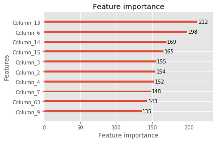

```python
import lightgbm as lgb

ax = lgb.plot_importance(model_lgbm_es, importance_type='split', max_num_features=10)
plt.show()
```

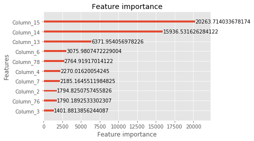

```python
ax = lgb.plot_importance(model_lgbm_es, importance_type='gain', max_num_features=10)
plt.show()
```

get model importance

```python
booster = model_lgbm_es.booster_

importance = booster.feature_importance(importance_type='gain')
```

```python
feature_importance = pd.DataFrame({'feature_name':features_full,'importance':importance} )
feature_importance = feature_importance.sort_values(['importance'], ascending=False)
```

```python
feature_importance.head(10)
```

|  | feature_name | importance |
| --- | --- | --- |
| 15 | EXT_SOURCE_3 | 20263.714034 |
| 14 | EXT_SOURCE_2 | 15936.531626 |
| 13 | EXT_SOURCE_1 | 6371.954057 |
| 6 | DAYS_BIRTH | 3075.980747 |
| 78 | past_due_times | 2764.919170 |
| 4 | AMT_GOODS_PRICE | 2270.016201 |
| 7 | DAYS_EMPLOYED | 2185.164551 |
| 2 | AMT_CREDIT | 1794.825076 |
| 76 | utilization_CC | 1790.189253 |
| 3 | AMT_ANNUITY | 1401.881386 |

Plot the feature importance

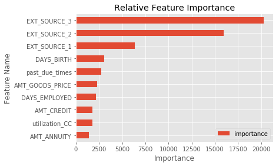

```python
fig, ax = plt.subplots()
feature_importance.head(10).plot.barh(x='feature_name', y='importance', ax=ax)
ax.invert_yaxis()
ax.set_xlabel('Importance')
ax.set_ylabel('Feature Name')
ax.set_title('Relative Feature Importance')
plt.show()
```

```python
#perform corss-validation to get a series of scores for p-value

from scipy import stats

fit_params={'early_stopping_rounds': 10,
            'eval_metric': 'auc',
            'verbose': False,
            'eval_set': [(test_X,y_test)]}

best_train_scores = cross_val_score(model_lgbm_es, train_X, y_train,
                                   scoring='roc_auc', cv=30, fit_params=fit_params)
```

```python
best_train_scores
```

```
array([0.76442599, 0.76399866, 0.76257087, 0.76459844, 0.77570011,
       0.76564863, 0.78508369, 0.76405403, 0.76844225, 0.76613153,
       0.7592385 , 0.75605914, 0.75854305, 0.77913457, 0.74739931,
       0.77549347, 0.76339179, 0.77912104, 0.75766653, 0.78302365,
       0.76757681, 0.75480649, 0.75773345, 0.76610374, 0.77175365,
       0.76354919, 0.7569002 , 0.76672163, 0.77138163, 0.77553922])
```

```python
exp_name = f"LGBM_poly1_early_stopping"
expLog.loc[len(expLog)] = [f"{exp_name}"] + list(np.round(
               [accuracy_score(y_train, model_lgbm_es.predict(train_X)),
                accuracy_score(y_valid, model_lgbm_es.predict(valid_X)),
                accuracy_score(y_test, model_lgbm_es.predict(test_X)),
                roc_auc_score(y_train, model_lgbm_es.predict_proba(train_X)[:, 1]),
                roc_auc_score(y_valid, model_lgbm_es.predict_proba(valid_X)[:, 1]),
                roc_auc_score(y_test, model_lgbm_es.predict_proba(test_X)[:, 1])],
    4))
expLog
```

|  | exp_name | Train Acc | Valid Acc | Test Acc | Train AUC | Valid AUC | Test AUC |
| --- | --- | --- | --- | --- | --- | --- | --- |
| 0 | Baseline_14_features | 0.9198 | 0.9192 | 0.9159 | 0.7359 | 0.7361 | 0.7362 |
| 1 | LGBM_poly1_early_stopping | 0.9207 | 0.9197 | 0.9189 | 0.8076 | 0.7661 | 0.7675 |
| 2 | LGBM_poly1_early_stopping | 0.9206 | 0.9198 | 0.9191 | 0.8063 | 0.7677 | 0.7672 |
| 3 | LGBM_poly1_early_stopping | 0.9206 | 0.9198 | 0.9191 | 0.8063 | 0.7677 | 0.7672 |
| 4 | LGBM_poly1_early_stopping | 0.9206 | 0.9198 | 0.9191 | 0.8063 | 0.7677 | 0.7672 |

prepare files for Kaggle submission

```python
test_class_scores = model_lgbm_es.predict_proba(Kaggle_test_X)[:, 1]
```

```python
test_class_scores[0:10]
```

```
array([0.02698749, 0.09278481, 0.03969005, 0.03832893, 0.12722543,
       0.06144288, 0.0238604 , 0.05520947, 0.00798334, 0.12854635])
```

```python
# Submission dataframe
submit_df = datasets["application_test"][['SK_ID_CURR']]
submit_df['TARGET'] = test_class_scores

submit_df.head()
```

|  | SK_ID_CURR | TARGET |
| --- | --- | --- |
| 0 | 100001 | 0.026987 |
| 1 | 100005 | 0.092785 |
| 2 | 100013 | 0.039690 |
| 3 | 100028 | 0.038329 |
| 4 | 100038 | 0.127225 |

```python
submit_df.to_csv("submission.csv",index=False)
```

significance test for best logit modeel and best LightGBM model

```python
from scipy import stats


scores_best_logit = [0.75991906, 0.75122787, 0.74861501, 0.75354972, 0.7414317 ,
       0.76889524, 0.74727686, 0.75408933, 0.75785196, 0.76689399,
       0.74262034, 0.74919817, 0.74069637, 0.75031871, 0.75001898,
       0.73282046, 0.75266586, 0.73769921, 0.75819326, 0.75466185,
       0.74839916, 0.75985089, 0.74118288, 0.76487458, 0.76284237,
       0.75431747, 0.74516205, 0.74562703, 0.7555055 , 0.76827758]

scores_best_lgbm = [0.76442599, 0.76399866, 0.76257087, 0.76459844, 0.77570011,
       0.76564863, 0.78508369, 0.76405403, 0.76844225, 0.76613153,
       0.7592385 , 0.75605914, 0.75854305, 0.77913457, 0.74739931,
       0.77549347, 0.76339179, 0.77912104, 0.75766653, 0.78302365,
       0.76757681, 0.75480649, 0.75773345, 0.76610374, 0.77175365,
       0.76354919, 0.7569002 , 0.76672163, 0.77138163, 0.77553922]

(t_score, p_value) = stats.ttest_rel(scores_best_logit, scores_best_lgbm)
p_value
```

```
1.602776962361117e-06
```

## with new features from Nishad and Naimesh

```python
# Create a class to select numerical or categorical columns
# since Scikit-Learn doesn't handle DataFrames yet
class DataFrameSelector(BaseEstimator, TransformerMixin):
    def __init__(self, attribute_names):
        self.attribute_names = attribute_names
    def fit(self, X, y=None):
        return self
    def transform(self, X):
        return X[self.attribute_names].values

def pct(x):
    return round(100*x,3)
```

select features

```python
num_attribs = ['CNT_CHILDREN',
 'AMT_INCOME_TOTAL',
 'AMT_CREDIT',
 'AMT_ANNUITY',
 'AMT_GOODS_PRICE',
 'REGION_POPULATION_RELATIVE',
 'DAYS_BIRTH',
 'DAYS_EMPLOYED',
 'DAYS_REGISTRATION',
 'DAYS_ID_PUBLISH',
 'OWN_CAR_AGE',
 'CNT_FAM_MEMBERS',
 'HOUR_APPR_PROCESS_START',
 'EXT_SOURCE_1',
 'EXT_SOURCE_2',
 'EXT_SOURCE_3',
 'APARTMENTS_AVG',
 'BASEMENTAREA_AVG',
 'YEARS_BEGINEXPLUATATION_AVG',
 'YEARS_BUILD_AVG',
 'COMMONAREA_AVG',
 'ELEVATORS_AVG',
 'ENTRANCES_AVG',
 'FLOORSMAX_AVG',
 'FLOORSMIN_AVG',
 'LANDAREA_AVG',
 'LIVINGAPARTMENTS_AVG',
 'LIVINGAREA_AVG',
 'NONLIVINGAPARTMENTS_AVG',
 'NONLIVINGAREA_AVG',
 'APARTMENTS_MODE',
 'BASEMENTAREA_MODE',
 'YEARS_BEGINEXPLUATATION_MODE',
 'YEARS_BUILD_MODE',
 'COMMONAREA_MODE',
 'ELEVATORS_MODE',
 'ENTRANCES_MODE',
 'FLOORSMAX_MODE',
 'FLOORSMIN_MODE',
 'LANDAREA_MODE',
 'LIVINGAPARTMENTS_MODE',
 'LIVINGAREA_MODE',
 'NONLIVINGAPARTMENTS_MODE',
 'NONLIVINGAREA_MODE',
 'APARTMENTS_MEDI',
 'BASEMENTAREA_MEDI',
 'YEARS_BEGINEXPLUATATION_MEDI',
 'YEARS_BUILD_MEDI',
 'COMMONAREA_MEDI',
 'ELEVATORS_MEDI',
 'ENTRANCES_MEDI',
 'FLOORSMAX_MEDI',
 'FLOORSMIN_MEDI',
 'LANDAREA_MEDI',
 'LIVINGAPARTMENTS_MEDI',
 'LIVINGAREA_MEDI',
 'NONLIVINGAPARTMENTS_MEDI',
 'NONLIVINGAREA_MEDI',
 'TOTALAREA_MODE',
 'OBS_30_CNT_SOCIAL_CIRCLE',
 'DEF_30_CNT_SOCIAL_CIRCLE',
 'OBS_60_CNT_SOCIAL_CIRCLE',
 'DEF_60_CNT_SOCIAL_CIRCLE',
 'DAYS_LAST_PHONE_CHANGE',
 'AMT_REQ_CREDIT_BUREAU_HOUR',
 'AMT_REQ_CREDIT_BUREAU_DAY',
 'AMT_REQ_CREDIT_BUREAU_WEEK',
 'AMT_REQ_CREDIT_BUREAU_MON',
 'AMT_REQ_CREDIT_BUREAU_QRT',
 'AMT_REQ_CREDIT_BUREAU_YEAR',
 'no_prev_appl',
 'no_approved_prev_appl',
 'total_creditLimit',
 'no_of_loans',
 'ave_creditLimit',
 'total_creditLimit_CC',
 'utilization_CC',
 'payment_ratio_CC',
 'past_due_times',
 'credit_income_ratio',
 'annuity_income_ratio',
 'income_credit_percen',
 'fam_member_income',
 'ann_incom_percen',
 'new_employ_to_birth_ratio',
 'new_credit_to_annuity',
 'new_credit_to_goods_ratio',
 'new_car_to_birth_ratio',
 'new_car_to_emp_ratio',
 'new_inc_per_child',
 'income_population_percen',
'credit_population_percen',
'annuity_population_percen',
'fam_member_population_percen',
'child_population_percen',
'goods_prices_population_percen',
'car_age_population_percen',]

cat_attribs = ['NAME_CONTRACT_TYPE',
 'CODE_GENDER',
 'FLAG_OWN_CAR',
 'FLAG_OWN_REALTY',
 'NAME_TYPE_SUITE',
 'NAME_INCOME_TYPE',
 'NAME_EDUCATION_TYPE',
 'NAME_FAMILY_STATUS',
 'NAME_HOUSING_TYPE',
 'FLAG_MOBIL',
 'FLAG_EMP_PHONE',
 'FLAG_WORK_PHONE',
 'FLAG_CONT_MOBILE',
 'FLAG_PHONE',
 'FLAG_EMAIL',
 'OCCUPATION_TYPE',
 'REGION_RATING_CLIENT',
 'REGION_RATING_CLIENT_W_CITY',
 'WEEKDAY_APPR_PROCESS_START',
 'REG_REGION_NOT_LIVE_REGION',
 'REG_REGION_NOT_WORK_REGION',
 'LIVE_REGION_NOT_WORK_REGION',
 'REG_CITY_NOT_LIVE_CITY',
 'REG_CITY_NOT_WORK_CITY',
 'LIVE_CITY_NOT_WORK_CITY',
 'ORGANIZATION_TYPE',
 'FONDKAPREMONT_MODE',
 'HOUSETYPE_MODE',
 'WALLSMATERIAL_MODE',
 'EMERGENCYSTATE_MODE',
 'FLAG_DOCUMENT_2',
 'FLAG_DOCUMENT_3',
 'FLAG_DOCUMENT_4',
 'FLAG_DOCUMENT_5',
 'FLAG_DOCUMENT_6',
 'FLAG_DOCUMENT_7',
 'FLAG_DOCUMENT_8',
 'FLAG_DOCUMENT_9',
 'FLAG_DOCUMENT_10',
 'FLAG_DOCUMENT_11',
 'FLAG_DOCUMENT_12',
 'FLAG_DOCUMENT_13',
 'FLAG_DOCUMENT_14',
 'FLAG_DOCUMENT_15',
 'FLAG_DOCUMENT_16',
 'FLAG_DOCUMENT_17',
 'FLAG_DOCUMENT_18',
 'FLAG_DOCUMENT_19',
 'FLAG_DOCUMENT_20',
 'FLAG_DOCUMENT_21']
```

```python
%%time

# build pipeline

num_pipeline = Pipeline([
        ('selector', DataFrameSelector(num_attribs)),
        ('imputer', SimpleImputer(strategy='median')),
        ('std_scaler', StandardScaler()),
    ])

cat_pipeline = Pipeline([
        ('selector', DataFrameSelector(cat_attribs)),
        ('imputer', SimpleImputer(strategy='constant', fill_value = 'N/A')),
        ('ohe', OneHotEncoder(sparse=False, dtype=np.uint8, handle_unknown="ignore"))
    ])

data_prep_pipeline = FeatureUnion(transformer_list=[
        ("num_pipeline", num_pipeline),
        ("cat_pipeline", cat_pipeline),
    ])
```

```
Wall time: 0 ns
```

```python
from sklearn.model_selection import train_test_split

X_train= train[num_attribs + cat_attribs]
y_train = train['TARGET']
X_train, X_valid, y_train, y_valid = train_test_split(X_train, y_train, test_size=0.15, stratify=y_train, random_state=42)

# this is for only setting aside 1 test data set. Since we are going to do K-fold cross validation in GridSearch, we won't do this step.
X_train, X_test, y_train, y_test = train_test_split(X_train, y_train, test_size=0.15, random_state=42)

X_kaggle_test= test[num_attribs + cat_attribs]
print(f"X train           shape: {X_train.shape}")
print(f"X validation      shape: {X_valid.shape}")
print(f"X test            shape: {X_test.shape}")
print(f"X X_kaggle_test   shape: {X_kaggle_test.shape}")
```

```
X train           shape: (222176, 147)
X validation      shape: (46127, 147)
X test            shape: (39208, 147)
X X_kaggle_test   shape: (48744, 147)
```

```python
%%time
train_X = data_prep_pipeline.fit_transform(X_train)
valid_X = data_prep_pipeline.transform(X_valid)
test_X = data_prep_pipeline.transform(X_test)
Kaggle_test_X = data_prep_pipeline.transform(X_kaggle_test)
```

```
Wall time: 10 s
```

```python
try:
    expLog
except NameError:
    expLog = pd.DataFrame(columns=["exp_name",
                                   "Train Acc",
                                   "Valid Acc",
                                   "Test  Acc",
                                   "Train AUC",
                                   "Valid AUC",
                                   "Test  AUC"
                                  ])
```

early stopping to avoid overfitting for lgbm

```python
%%time
from lightgbm import LGBMClassifier
np.random.seed(42)

model_lgbm_es_add_features = LGBMClassifier(num_iterations=10000,
    bagging_fraction=0.8280934509687381,
    feature_fraction=0.13140441247373727,
    learning_rate=0.0355693168731072,
    max_depth=10,
    min_child_samples=22,
    min_child_weight=5.298202574719083,
    num_leaves=46,
    reg_alpha=0.884680296141274,
    reg_lambda=0.03948815181755697,
    subsample=0.25869763494360765,
    verbose=1)

model_lgbm_es_add_features.fit(train_X, y_train, eval_metric= ['logloss', 'auc'],
            verbose= 200, eval_set=[(test_X,y_test)],
                 early_stopping_rounds=1000)
```

```
Training until validation scores don't improve for 1000 rounds.
[200]	valid_0's auc: 0.769399	valid_0's binary_logloss: 0.246118
[400]	valid_0's auc: 0.775617	valid_0's binary_logloss: 0.242964
[600]	valid_0's auc: 0.7768	valid_0's binary_logloss: 0.242311
[800]	valid_0's auc: 0.776907	valid_0's binary_logloss: 0.242157
[1000]	valid_0's auc: 0.776232	valid_0's binary_logloss: 0.242313
[1200]	valid_0's auc: 0.776002	valid_0's binary_logloss: 0.242424
[1400]	valid_0's auc: 0.775886	valid_0's binary_logloss: 0.242436
[1600]	valid_0's auc: 0.775697	valid_0's binary_logloss: 0.242481
Early stopping, best iteration is:
[675]	valid_0's auc: 0.777174	valid_0's binary_logloss: 0.242161
Wall time: 48.7 s
```

```python
%%time
from lightgbm import LGBMClassifier
np.random.seed(42)

model_lgbm_es_add_features = LGBMClassifier(num_iterations=10000,
    bagging_fraction=0.8,
    feature_fraction=0.1,
    learning_rate=0.03,
    max_depth=10,
    min_child_samples=22,
    min_child_weight=4,
    num_leaves=40,
    reg_alpha=0.8,
    reg_lambda=0.035,
    subsample=0.2,
    verbose=1)

model_lgbm_es_add_features.fit(train_X, y_train, eval_metric= ['logloss', 'auc'],
            verbose= 200, eval_set=[(test_X,y_test)],
                 early_stopping_rounds=1000)
```

```
Training until validation scores don't improve for 1000 rounds.
[200]	valid_0's binary_logloss: 0.249044	valid_0's auc: 0.764544
[400]	valid_0's binary_logloss: 0.244116	valid_0's auc: 0.773936
[600]	valid_0's binary_logloss: 0.24289	valid_0's auc: 0.776066
[800]	valid_0's binary_logloss: 0.242378	valid_0's auc: 0.777046
[1000]	valid_0's binary_logloss: 0.242088	valid_0's auc: 0.777599
[1200]	valid_0's binary_logloss: 0.242102	valid_0's auc: 0.777395
[1400]	valid_0's binary_logloss: 0.24205	valid_0's auc: 0.777452
[1600]	valid_0's binary_logloss: 0.242106	valid_0's auc: 0.777262
[1800]	valid_0's binary_logloss: 0.242197	valid_0's auc: 0.776917
[2000]	valid_0's binary_logloss: 0.242218	valid_0's auc: 0.776909
Early stopping, best iteration is:
[1081]	valid_0's binary_logloss: 0.24202	valid_0's auc: 0.777735
Wall time: 1min 31s
```

get feature names

```python
imputer = SimpleImputer(strategy='constant', fill_value = 'N/A')
ohe = OneHotEncoder(sparse=False, dtype=np.uint8, handle_unknown="ignore")

X_train_cat_impute = imputer.fit_transform(X_train[cat_attribs])
X_train_cat_impute_ohe = ohe.fit_transform(X_train_cat_impute)
```

```python
cat_attribs_ohe = []

for attr in list(ohe.get_feature_names()):
    str_rep = attr.split('_')[0]
    idx = int(attr[1:].split('_')[0])
    attr_ = attr.replace(str_rep, cat_attribs[idx])
    cat_attribs_ohe.append(attr_)
```

```python
features_full = num_attribs + cat_attribs_ohe
```

plot model importance, but we are missing column names

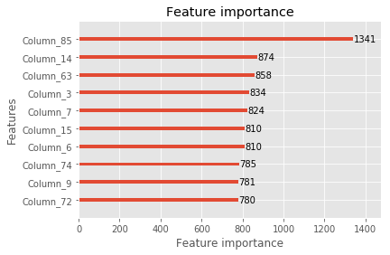

```python
import lightgbm as lgb

ax = lgb.plot_importance(model_lgbm_es_add_features, importance_type='split', max_num_features=10)
plt.show()
```

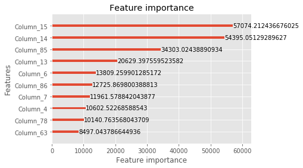

```python
ax = lgb.plot_importance(model_lgbm_es_add_features, importance_type='gain', max_num_features=10)
plt.show()
```

get model importance

```python
booster = model_lgbm_es_add_features.booster_

importance = booster.feature_importance(importance_type='gain')
```

```python
feature_importance = pd.DataFrame({'feature_name':features_full,'importance':importance} )
feature_importance = feature_importance.sort_values(['importance'], ascending=False)
```

```python
feature_importance.head(10)
```

|  | feature_name | importance |
| --- | --- | --- |
| 15 | EXT_SOURCE_3 | 57074.212437 |
| 14 | EXT_SOURCE_2 | 54395.051293 |
| 85 | new_credit_to_annuity | 34303.024389 |
| 13 | EXT_SOURCE_1 | 20629.397560 |
| 6 | DAYS_BIRTH | 13809.259901 |
| 86 | new_credit_to_goods_ratio | 12725.869800 |
| 7 | DAYS_EMPLOYED | 11961.578842 |
| 4 | AMT_GOODS_PRICE | 10602.522686 |
| 78 | past_due_times | 10140.763568 |
| 63 | DAYS_LAST_PHONE_CHANGE | 8497.043787 |

Plot the feature importance

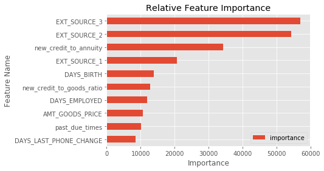

```python
fig, ax = plt.subplots()
feature_importance.head(10).plot.barh(x='feature_name', y='importance', ax=ax)
ax.invert_yaxis()
ax.set_xlabel('Importance')
ax.set_ylabel('Feature Name')
ax.set_title('Relative Feature Importance')
plt.show()
```

```python
#perform corss-validation to get a series of scores for p-value

from scipy import stats

fit_params={'early_stopping_rounds': 100,
            'eval_metric': 'auc',
            'verbose': False,
            'eval_set': [(test_X,y_test)]}

best_train_scores = cross_val_score(model_lgbm_es_add_features, train_X, y_train,
                                   scoring='roc_auc', cv=30, fit_params=fit_params)
```

```python
best_train_scores
```

```
array([0.77030327, 0.76782745, 0.76700559, 0.77593431, 0.77713727,
       0.77036133, 0.79035556, 0.77266737, 0.77913236, 0.77492249,
       0.77124891, 0.76838444, 0.76967325, 0.7883767 , 0.75981046,
       0.7842581 , 0.76804569, 0.79176172, 0.76366313, 0.7914916 ,
       0.77854834, 0.76156963, 0.77616358, 0.77599433, 0.78130813,
       0.77984074, 0.76778723, 0.77552224, 0.77899436, 0.78036259])
```

```python
from scipy import stats


scores_best_lgbm_p2 = [0.76442599, 0.76399866, 0.76257087, 0.76459844, 0.77570011,
       0.76564863, 0.78508369, 0.76405403, 0.76844225, 0.76613153,
       0.7592385 , 0.75605914, 0.75854305, 0.77913457, 0.74739931,
       0.77549347, 0.76339179, 0.77912104, 0.75766653, 0.78302365,
       0.76757681, 0.75480649, 0.75773345, 0.76610374, 0.77175365,
       0.76354919, 0.7569002 , 0.76672163, 0.77138163, 0.77553922]

scores_best_lgbm_p3 = [0.77030327, 0.76782745, 0.76700559, 0.77593431, 0.77713727,
       0.77036133, 0.79035556, 0.77266737, 0.77913236, 0.77492249,
       0.77124891, 0.76838444, 0.76967325, 0.7883767 , 0.75981046,
       0.7842581 , 0.76804569, 0.79176172, 0.76366313, 0.7914916 ,
       0.77854834, 0.76156963, 0.77616358, 0.77599433, 0.78130813,
       0.77984074, 0.76778723, 0.77552224, 0.77899436, 0.78036259]

(t_score, p_value) = stats.ttest_rel(scores_best_lgbm_p2, scores_best_lgbm_p3)
p_value
```

```
1.3092543392628766e-13
```

```python
from sklearn.metrics import accuracy_score, roc_auc_score

exp_name = f"LGBM_additional_features_early_stopping"
expLog.loc[len(expLog)] = [f"{exp_name}"] + list(np.round(
               [accuracy_score(y_train, model_lgbm_es_add_features.predict(train_X)),
                accuracy_score(y_valid, model_lgbm_es_add_features.predict(valid_X)),
                accuracy_score(y_test, model_lgbm_es_add_features.predict(test_X)),
                roc_auc_score(y_train, model_lgbm_es_add_features.predict_proba(train_X)[:, 1]),
                roc_auc_score(y_valid, model_lgbm_es_add_features.predict_proba(valid_X)[:, 1]),
                roc_auc_score(y_test, model_lgbm_es_add_features.predict_proba(test_X)[:, 1])],
    4))
expLog
```

|  | exp_name | Train Acc | Valid Acc | Test Acc | Train AUC | Valid AUC | Test AUC |
| --- | --- | --- | --- | --- | --- | --- | --- |
| 0 | LGBM_additional_features_early_stopping | 0.923 | 0.9198 | 0.9191 | 0.8614 | 0.7783 | 0.7772 |

```python
test_class_scores = model_lgbm_es_add_features.predict_proba(Kaggle_test_X)[:, 1]
```

```python
test_class_scores[0:10]
```

```
array([0.02956654, 0.07460881, 0.01716735, 0.02864101, 0.11232746,
       0.04347645, 0.01325245, 0.06442084, 0.00954362, 0.07423225])
```

```python
# Submission dataframe
submit_df = datasets["application_test"][['SK_ID_CURR']]
submit_df['TARGET'] = test_class_scores

submit_df.head()
```

|  | SK_ID_CURR | TARGET |
| --- | --- | --- |
| 0 | 100001 | 0.029567 |
| 1 | 100005 | 0.074609 |
| 2 | 100013 | 0.017167 |
| 3 | 100028 | 0.028641 |
| 4 | 100038 | 0.112327 |

```python
submit_df.to_csv("submission.csv",index=False)
```

use more data for training (90% train and 10% test)

```python
from sklearn.model_selection import train_test_split

X_train= train[num_attribs + cat_attribs]
y_train = train['TARGET']
X_train, X_valid, y_train, y_valid = train_test_split(X_train, y_train, test_size=0.1, stratify=y_train, random_state=42)

X_kaggle_test= test[num_attribs + cat_attribs]
print(f"X train           shape: {X_train.shape}")
print(f"X validation      shape: {X_valid.shape}")
print(f"X X_kaggle_test   shape: {X_kaggle_test.shape}")
```

```
X train           shape: (276759, 147)
X validation      shape: (30752, 147)
X X_kaggle_test   shape: (48744, 147)
```

```python
%%time
train_X = data_prep_pipeline.fit_transform(X_train)
valid_X = data_prep_pipeline.transform(X_valid)
Kaggle_test_X = data_prep_pipeline.transform(X_kaggle_test)
```

```
Wall time: 11.3 s
```

```python
%%time
from lightgbm import LGBMClassifier
np.random.seed(42)

model_lgbm_es_add_features_full = LGBMClassifier(num_iterations=10000,
    bagging_fraction=0.8,
    feature_fraction=0.1,
    learning_rate=0.03,
    max_depth=10,
    min_child_samples=22,
    min_child_weight=4,
    num_leaves=40,
    reg_alpha=0.8,
    reg_lambda=0.035,
    subsample=0.2,
    verbose=1)

model_lgbm_es_add_features_full.fit(train_X, y_train, eval_metric= ['logloss', 'auc'],
            verbose= 200, eval_set=[(valid_X ,y_valid)],
                 early_stopping_rounds=1000)
```

```
Training until validation scores don't improve for 1000 rounds.
[200]	valid_0's binary_logloss: 0.246189	valid_0's auc: 0.768442
[400]	valid_0's binary_logloss: 0.241521	valid_0's auc: 0.776364
[600]	valid_0's binary_logloss: 0.240134	valid_0's auc: 0.7786
[800]	valid_0's binary_logloss: 0.23964	valid_0's auc: 0.779346
[1000]	valid_0's binary_logloss: 0.23955	valid_0's auc: 0.779385
[1200]	valid_0's binary_logloss: 0.239339	valid_0's auc: 0.779801
[1400]	valid_0's binary_logloss: 0.23947	valid_0's auc: 0.779396
[1600]	valid_0's binary_logloss: 0.239383	valid_0's auc: 0.779638
[1800]	valid_0's binary_logloss: 0.239356	valid_0's auc: 0.779735
[2000]	valid_0's binary_logloss: 0.239471	valid_0's auc: 0.779452
[2200]	valid_0's binary_logloss: 0.239512	valid_0's auc: 0.779223
Early stopping, best iteration is:
[1228]	valid_0's binary_logloss: 0.239314	valid_0's auc: 0.779892
Wall time: 1min 54s
```

```python
test_class_scores = model_lgbm_es_add_features_full.predict_proba(Kaggle_test_X)[:, 1]
```

```python
test_class_scores[0:10]
```

```
array([0.03566684, 0.09055599, 0.01781322, 0.02858402, 0.11742245,
       0.02528196, 0.01015482, 0.06329073, 0.00763837, 0.08059871])
```

```python
# Submission dataframe
submit_df = datasets["application_test"][['SK_ID_CURR']]
submit_df['TARGET'] = test_class_scores

submit_df.head()
```

|  | SK_ID_CURR | TARGET |
| --- | --- | --- |
| 0 | 100001 | 0.035667 |
| 1 | 100005 | 0.090556 |
| 2 | 100013 | 0.017813 |
| 3 | 100028 | 0.028584 |
| 4 | 100038 | 0.117422 |

```python
submit_df.to_csv("submission.csv",index=False)
```

Previous Experiment Result without New Features from Nishad/Neimesh

# A Functionized Approach

```python
import gc
from sklearn.externals import joblib
import math
import numpy as np
import os
import pandas as pd
from sklearn.base import BaseEstimator, TransformerMixin
from sklearn.compose import ColumnTransformer
from sklearn.linear_model import LogisticRegression
from sklearn.metrics import roc_auc_score
from sklearn.model_selection import train_test_split
from sklearn.model_selection import cross_val_score
from sklearn.model_selection import GridSearchCV
from sklearn.impute import SimpleImputer
from sklearn.preprocessing import FunctionTransformer, OneHotEncoder, StandardScaler
from sklearn.pipeline import Pipeline, FeatureUnion
from sklearn.metrics import accuracy_score, roc_auc_score
from statistics import mean
from sklearn.preprocessing import PolynomialFeatures
import timeit
import uuid
from itertools import combinations

config_file = os.path.join(os.getcwd(), "workingdir.config")
with open(config_file, 'r') as f:
    WORKING_DIR = f.readline()
DATA_DIR = os.path.join(WORKING_DIR, 'Data')
LOG_DIR = os.path.join(WORKING_DIR, 'runs')

def load_data(name):
    in_path = os.path.join(DATA_DIR, f'{name}.csv')
    df = pd.read_csv(in_path)
    return df

def get_datasets(phase):
    datasets = {}
    datasets["application"] = load_data(f"application_{phase}")
    print(f"loaded {len(datasets['application'])} records")
    ds_names = ("bureau","bureau_balance","credit_card_balance","installments_payments",
            "previous_application","POS_CASH_balance")
    for ds_name in ds_names:
        datasets[ds_name] = load_data(ds_name)
    return datasets

def features_from_previous_application(X, datasets):
    '''
    creates the no_prev_appl and no_approved_prev_appl columns
    '''
    prev_app = datasets['previous_application']
    no_app_customer = prev_app.loc[(prev_app.DAYS_DECISION >= -365) &
           (prev_app.NAME_CONTRACT_STATUS != 'Canceled'), ].groupby('SK_ID_CURR').SK_ID_PREV.count().sort_values(ascending=False) # only select the applications in the past 12 months
    no_app_customer = no_app_customer.to_frame()
    no_app_customer.reset_index(inplace=True)
    no_app_customer.rename(columns={'SK_ID_PREV':'no_prev_appl'}, inplace=True)

    no_approved_app_customer = prev_app.loc[(prev_app.DAYS_DECISION >= -365) &
           (prev_app.NAME_CONTRACT_STATUS == 'Approved'), ].groupby('SK_ID_CURR').SK_ID_PREV.count().sort_values(ascending=False) # only select the applications in the past 12 months
    no_approved_app_customer = no_approved_app_customer.to_frame()
    no_approved_app_customer.reset_index(inplace=True)
    no_approved_app_customer.rename(columns={'SK_ID_PREV':'no_approved_prev_appl'}, inplace=True)

    X = pd.merge(X, no_app_customer, on='SK_ID_CURR', how='left')
    X = pd.merge(X, no_approved_app_customer, on='SK_ID_CURR', how='left')
    X[['no_prev_appl']] = X[['no_prev_appl']].fillna(value=0)
    X[['no_approved_prev_appl']] = X[['no_approved_prev_appl']].fillna(0)

    return X

def features_from_bureau(X, datasets):
    '''
    Engineered features:
    - total_creditLimit
    - no_of_loans
    - ave_creditLimit
    '''
    bureau = datasets['bureau']
    credit_sum = bureau[(bureau.CREDIT_ACTIVE == 'Active') & (bureau.CREDIT_CURRENCY == 'currency 1')] \
        .groupby('SK_ID_CURR').AMT_CREDIT_SUM.sum()
    credit_sum = credit_sum.to_frame()
    credit_sum.reset_index(inplace=True)

    no_loans = bureau[(bureau.CREDIT_ACTIVE == 'Active') & (bureau.CREDIT_CURRENCY == 'currency 1')] \
        .groupby('SK_ID_CURR').SK_ID_BUREAU.count()
    no_loans = no_loans.to_frame()
    no_loans.reset_index(inplace=True)

    bureau_info = pd.merge(credit_sum, no_loans, how='outer', on='SK_ID_CURR')
    bureau_info.rename(columns={'AMT_CREDIT_SUM':'total_creditLimit', 'SK_ID_BUREAU':'no_of_loans'}, inplace=True)
    bureau_info['ave_creditLimit'] = bureau_info.eval('total_creditLimit/no_of_loans')

    X = pd.merge(X, bureau_info, on='SK_ID_CURR', how='left')
    X[['total_creditLimit', 'no_of_loans', 'ave_creditLimit']] = X[['total_creditLimit', 'no_of_loans', 'ave_creditLimit']].fillna(0)

    return X

def features_from_credit_card_balance(X, datasets):
    '''
    Engineered features:
    - utilization_CC
    - payment_ratio_CC
    - total_credit_limit_CC
    '''
    ccb = datasets['credit_card_balance']
    creditCard_info = ccb[(ccb.MONTHS_BALANCE >= -24) &
                          (ccb.NAME_CONTRACT_STATUS =='Active') &
                          (ccb.AMT_CREDIT_LIMIT_ACTUAL > 0)] \
                    .groupby('SK_ID_CURR')['AMT_BALANCE', 'AMT_CREDIT_LIMIT_ACTUAL', 'AMT_PAYMENT_TOTAL_CURRENT'].sum()
    creditCard_info.reset_index(inplace=True)

    creditCard_info['utilization_CC'] = creditCard_info.eval('AMT_BALANCE/AMT_CREDIT_LIMIT_ACTUAL')
    creditCard_info['payment_ratio_CC'] = creditCard_info.eval('AMT_PAYMENT_TOTAL_CURRENT/AMT_BALANCE')
    creditCard_info.loc[creditCard_info.payment_ratio_CC.isnull(), 'payment_ratio_CC'] = 1
    creditCard_info.loc[creditCard_info.payment_ratio_CC > 1, 'payment_ratio_CC'] = 1
    creditCard_info.drop(columns=['AMT_BALANCE', 'AMT_PAYMENT_TOTAL_CURRENT'], inplace=True)
    creditCard_info.rename(columns={'AMT_CREDIT_LIMIT_ACTUAL':'total_creditLimit_CC'}, inplace=True)

    X = pd.merge(X, creditCard_info, on='SK_ID_CURR', how='left')
    return X # best fillna strategy will be left to grid search

def features_from_installments_payments(X, datasets):
    '''
    Engineered features:
    - past_due_times
    '''
    ip = datasets['installments_payments']
    ip['past_due_times'] = (ip.eval('DAYS_ENTRY_PAYMENT - DAYS_INSTALMENT') > 0).astype(int)
    past_due_info = ip[ip['DAYS_INSTALMENT'] >= -730].groupby('SK_ID_CURR')['past_due_times'].sum()
    past_due_info = past_due_info.to_frame()
    past_due_info.reset_index(inplace=True)

    X = pd.merge(X, past_due_info, on='SK_ID_CURR', how='left')
    return X

def features_from_application(X):
    '''
    Engineered features:
    - credit_income_ratio
    - annuity_income_ratio
    - REGION_POPULATION_RELATIVE_flag
    '''
    X['credit_income_ratio'] = X.eval('AMT_CREDIT/AMT_INCOME_TOTAL') #credit to income ratio
    X['annuity_income_ratio'] = X.eval('AMT_ANNUITY/AMT_INCOME_TOTAL') #annuity to income ratio
    return X
```

```python
def build_ratio_features(X):
    '''
    use Nishad and Neimesh methods
    '''
    X['income_population_percen'] = (
        X.AMT_INCOME_TOTAL / X.REGION_POPULATION_RELATIVE).replace(np.inf, 0)
    X['credit_population_percen'] = (
        X.AMT_CREDIT / X.REGION_POPULATION_RELATIVE).replace(np.inf, 0)
    X['annuity_population_percen'] = (
        X.AMT_ANNUITY / X.REGION_POPULATION_RELATIVE).replace(np.inf, 0)
    X['fam_member_population_percen'] = (
        X.CNT_FAM_MEMBERS / X.REGION_POPULATION_RELATIVE).replace(np.inf, 0)
    X['child_population_percen'] = (
        X.CNT_CHILDREN / X.REGION_POPULATION_RELATIVE).replace(np.inf, 0)
    X['goods_prices_population_percen'] = (
        X.AMT_GOODS_PRICE / X.REGION_POPULATION_RELATIVE).replace(np.inf, 0)
    X['car_age_population_percen'] = (
        X.OWN_CAR_AGE / X.REGION_POPULATION_RELATIVE).replace(np.inf, 0)

#     X['no_prev_app_income_percen'] = (
#         X.no_prev_appl / X.AMT_INCOME_TOTAL).replace(np.inf, 0)
#     X['no_prev_app_annuity_percen'] = (
#         X.no_prev_appl / X.AMT_ANNUITY).replace(np.inf, 0)
#     X['no_prev_app_credit_percen'] = (
#         X.no_prev_appl / X.AMT_CREDIT).replace(np.inf, 0)
#     X['no_prev_app_days_birth_percen'] = (
#         X.no_prev_appl / X.DAYS_BIRTH).replace(np.inf, 0)
#     X['no_prev_app_days_employed_percen'] = (
#         X.no_prev_appl / X.DAYS_EMPLOYED).replace(np.inf, 0)

#     X['no_approved_prev_appl_income_percen'] = (
#         X.no_approved_prev_appl / X.AMT_INCOME_TOTAL).replace(np.inf, 0)
#     X['no_approved_prev_appl_annuity_percen'] = (
#         X.no_approved_prev_appl / X.AMT_ANNUITY).replace(np.inf, 0)
#     X['no_approved_prev_appl_credit_percen'] = (
#         X.no_approved_prev_appl / X.AMT_CREDIT).replace(np.inf, 0)
#     X['no_approved_prev_appl_days_birth_percen'] = (
#         X.no_approved_prev_appl / X.DAYS_BIRTH).replace(np.inf, 0)
#     X['no_approved_prev_appl_days_employed_percen'] = (
#         X.no_approved_prev_appl / X.DAYS_EMPLOYED).replace(np.inf, 0)

#     X['total_creditLimit_income_percen'] = (
#         X.total_creditLimit / X.AMT_INCOME_TOTAL).replace(np.inf, 0)
#     X['total_creditLimit_annuity_percen'] = (
#         X.total_creditLimit / X.AMT_ANNUITY).replace(np.inf, 0)
#     X['total_creditLimit_credit_percen'] = (
#         X.total_creditLimit / X.AMT_CREDIT).replace(np.inf, 0)
#     X['total_creditLimit_days_birth_percen'] = (
#         X.total_creditLimit / X.DAYS_BIRTH).replace(np.inf, 0)
#     X['total_creditLimit_days_employed_percen'] = (
#         X.total_creditLimit / X.DAYS_EMPLOYED).replace(np.inf, 0)

#     X['no_of_loans_income_percen'] = (
#         X.no_of_loans / X.AMT_INCOME_TOTAL).replace(np.inf, 0)
#     X['no_of_loans_annuity_percen'] = (
#         X.no_of_loans / X.AMT_ANNUITY).replace(np.inf, 0)
#     X['no_of_loans_credit_percen'] = (
#         X.no_of_loans / X.AMT_CREDIT).replace(np.inf, 0)
#     X['no_of_loans_days_birth_percen'] = (
#         X.no_of_loans / X.DAYS_BIRTH).replace(np.inf, 0)
#     X['no_of_loans_days_employed_percen'] = (
#         X.no_of_loans / X.DAYS_EMPLOYED).replace(np.inf, 0)

#     X['utilization_CC_income_percen'] = (
#         X.utilization_CC / X.AMT_INCOME_TOTAL).replace(np.inf, 0)
#     X['utilization_CC_annuity_percen'] = (
#         X.utilization_CC / X.AMT_ANNUITY).replace(np.inf, 0)
#     X['utilization_CC_credit_percen'] = (
#         X.utilization_CC / X.AMT_CREDIT).replace(np.inf, 0)
#     X['utilization_CC_days_birth_percen'] = (
#         X.utilization_CC / X.DAYS_BIRTH).replace(np.inf, 0)
#     X['utilization_CC_days_employed_percen'] = (
#         X.utilization_CC / X.DAYS_EMPLOYED).replace(np.inf, 0)

#     X['payment_ratio_CC_income_percen'] = (
#         X.payment_ratio_CC / X.AMT_INCOME_TOTAL).replace(np.inf, 0)
#     X['payment_ratio_CC_annuity_percen'] = (
#         X.payment_ratio_CC / X.AMT_ANNUITY).replace(np.inf, 0)
#     X['payment_ratio_CC_credit_percen'] = (
#         X.payment_ratio_CC / X.AMT_CREDIT).replace(np.inf, 0)
#     X['payment_ratio_CC_days_birth_percen'] = (
#         X.payment_ratio_CC / X.DAYS_BIRTH).replace(np.inf, 0)
#     X['payment_ratio_CC_days_employed_percen'] = (
#         X.payment_ratio_CC / X.DAYS_EMPLOYED).replace(np.inf, 0)

#     X['past_due_times_income_percen'] = (
#         X.past_due_times / X.AMT_INCOME_TOTAL).replace(np.inf, 0)
#     X['past_due_timesC_annuity_percen'] = (
#         X.past_due_times / X.AMT_ANNUITY).replace(np.inf, 0)
#     X['past_due_times_credit_percen'] = (
#         X.past_due_times / X.AMT_CREDIT).replace(np.inf, 0)
#     X['past_due_times_days_birth_percen'] = (
#         X.past_due_times / X.DAYS_BIRTH).replace(np.inf, 0)
#     X['past_due_times_days_employed_percen'] = (
#         X.past_due_times / X.DAYS_EMPLOYED).replace(np.inf, 0)


    # the following features come from Naimesh and Nishad @thank you
    X['income_credit_percen'] = (
        X.AMT_INCOME_TOTAL / X.AMT_CREDIT).replace(np.inf, 0)
    X['fam_member_income'] = (
        X.AMT_INCOME_TOTAL / X.CNT_FAM_MEMBERS).replace(np.inf, 0)
    X['ann_incom_percen'] = (
        X.AMT_ANNUITY / X.AMT_INCOME_TOTAL).replace(np.inf, 0)
    X['new_employ_to_birth_ratio'] = (
        X.DAYS_EMPLOYED / X.DAYS_BIRTH).replace(np.inf, 0)
    X['new_credit_to_annuity'] = (
        X['AMT_CREDIT'] / X['AMT_ANNUITY']).replace(np.inf, 0)
    X['new_credit_to_goods_ratio'] = (
        X['AMT_CREDIT'] / X['AMT_GOODS_PRICE']).replace(np.inf, 0)
    X['new_car_to_birth_ratio'] = (
        X['OWN_CAR_AGE'] / X['DAYS_BIRTH']).replace(np.inf, 0)
    X['new_car_to_emp_ratio'] = (
        X['OWN_CAR_AGE'] / X['DAYS_EMPLOYED']).replace(np.inf, 0)
    X['new_inc_per_child'] = (
        X['AMT_INCOME_TOTAL'] / (1 + X['CNT_CHILDREN'])).replace(np.inf, 0)

    return X

def build_ratio_multi_features(X):
    '''
    take ratios of all 2-way combo of numerical features for ratio and multiplication
    '''
    var_list = ['CNT_CHILDREN',
     'AMT_INCOME_TOTAL',
     'AMT_CREDIT',
     'AMT_ANNUITY',
     'AMT_GOODS_PRICE',
     'REGION_POPULATION_RELATIVE',
     'DAYS_BIRTH',
     'DAYS_EMPLOYED',
     'OWN_CAR_AGE',
     'CNT_FAM_MEMBERS',
     'no_prev_appl',
     'no_approved_prev_appl',
     'total_creditLimit',
     'no_of_loans',
     'ave_creditLimit',
     'total_creditLimit_CC',
     'utilization_CC',
     'payment_ratio_CC',
     'past_due_times']
```

```python
    names = []

    for combo in combinations(var_list, 2):
        ratio_feature_name = '_'.join(str(x) for x in combo) + '_ratio'
        X[ratio_feature_name] = (
            X[combo[0]] / X[combo[1]]).replace(np.inf, 0)

        multi_feature_name = '_'.join(str(x) for x in combo) + '_multi'
        X[multi_feature_name] = X[combo[0]] * X[combo[1]]

        names.append(ratio_feature_name)
        names.append(multi_feature_name)
#         print('"' + ratio_feature_name + '",')
#         print('"' + multi_feature_name + '",')

    return X


def build_features(datasets):
    print("features from previous application")
    X = features_from_previous_application(datasets['application'], datasets)
    print("features from bureau")
    X = features_from_bureau(X, datasets)
    print("features from credit card balance")
    X = features_from_credit_card_balance(X, datasets)
    print("features from installments")
    X = features_from_installments_payments(X, datasets)
    print("features from application")
    X = features_from_application(X)

    # Converting days to years and removing outliers
    X[X.columns[X.columns.str.contains('DAYS')]] = abs(
    X[X.columns[X.columns.str.contains('DAYS')]]).replace(365243, np.nan)/365

    #create new features are the ratio of two numerical features
    X = build_ratio_features(X)
#     X = build_ratio_multi_features(X)

    return X


class DataFrameSelector(BaseEstimator, TransformerMixin):
    def __init__(self, attribute_names):
        self.attribute_names = attribute_names
    def fit(self, X, y=None):
        return self
    def transform(self, X):
        return X[self.attribute_names].values

def print_msg(X, **kwargs):
    for key, value in kwargs.items():
        print(value)
    return X

def get_standard_pipeline(cat_attribs, num_attribs, poly_degree=1):
#     import pdb; pdb.set_trace()
    num_pipeline = Pipeline([
        ('num_selector', DataFrameSelector(num_attribs)),
        ('print_num_1', FunctionTransformer(print_msg, kw_args=dict(msg="num_selector"), validate=False)),
        ('num_imputer', SimpleImputer(strategy='mean')),
        ('print_num_2', FunctionTransformer(print_msg, kw_args=dict(msg="num_imputer"), validate=False)),
        ('std_scaler', StandardScaler()),
        ('print_num_3', FunctionTransformer(print_msg, kw_args=dict(msg="num_scaler"), validate=False)),
        ('polynomial', PolynomialFeatures(degree=poly_degree)),
        ('print_num_done', FunctionTransformer(print_msg, kw_args=dict(msg="num_done"), validate=False)),
    ])
#     import pdb; pdb.set_trace()
    cat_pipeline = Pipeline([
        ('cat_selector', DataFrameSelector(cat_attribs)),
        ('print_cat_1', FunctionTransformer(print_msg, kw_args=dict(msg="cat_selector"), validate=False)),
        ('cat_imputer', SimpleImputer(strategy='constant', fill_value = 'N/A')),
        ('print_cat_2', FunctionTransformer(print_msg, kw_args=dict(msg="cat_imputer"), validate=False)),
        ('ohe', OneHotEncoder(sparse=False, dtype=np.uint8, handle_unknown="ignore")),
        ('print_cat_done', FunctionTransformer(print_msg, kw_args=dict(msg="cat_done"), validate=False))
    ])
    num_cat_pipeline = ColumnTransformer(
        transformers=[
            ('num', num_pipeline, num_attribs),
            ('cat', cat_pipeline, cat_attribs)],
        n_jobs = -1
    )
#    num_cat_pipeline = FeatureUnion(transformer_list = [
#        ("num_pipe", num_pipeline),
#        ("cat_pipe", cat_pipeline)
#    ],
#    n_jobs = 2
#    )
    return num_cat_pipeline

# default_pipeline = get_standard_pipeline(cat_attribs, num_attribs)

def pre_process(preproc_pipeline, phase = "train"):
    '''
    Performs all feature engineering, data munging, etc. in a standardized way
    Returns: (transformed) X, Y, (fitted) pipeline. If phase == "test", Y and pipeline will = None
    '''
    datasets = get_datasets(phase)

    if phase == "train":
        Y = datasets['application']['TARGET']
    else:
        Y = None

    X = build_features(datasets)

    print("start pipeline")
#     import pdb; pdb.set_trace()
    if phase == "train":
#         import pdb; pdb.set_trace()
        X = preproc_pipeline.fit_transform(X)
    else:
        X = preproc_pipeline.transform(X)

    return X, Y, preproc_pipeline

def get_search_class(search_repr):
    return search_repr[:search_repr.find('(')]

def get_clf(search_repr):
    e_string = 'estimator='
    start = search_repr.find(e_string) + len(e_string)
    end = search_repr.find('),', start)
    return search_repr[start:end+1]

def get_params(search_repr, is_grid = True):
    if is_grid:
        arg_string = 'param_grid='
    else:
        arg_string = 'param_distributions='
    start = search_repr.find(arg_string) + len(arg_string)
    end = search_repr.find('},', start)
    return search_repr[start:end+1]

def run_test(X, Y,
             search,
             test_description,
             experiment_name,
             pipeline_named_steps,
             cat_attribs,
             num_attribs,
             testSize = 0.1,
             **fit_params):
    '''
    Uses grid search to search for best model params
    NOTE: set early stopping on the estimator you pass in!
    Logs results, including best model (pickled), to mlflow

    Arguments:
    `X` - training data - will be split into train and test sets
    `Y` - targets
    `search`- an instance of GridSearchCV or RandomizedSearchCV
    `test_description` - description of test run to be logged
    `experiment_name` - name of experiment that this test run is a part of
    `pipeline_named_steps` - to be logged alongside metrics for future reference
    `cat_attribs` - to be logged alongside metrics for future reference
    `num_attribs` - to be logged alongside metrics for future reference
    `testSize` - fraction of training set to hold out for sanity check/test
    `fit_params` - additional parameters to be passed to the search .fit() function
    '''
    # train/test split
    X_train, X_test, y_train, y_test = train_test_split(X, Y, test_size=testSize, random_state=42)
```

```python
    # start log
    search_repr = repr(search)
    search_class = get_search_class(search_repr)
    clf_repr = get_clf(search_repr)
    params = get_params(search_repr)

    run_attribs = []
    run_attribs.append(wrap_in_quotes(experiment_name))
    run_attribs.append(wrap_in_quotes(test_description))
    run_attribs.append(wrap_in_quotes(str(cat_attribs)))
    run_attribs.append(wrap_in_quotes(str(num_attribs)))
    run_attribs.append(wrap_in_quotes(pipeline_named_steps))
    run_attribs.append(wrap_in_quotes(search_class))
    run_attribs.append(wrap_in_quotes(params))

#     import pdb; pdb.set_trace()
    search.fit(X_train, y_train, **fit_params)
    cv_results = search.cv_results_

    # TODO in phase 3: calculate p-value w.r.t. baseline

    # sanity check with test set
    verification = VerificationTest(search.best_estimator_)
    verification.run(X_test, y_test)

    # log: best params, auc, p-value, array of train loss, array of val loss
    run_attribs.append(wrap_in_quotes(str(search.best_params_)))
    run_attribs.append(format_num(mean(cv_results['mean_fit_time'])))
    run_attribs.append(format_num(search.best_score_))
    run_attribs.append(format_num(verification.test_auc))
    run_attribs.append(format_num(verification.test_accuracy))
    run_attribs.append(format_num(verification.prediction_ms_per_row))
    run_id = str(uuid.uuid4())
    run_attribs.append(wrap_in_quotes(run_id))
    line = ','.join(run_attribs) + '\n'

    with open(os.path.join(LOG_DIR, "runs.csv"), 'a') as run_file:
        run_file.write(line)

    # store best model
    model_file = run_id + '.joblib'
    joblib.dump(search.best_estimator_, os.path.join(LOG_DIR, model_file))

class VerificationTest:
    '''
    Runs a verification test against held out test set. Calculates the following metrics,
    which are available as properties:
    * test_auc
    * test_accuracy
    * prediction_ms_per_row
    '''
    def __init__(self, model):
        '''
        `model` = best_estimator_ from search
        `significance_score` = Which metric used for p_value? Choose from ('auc', 'accuracy')
        '''
        self._model = model

    def run(self, X_test, y_test):
        '''
        `X_test`
        `y_test`
        '''
        y_hat = self._model.predict(X_test)
        self.test_accuracy = accuracy_score(y_test, y_hat)

        y_proba = self._model.predict_proba(X_test)
        self.test_auc = roc_auc_score(y_test, y_proba[:,1])

        timing_test = wrapper(self._model.predict, X_test)
        test_execution_time = timeit.timeit(timing_test, setup = gc.enable, number = 1)
        self.prediction_ms_per_row = test_execution_time * 1000000 / len(y_test)

def wrapper(func, *args, **kwargs):
    def wrapped():
        return func(*args, **kwargs)
    return wrapped

def wrap_in_quotes(s):
    s = s.replace('"', '').replace('\n', '').replace('\r', '')
    return '"' + s + '"'

def format_num(n):
    return str(round(n, 5))
```

## a small example test case

```python
%%time

NUMERIC_COLS = ['EXT_SOURCE_1', 'EXT_SOURCE_2','EXT_SOURCE_3', 'no_prev_appl', 'no_approved_prev_appl','utilization_CC',
               'past_due_times', 'OWN_CAR_AGE', 'FLOORSMAX_AVG', 'AMT_GOODS_PRICE', 'REGION_POPULATION_RELATIVE',
               'AMT_INCOME_TOTAL',  'AMT_CREDIT','DAYS_EMPLOYED','credit_income_ratio', 'annuity_income_ratio']
CATEGORY_COLS = ['CODE_GENDER', 'FLAG_OWN_REALTY','FLAG_OWN_CAR','NAME_CONTRACT_TYPE',
               'NAME_EDUCATION_TYPE','OCCUPATION_TYPE','NAME_INCOME_TYPE',
              'FLAG_EMP_PHONE', 'FLAG_WORK_PHONE', 'REGION_RATING_CLIENT', 'REGION_RATING_CLIENT_W_CITY',
              'ORGANIZATION_TYPE', 'FONDKAPREMONT_MODE', 'WALLSMATERIAL_MODE']

default_pipeline = get_standard_pipeline(cat_attribs=CATEGORY_COLS, num_attribs=NUMERIC_COLS)

X, Y, pipe = pre_process(phase = "train", preproc_pipeline = default_pipeline)
```

[output not shown]

```python
%%time

from sklearn.linear_model import LogisticRegression
import time

clf = LogisticRegression(penalty = 'l1', solver = 'saga', tol = 0.001, C = 1000)
grid = {'penalty':['l1','l2'], 'C':[100,10,1]}
search = GridSearchCV(
    estimator = clf,
    param_grid = grid,
    scoring = 'roc_auc',
    n_jobs = -1,
    cv = 4)

# log arguments
pipe_steps = repr(pipe.transformers_)
description = "benchmark LogReg with engineered features"
experiment = "LogReg"

start_time = time.time()
run_test(X, Y, search, description, experiment, pipe_steps, cat_attribs=CATEGORY_COLS,
        num_attribs=NUMERIC_COLS)
end_time = time.time()
elapsed_time = end_time - start_time
print(f"Elapsed time: {elapsed_time} seconds")
```

```
Elapsed time: 2.0827078819274902 seconds
Wall time: 2.08 s
```

# Logistic Regression using all features

```python
# select numerica and categorical features

NUMERIC_COLS_logit = ['CNT_CHILDREN',
 'AMT_INCOME_TOTAL',
 'AMT_CREDIT',
 'AMT_ANNUITY',
 'AMT_GOODS_PRICE',
 'REGION_POPULATION_RELATIVE',
 'DAYS_BIRTH',
 'DAYS_EMPLOYED',
 'DAYS_REGISTRATION',
 'DAYS_ID_PUBLISH',
 'OWN_CAR_AGE',
 'CNT_FAM_MEMBERS',
 'HOUR_APPR_PROCESS_START',
 'EXT_SOURCE_1',
 'EXT_SOURCE_2',
 'EXT_SOURCE_3',
 'APARTMENTS_AVG',
 'BASEMENTAREA_AVG',
 'YEARS_BEGINEXPLUATATION_AVG',
 'YEARS_BUILD_AVG',
 'COMMONAREA_AVG',
 'ELEVATORS_AVG',
 'ENTRANCES_AVG',
 'FLOORSMAX_AVG',
 'FLOORSMIN_AVG',
 'LANDAREA_AVG',
 'LIVINGAPARTMENTS_AVG',
 'LIVINGAREA_AVG',
 'NONLIVINGAPARTMENTS_AVG',
 'NONLIVINGAREA_AVG',
 'APARTMENTS_MODE',
 'BASEMENTAREA_MODE',
 'YEARS_BEGINEXPLUATATION_MODE',
 'YEARS_BUILD_MODE',
 'COMMONAREA_MODE',
 'ELEVATORS_MODE',
 'ENTRANCES_MODE',
 'FLOORSMAX_MODE',
 'FLOORSMIN_MODE',
 'LANDAREA_MODE',
 'LIVINGAPARTMENTS_MODE',
 'LIVINGAREA_MODE',
 'NONLIVINGAPARTMENTS_MODE',
 'NONLIVINGAREA_MODE',
 'APARTMENTS_MEDI',
 'BASEMENTAREA_MEDI',
 'YEARS_BEGINEXPLUATATION_MEDI',
 'YEARS_BUILD_MEDI',
 'COMMONAREA_MEDI',
 'ELEVATORS_MEDI',
 'ENTRANCES_MEDI',
 'FLOORSMAX_MEDI',
 'FLOORSMIN_MEDI',
 'LANDAREA_MEDI',
 'LIVINGAPARTMENTS_MEDI',
 'LIVINGAREA_MEDI',
 'NONLIVINGAPARTMENTS_MEDI',
 'NONLIVINGAREA_MEDI',
 'TOTALAREA_MODE',
 'OBS_30_CNT_SOCIAL_CIRCLE',
 'DEF_30_CNT_SOCIAL_CIRCLE',
 'OBS_60_CNT_SOCIAL_CIRCLE',
 'DEF_60_CNT_SOCIAL_CIRCLE',
 'DAYS_LAST_PHONE_CHANGE',
 'AMT_REQ_CREDIT_BUREAU_HOUR',
 'AMT_REQ_CREDIT_BUREAU_DAY',
 'AMT_REQ_CREDIT_BUREAU_WEEK',
 'AMT_REQ_CREDIT_BUREAU_MON',
 'AMT_REQ_CREDIT_BUREAU_QRT',
 'AMT_REQ_CREDIT_BUREAU_YEAR',
 'no_prev_appl',
 'no_approved_prev_appl',
 'total_creditLimit',
 'no_of_loans',
 'ave_creditLimit',
 'total_creditLimit_CC',
 'utilization_CC',
 'payment_ratio_CC',
 'past_due_times',
 'credit_income_ratio',
 'annuity_income_ratio']

CATEGORY_COLS_logit = ['NAME_CONTRACT_TYPE',
 'CODE_GENDER',
 'FLAG_OWN_CAR',
 'FLAG_OWN_REALTY',
 'NAME_TYPE_SUITE',
 'NAME_INCOME_TYPE',
 'NAME_EDUCATION_TYPE',
 'NAME_FAMILY_STATUS',
 'NAME_HOUSING_TYPE',
 'FLAG_MOBIL',
 'FLAG_EMP_PHONE',
 'FLAG_WORK_PHONE',
 'FLAG_CONT_MOBILE',
 'FLAG_PHONE',
 'FLAG_EMAIL',
 'OCCUPATION_TYPE',
 'REGION_RATING_CLIENT',
 'REGION_RATING_CLIENT_W_CITY',
 'WEEKDAY_APPR_PROCESS_START',
 'REG_REGION_NOT_LIVE_REGION',
 'REG_REGION_NOT_WORK_REGION',
 'LIVE_REGION_NOT_WORK_REGION',
 'REG_CITY_NOT_LIVE_CITY',
 'REG_CITY_NOT_WORK_CITY',
 'LIVE_CITY_NOT_WORK_CITY',
 'ORGANIZATION_TYPE',
 'FONDKAPREMONT_MODE',
 'HOUSETYPE_MODE',
 'WALLSMATERIAL_MODE',
 'EMERGENCYSTATE_MODE',
 'FLAG_DOCUMENT_2',
 'FLAG_DOCUMENT_3',
 'FLAG_DOCUMENT_4',
 'FLAG_DOCUMENT_5',
 'FLAG_DOCUMENT_6',
 'FLAG_DOCUMENT_7',
 'FLAG_DOCUMENT_8',
 'FLAG_DOCUMENT_9',
 'FLAG_DOCUMENT_10',
 'FLAG_DOCUMENT_11',
 'FLAG_DOCUMENT_12',
 'FLAG_DOCUMENT_13',
 'FLAG_DOCUMENT_14',
 'FLAG_DOCUMENT_15',
 'FLAG_DOCUMENT_16',
 'FLAG_DOCUMENT_17',
 'FLAG_DOCUMENT_18',
 'FLAG_DOCUMENT_19',
 'FLAG_DOCUMENT_20',
 'FLAG_DOCUMENT_21']
```

## full features with polynomial degree = 1 for numerical features

```python
%%time

logit_full_poly1_pipeline = get_standard_pipeline(cat_attribs=CATEGORY_COLS_logit, num_attribs=NUMERIC_COLS_logit)

X, Y, pipe = pre_process(phase = "train", preproc_pipeline = logit_full_poly1_pipeline)
```

```
loaded 307511 records
features from previous application
features from bureau
features from credit card balance
features from installments
features from application
start pipeline
Wall time: 1min 17s
```

```python
%%time

from sklearn.linear_model import LogisticRegression
import time

clf = LogisticRegression(tol = 0.001)
grid_params = {'penalty': ('l1', 'l2'),
    'C': (100, 10, 1, 0.1, 0.01),
     }
search = GridSearchCV(
    estimator = clf,
    param_grid = grid_params,
    scoring = 'roc_auc',
    n_jobs = 2,
    cv = 5,
    verbose=10)

# log arguments
pipe_steps = repr(pipe.transformers_)
description = "LogReg with full features poly degree = 1"
experiment = "LogReg_full_features_poly1"

start_time = time.time()
run_test(X, Y, search, description, experiment, pipe_steps, cat_attribs=CATEGORY_COLS_logit,
        num_attribs=NUMERIC_COLS_logit)
end_time = time.time()
elapsed_time = end_time - start_time
print(f"Elapsed time: {elapsed_time} seconds")
```

```
Fitting 5 folds for each of 10 candidates, totalling 50 fits
```

```
[Parallel(n_jobs=2)]: Using backend LokyBackend with 2 concurrent workers.
[Parallel(n_jobs=2)]: Done   1 tasks      | elapsed:   28.8s
[Parallel(n_jobs=2)]: Done   4 tasks      | elapsed:   58.2s
[Parallel(n_jobs=2)]: Done   9 tasks      | elapsed:  6.1min
[Parallel(n_jobs=2)]: Done  14 tasks      | elapsed:  7.6min
[Parallel(n_jobs=2)]: Done  21 tasks      | elapsed: 13.3min
[Parallel(n_jobs=2)]: Done  28 tasks      | elapsed: 15.9min
[Parallel(n_jobs=2)]: Done  37 tasks      | elapsed: 19.3min
[Parallel(n_jobs=2)]: Done  46 tasks      | elapsed: 21.0min
[Parallel(n_jobs=2)]: Done  50 out of  50 | elapsed: 21.5min finished
```

```
Elapsed time: 1408.5411756038666 seconds
Wall time: 23min 28s
```

## full features with polynomial degree = 2 and pca() for numerical features

```python
# for a number of features I only select the median and not mode or average because of memory error

NUMERIC_COLS_logit = ['CNT_CHILDREN',
 'AMT_INCOME_TOTAL',
 'AMT_CREDIT',
 'AMT_ANNUITY',
 'AMT_GOODS_PRICE',
 'REGION_POPULATION_RELATIVE',
 'DAYS_BIRTH',
 'DAYS_EMPLOYED',
 'DAYS_REGISTRATION',
 'DAYS_ID_PUBLISH',
 'OWN_CAR_AGE',
 'CNT_FAM_MEMBERS',
 'HOUR_APPR_PROCESS_START',
 'EXT_SOURCE_1',
 'EXT_SOURCE_2',
 'EXT_SOURCE_3',
 'APARTMENTS_MEDI',
 'BASEMENTAREA_MEDI',
 'YEARS_BEGINEXPLUATATION_MEDI',
 'YEARS_BUILD_MEDI',
 'COMMONAREA_MEDI',
 'ELEVATORS_MEDI',
 'ENTRANCES_MEDI',
 'FLOORSMAX_MEDI',
 'FLOORSMIN_MEDI',
 'LANDAREA_MEDI',
 'LIVINGAPARTMENTS_MEDI',
 'LIVINGAREA_MEDI',
 'NONLIVINGAPARTMENTS_MEDI',
 'NONLIVINGAREA_MEDI',
 'TOTALAREA_MODE',
 'OBS_30_CNT_SOCIAL_CIRCLE',
 'DEF_30_CNT_SOCIAL_CIRCLE',
 'OBS_60_CNT_SOCIAL_CIRCLE',
 'DEF_60_CNT_SOCIAL_CIRCLE',
 'DAYS_LAST_PHONE_CHANGE',
 'AMT_REQ_CREDIT_BUREAU_HOUR',
 'AMT_REQ_CREDIT_BUREAU_DAY',
 'AMT_REQ_CREDIT_BUREAU_WEEK',
 'AMT_REQ_CREDIT_BUREAU_MON',
 'AMT_REQ_CREDIT_BUREAU_QRT',
 'AMT_REQ_CREDIT_BUREAU_YEAR',
 'no_prev_appl',
 'no_approved_prev_appl',
 'total_creditLimit',
 'no_of_loans',
 'ave_creditLimit',
 'total_creditLimit_CC',
 'utilization_CC',
 'payment_ratio_CC',
 'past_due_times',
 'credit_income_ratio',
 'annuity_income_ratio']


CATEGORY_COLS_logit = ['NAME_CONTRACT_TYPE',
 'CODE_GENDER',
 'FLAG_OWN_CAR',
 'FLAG_OWN_REALTY',
 'NAME_TYPE_SUITE',
 'NAME_INCOME_TYPE',
 'NAME_EDUCATION_TYPE',
 'NAME_FAMILY_STATUS',
 'NAME_HOUSING_TYPE',
 'FLAG_MOBIL',
 'FLAG_EMP_PHONE',
 'FLAG_WORK_PHONE',
 'FLAG_CONT_MOBILE',
 'FLAG_PHONE',
 'FLAG_EMAIL',
 'OCCUPATION_TYPE',
 'REGION_RATING_CLIENT',
 'REGION_RATING_CLIENT_W_CITY',
 'WEEKDAY_APPR_PROCESS_START',
 'REG_REGION_NOT_LIVE_REGION',
 'REG_REGION_NOT_WORK_REGION',
 'LIVE_REGION_NOT_WORK_REGION',
 'REG_CITY_NOT_LIVE_CITY',
 'REG_CITY_NOT_WORK_CITY',
 'LIVE_CITY_NOT_WORK_CITY',
 'ORGANIZATION_TYPE',
 'FONDKAPREMONT_MODE',
 'HOUSETYPE_MODE',
 'WALLSMATERIAL_MODE',
 'EMERGENCYSTATE_MODE',
 'FLAG_DOCUMENT_2',
 'FLAG_DOCUMENT_3',
 'FLAG_DOCUMENT_4',
 'FLAG_DOCUMENT_5',
 'FLAG_DOCUMENT_6',
 'FLAG_DOCUMENT_7',
 'FLAG_DOCUMENT_8',
 'FLAG_DOCUMENT_9',
 'FLAG_DOCUMENT_10',
 'FLAG_DOCUMENT_11',
 'FLAG_DOCUMENT_12',
 'FLAG_DOCUMENT_13',
 'FLAG_DOCUMENT_14',
 'FLAG_DOCUMENT_15',
 'FLAG_DOCUMENT_16',
 'FLAG_DOCUMENT_17',
 'FLAG_DOCUMENT_18',
 'FLAG_DOCUMENT_19',
 'FLAG_DOCUMENT_20',
 'FLAG_DOCUMENT_21']
```

```python
%%time

# create train data
logit_full_poly2_pipeline = get_standard_pipeline(cat_attribs=CATEGORY_COLS_logit, num_attribs=NUMERIC_COLS_logit, poly_degree=2)
X, Y, pipe = pre_process(phase = "train", preproc_pipeline = logit_full_poly2_pipeline)
```

```
loaded 307511 records
features from previous application
features from bureau
features from credit card balance
features from installments
features from application
start pipeline
Wall time: 2min 3s
```

```python
%%time

from sklearn.linear_model import LogisticRegression
import time
from tempfile import mkdtemp
from shutil import rmtree
from sklearn.decomposition import PCA
from sklearn.pipeline import Pipeline

#make a cache for memory
cachedir = mkdtemp()

estimators = [('pca', PCA()),
             ('clf', LogisticRegression(tol = 0.001, n_jobs=2))]
pipeline =Pipeline(estimators, memory=cachedir)

grid_params = {'pca__n_components':(100, 200, 300, 400),
    'clf__penalty': ('l1', 'l2'),
    'clf__C': (1, 0.1, 0.01, 0.001, 0.0001),
     }
search = GridSearchCV(
    estimator = pipeline,
    param_grid = grid_params,
    scoring = 'roc_auc',
    cv = 5,
    verbose=10)

# log arguments
pipe_steps = repr(pipe.transformers_)
description = "LogReg with full features pca poly degree = 2"
experiment = "LogReg_full_features_poly2_pca"

start_time = time.time()
run_test(X, Y, search, description, experiment, pipe_steps, cat_attribs=CATEGORY_COLS_logit,
        num_attribs=NUMERIC_COLS_logit)
end_time = time.time()
elapsed_time = end_time - start_time
print(f"Elapsed time: {elapsed_time} seconds")
```

```
Fitting 5 folds for each of 40 candidates, totalling 200 fits
[CV] clf__C=1, clf__penalty=l1, pca__n_components=100 ................
```

[output not shown]

```
[CV]  clf__C=1, clf__penalty=l1, pca__n_components=100, score=0.6525467975997179, total= 2.1min
```

```
[Parallel(n_jobs=1)]: Done   1 out of   1 | elapsed:  2.2min remaining:    0.0s
```

```
[CV] clf__C=1, clf__penalty=l1, pca__n_components=100 ................
```

```
[CV]  clf__C=1, clf__penalty=l1, pca__n_components=100, score=0.6548905718213958, total= 1.1min
```

```
[Parallel(n_jobs=1)]: Done   2 out of   2 | elapsed:  3.4min remaining:    0.0s
```

```
[CV] clf__C=1, clf__penalty=l1, pca__n_components=100 ................
```

```
[CV]  clf__C=1, clf__penalty=l1, pca__n_components=100, score=0.644430342311002, total=  58.9s
```

```
[Parallel(n_jobs=1)]: Done   3 out of   3 | elapsed:  4.4min remaining:    0.0s
```

```
[CV] clf__C=1, clf__penalty=l1, pca__n_components=100 ................
```

```
[CV]  clf__C=1, clf__penalty=l1, pca__n_components=100, score=0.6421079675301269, total= 1.0min
[CV] clf__C=1, clf__penalty=l1, pca__n_components=100 ................
```

[output not shown]

```
[CV]  clf__C=1, clf__penalty=l1, pca__n_components=100, score=0.654172122676788, total=  56.5s
```

```
[Parallel(n_jobs=1)]: Done   5 out of   5 | elapsed:  6.5min remaining:    0.0s
```

```
[CV] clf__C=1, clf__penalty=l1, pca__n_components=200 ................
```

```
[CV]  clf__C=1, clf__penalty=l1, pca__n_components=200, score=0.6934760268122461, total= 1.3min
```

```
[Parallel(n_jobs=1)]: Done   6 out of   6 | elapsed:  7.9min remaining:    0.0s
```

```
[CV] clf__C=1, clf__penalty=l1, pca__n_components=200 ................
```

```
[CV]  clf__C=1, clf__penalty=l1, pca__n_components=200, score=0.6964838780948602, total= 1.2min
```

```
[Parallel(n_jobs=1)]: Done   7 out of   7 | elapsed:  9.2min remaining:    0.0s
```

```
[CV] clf__C=1, clf__penalty=l1, pca__n_components=200 ................
```

```
[CV]  clf__C=1, clf__penalty=l1, pca__n_components=200, score=0.6872198001001222, total= 1.3min
```

```
[Parallel(n_jobs=1)]: Done   8 out of   8 | elapsed: 10.6min remaining:    0.0s
```

```
[CV] clf__C=1, clf__penalty=l1, pca__n_components=200 ................
```

```
[CV]  clf__C=1, clf__penalty=l1, pca__n_components=200, score=0.6902385156850959, total= 1.2min
```

```
[Parallel(n_jobs=1)]: Done   9 out of   9 | elapsed: 11.9min remaining:    0.0s
```

```
[CV] clf__C=1, clf__penalty=l1, pca__n_components=200 ................
```

```
[CV]  clf__C=1, clf__penalty=l1, pca__n_components=200, score=0.6961195583002735, total= 1.2min
[CV] clf__C=1, clf__penalty=l1, pca__n_components=300 ................
```

```
[CV]  clf__C=1, clf__penalty=l1, pca__n_components=300, score=0.7052978936419786, total= 1.6min
[CV] clf__C=1, clf__penalty=l1, pca__n_components=300 ................
```

```
[CV]  clf__C=1, clf__penalty=l1, pca__n_components=300, score=0.7109867769439817, total= 1.7min
[CV] clf__C=1, clf__penalty=l1, pca__n_components=300 ................
```

```
[CV]  clf__C=1, clf__penalty=l1, pca__n_components=300, score=0.7029680257198035, total= 1.6min
[CV] clf__C=1, clf__penalty=l1, pca__n_components=300 ................
```

```
[CV]  clf__C=1, clf__penalty=l1, pca__n_components=300, score=0.7053925268089474, total= 2.2min
[CV] clf__C=1, clf__penalty=l1, pca__n_components=300 ................
```

```
[CV]  clf__C=1, clf__penalty=l1, pca__n_components=300, score=0.7082938225477555, total= 1.7min
[CV] clf__C=1, clf__penalty=l1, pca__n_components=400 ................
```

```
[CV]  clf__C=1, clf__penalty=l1, pca__n_components=400, score=0.7149181725092294, total= 2.8min
[CV] clf__C=1, clf__penalty=l1, pca__n_components=400 ................
```

```
[CV]  clf__C=1, clf__penalty=l1, pca__n_components=400, score=0.7187934455657656, total= 2.4min
[CV] clf__C=1, clf__penalty=l1, pca__n_components=400 ................
```

```
[CV]  clf__C=1, clf__penalty=l1, pca__n_components=400, score=0.714860028631856, total= 2.2min
[CV] clf__C=1, clf__penalty=l1, pca__n_components=400 ................
```

```
[CV]  clf__C=1, clf__penalty=l1, pca__n_components=400, score=0.714954861523611, total= 2.4min
[CV] clf__C=1, clf__penalty=l1, pca__n_components=400 ................
```

```
[CV]  clf__C=1, clf__penalty=l1, pca__n_components=400, score=0.7191976188560062, total= 2.3min
[CV] clf__C=1, clf__penalty=l2, pca__n_components=100 ................
```

```
[CV]  clf__C=1, clf__penalty=l2, pca__n_components=100, score=0.6525499903684078, total=  23.6s
[CV] clf__C=1, clf__penalty=l2, pca__n_components=100 ................
```

```
[CV]  clf__C=1, clf__penalty=l2, pca__n_components=100, score=0.6548911003981235, total=  26.6s
[CV] clf__C=1, clf__penalty=l2, pca__n_components=100 ................
```

```
[CV]  clf__C=1, clf__penalty=l2, pca__n_components=100, score=0.6444339057991082, total=  26.7s
[CV] clf__C=1, clf__penalty=l2, pca__n_components=100 ................
```

```
[CV]  clf__C=1, clf__penalty=l2, pca__n_components=100, score=0.6421042321811852, total=  24.1s
[CV] clf__C=1, clf__penalty=l2, pca__n_components=100 ................
```

```
[CV]  clf__C=1, clf__penalty=l2, pca__n_components=100, score=0.654171717426667, total=  23.0s
[CV] clf__C=1, clf__penalty=l2, pca__n_components=200 ................
```

```
[CV]  clf__C=1, clf__penalty=l2, pca__n_components=200, score=0.6934747937429591, total=  34.9s
[CV] clf__C=1, clf__penalty=l2, pca__n_components=200 ................
```

```
[CV]  clf__C=1, clf__penalty=l2, pca__n_components=200, score=0.6964802661538874, total=  43.9s
[CV] clf__C=1, clf__penalty=l2, pca__n_components=200 ................
```

```
[CV]  clf__C=1, clf__penalty=l2, pca__n_components=200, score=0.6872173422183381, total=  44.8s
[CV] clf__C=1, clf__penalty=l2, pca__n_components=200 ................
```

```
[CV]  clf__C=1, clf__penalty=l2, pca__n_components=200, score=0.6902419647160172, total=  50.7s
[CV] clf__C=1, clf__penalty=l2, pca__n_components=200 ................
```

```
[CV]  clf__C=1, clf__penalty=l2, pca__n_components=200, score=0.6961200736727101, total=  38.3s
[CV] clf__C=1, clf__penalty=l2, pca__n_components=300 ................
```

```
[CV]  clf__C=1, clf__penalty=l2, pca__n_components=300, score=0.7052960176151347, total= 1.1min
[CV] clf__C=1, clf__penalty=l2, pca__n_components=300 ................
```

```
[CV]  clf__C=1, clf__penalty=l2, pca__n_components=300, score=0.7109827553560448, total= 1.0min
[CV] clf__C=1, clf__penalty=l2, pca__n_components=300 ................
```

```
[CV]  clf__C=1, clf__penalty=l2, pca__n_components=300, score=0.7029693515664289, total= 1.1min
[CV] clf__C=1, clf__penalty=l2, pca__n_components=300 ................
```

```
[CV]  clf__C=1, clf__penalty=l2, pca__n_components=300, score=0.7053879325059448, total= 1.1min
[CV] clf__C=1, clf__penalty=l2, pca__n_components=300 ................
```

```
[CV]  clf__C=1, clf__penalty=l2, pca__n_components=300, score=0.7082912500904655, total=  56.7s
[CV] clf__C=1, clf__penalty=l2, pca__n_components=400 ................
```

```
[CV]  clf__C=1, clf__penalty=l2, pca__n_components=400, score=0.7149148300106974, total= 1.1min
[CV] clf__C=1, clf__penalty=l2, pca__n_components=400 ................
```

```
[CV]  clf__C=1, clf__penalty=l2, pca__n_components=400, score=0.7187789845874559, total= 1.4min
[CV] clf__C=1, clf__penalty=l2, pca__n_components=400 ................
```

```
[CV]  clf__C=1, clf__penalty=l2, pca__n_components=400, score=0.7148638740275504, total= 1.3min
[CV] clf__C=1, clf__penalty=l2, pca__n_components=400 ................
```

```
[CV]  clf__C=1, clf__penalty=l2, pca__n_components=400, score=0.7149573635026191, total= 1.3min
[CV] clf__C=1, clf__penalty=l2, pca__n_components=400 ................
```

```
[CV]  clf__C=1, clf__penalty=l2, pca__n_components=400, score=0.7191945662654206, total= 1.2min
[CV] clf__C=0.1, clf__penalty=l1, pca__n_components=100 ..............
```

```
[CV]  clf__C=0.1, clf__penalty=l1, pca__n_components=100, score=0.65250462222628, total=  10.4s
[CV] clf__C=0.1, clf__penalty=l1, pca__n_components=100 ..............
```

```
[CV]  clf__C=0.1, clf__penalty=l1, pca__n_components=100, score=0.6548867088064773, total=  12.0s
[CV] clf__C=0.1, clf__penalty=l1, pca__n_components=100 ..............
```

```
[CV]  clf__C=0.1, clf__penalty=l1, pca__n_components=100, score=0.6444133177355628, total=  10.9s
[CV] clf__C=0.1, clf__penalty=l1, pca__n_components=100 ..............
```

```
[CV]  clf__C=0.1, clf__penalty=l1, pca__n_components=100, score=0.6420921759900844, total=  12.3s
[CV] clf__C=0.1, clf__penalty=l1, pca__n_components=100 ..............
```

```
[CV]  clf__C=0.1, clf__penalty=l1, pca__n_components=100, score=0.6541688850807124, total=  10.6s
[CV] clf__C=0.1, clf__penalty=l1, pca__n_components=200 ..............
```

```
[CV]  clf__C=0.1, clf__penalty=l1, pca__n_components=200, score=0.693489942879915, total=  20.3s
[CV] clf__C=0.1, clf__penalty=l1, pca__n_components=200 ..............
```

```
[CV]  clf__C=0.1, clf__penalty=l1, pca__n_components=200, score=0.6965338902629168, total=  18.2s
[CV] clf__C=0.1, clf__penalty=l1, pca__n_components=200 ..............
```

```
[CV]  clf__C=0.1, clf__penalty=l1, pca__n_components=200, score=0.6872365515775856, total=  16.2s
[CV] clf__C=0.1, clf__penalty=l1, pca__n_components=200 ..............
```

```
[CV]  clf__C=0.1, clf__penalty=l1, pca__n_components=200, score=0.6902082012140853, total=  20.8s
[CV] clf__C=0.1, clf__penalty=l1, pca__n_components=200 ..............
```

```
[CV]  clf__C=0.1, clf__penalty=l1, pca__n_components=200, score=0.6961032469829018, total=  16.5s
[CV] clf__C=0.1, clf__penalty=l1, pca__n_components=300 ..............
```

```
[CV]  clf__C=0.1, clf__penalty=l1, pca__n_components=300, score=0.7052986995408341, total=  22.1s
[CV] clf__C=0.1, clf__penalty=l1, pca__n_components=300 ..............
```

```
[CV]  clf__C=0.1, clf__penalty=l1, pca__n_components=300, score=0.7110257330488162, total=  26.5s
[CV] clf__C=0.1, clf__penalty=l1, pca__n_components=300 ..............
```

```
[CV]  clf__C=0.1, clf__penalty=l1, pca__n_components=300, score=0.7029566437009328, total=  25.1s
[CV] clf__C=0.1, clf__penalty=l1, pca__n_components=300 ..............
```

```
[CV]  clf__C=0.1, clf__penalty=l1, pca__n_components=300, score=0.7054181897133511, total=  32.9s
[CV] clf__C=0.1, clf__penalty=l1, pca__n_components=300 ..............
```

```
[CV]  clf__C=0.1, clf__penalty=l1, pca__n_components=300, score=0.7083308765044746, total=  23.1s
[CV] clf__C=0.1, clf__penalty=l1, pca__n_components=400 ..............
```

```
[CV]  clf__C=0.1, clf__penalty=l1, pca__n_components=400, score=0.7149461984125975, total=  34.8s
[CV] clf__C=0.1, clf__penalty=l1, pca__n_components=400 ..............
```

```
[CV]  clf__C=0.1, clf__penalty=l1, pca__n_components=400, score=0.7189506707134325, total=  39.2s
[CV] clf__C=0.1, clf__penalty=l1, pca__n_components=400 ..............
```

```
[CV]  clf__C=0.1, clf__penalty=l1, pca__n_components=400, score=0.7148650413011576, total=  28.6s
[CV] clf__C=0.1, clf__penalty=l1, pca__n_components=400 ..............
```

```
[CV]  clf__C=0.1, clf__penalty=l1, pca__n_components=400, score=0.7149117948884657, total=  39.5s
[CV] clf__C=0.1, clf__penalty=l1, pca__n_components=400 ..............
```

```
[CV]  clf__C=0.1, clf__penalty=l1, pca__n_components=400, score=0.7192299067189105, total=  32.1s
[CV] clf__C=0.1, clf__penalty=l2, pca__n_components=100 ..............
```

```
[CV]  clf__C=0.1, clf__penalty=l2, pca__n_components=100, score=0.6525414909979645, total=  23.5s
[CV] clf__C=0.1, clf__penalty=l2, pca__n_components=100 ..............
```

```
[CV]  clf__C=0.1, clf__penalty=l2, pca__n_components=100, score=0.6548839822315233, total=  28.1s
[CV] clf__C=0.1, clf__penalty=l2, pca__n_components=100 ..............
```

```
[CV]  clf__C=0.1, clf__penalty=l2, pca__n_components=100, score=0.6444245411814151, total=  28.7s
[CV] clf__C=0.1, clf__penalty=l2, pca__n_components=100 ..............
```

```
[CV]  clf__C=0.1, clf__penalty=l2, pca__n_components=100, score=0.6420977966330675, total=  28.1s
[CV] clf__C=0.1, clf__penalty=l2, pca__n_components=100 ..............
```

```
[CV]  clf__C=0.1, clf__penalty=l2, pca__n_components=100, score=0.6541635287312866, total=  24.8s
[CV] clf__C=0.1, clf__penalty=l2, pca__n_components=200 ..............
```

```
[CV]  clf__C=0.1, clf__penalty=l2, pca__n_components=200, score=0.6934741639968588, total=  37.1s
[CV] clf__C=0.1, clf__penalty=l2, pca__n_components=200 ..............
```

```
[CV]  clf__C=0.1, clf__penalty=l2, pca__n_components=200, score=0.6964794556695714, total=  47.6s
[CV] clf__C=0.1, clf__penalty=l2, pca__n_components=200 ..............
```

```
[CV]  clf__C=0.1, clf__penalty=l2, pca__n_components=200, score=0.6872138007542623, total=  44.2s
[CV] clf__C=0.1, clf__penalty=l2, pca__n_components=200 ..............
```

```
[CV]  clf__C=0.1, clf__penalty=l2, pca__n_components=200, score=0.6902431055832059, total=  53.5s
[CV] clf__C=0.1, clf__penalty=l2, pca__n_components=200 ..............
```

```
[CV]  clf__C=0.1, clf__penalty=l2, pca__n_components=200, score=0.6961183469548029, total=  37.4s
[CV] clf__C=0.1, clf__penalty=l2, pca__n_components=300 ..............
```

```
[CV]  clf__C=0.1, clf__penalty=l2, pca__n_components=300, score=0.7052948506031307, total=  53.6s
[CV] clf__C=0.1, clf__penalty=l2, pca__n_components=300 ..............
```

```
[CV]  clf__C=0.1, clf__penalty=l2, pca__n_components=300, score=0.7109861206278782, total=  58.5s
[CV] clf__C=0.1, clf__penalty=l2, pca__n_components=300 ..............
```

```
[CV]  clf__C=0.1, clf__penalty=l2, pca__n_components=300, score=0.7029675588103607, total= 1.1min
[CV] clf__C=0.1, clf__penalty=l2, pca__n_components=300 ..............
```

```
[CV]  clf__C=0.1, clf__penalty=l2, pca__n_components=300, score=0.705389390525402, total= 1.1min
[CV] clf__C=0.1, clf__penalty=l2, pca__n_components=300 ..............
```

```
[CV]  clf__C=0.1, clf__penalty=l2, pca__n_components=300, score=0.708291069489868, total=  55.3s
[CV] clf__C=0.1, clf__penalty=l2, pca__n_components=400 ..............
```

```
[CV]  clf__C=0.1, clf__penalty=l2, pca__n_components=400, score=0.7149157592164816, total= 1.0min
[CV] clf__C=0.1, clf__penalty=l2, pca__n_components=400 ..............
```

```
[CV]  clf__C=0.1, clf__penalty=l2, pca__n_components=400, score=0.7187914369742002, total= 1.5min
[CV] clf__C=0.1, clf__penalty=l2, pca__n_components=400 ..............
```

```
[CV]  clf__C=0.1, clf__penalty=l2, pca__n_components=400, score=0.714863711049726, total= 1.3min
[CV] clf__C=0.1, clf__penalty=l2, pca__n_components=400 ..............
```

```
[CV]  clf__C=0.1, clf__penalty=l2, pca__n_components=400, score=0.7149586144921232, total= 1.2min
[CV] clf__C=0.1, clf__penalty=l2, pca__n_components=400 ..............
```

```
[CV]  clf__C=0.1, clf__penalty=l2, pca__n_components=400, score=0.7191960154750925, total= 1.1min
[CV] clf__C=0.01, clf__penalty=l1, pca__n_components=100 .............
```

```
[CV]  clf__C=0.01, clf__penalty=l1, pca__n_components=100, score=0.6519723282341309, total=  10.1s
[CV] clf__C=0.01, clf__penalty=l1, pca__n_components=100 .............
```

```
[CV]  clf__C=0.01, clf__penalty=l1, pca__n_components=100, score=0.6548316707547011, total=  10.7s
[CV] clf__C=0.01, clf__penalty=l1, pca__n_components=100 .............
```

```
[CV]  clf__C=0.01, clf__penalty=l1, pca__n_components=100, score=0.6442576386748244, total=  11.1s
[CV] clf__C=0.01, clf__penalty=l1, pca__n_components=100 .............
```

```
[CV]  clf__C=0.01, clf__penalty=l1, pca__n_components=100, score=0.6419673589528055, total=  11.7s
[CV] clf__C=0.01, clf__penalty=l1, pca__n_components=100 .............
```

```
[CV]  clf__C=0.01, clf__penalty=l1, pca__n_components=100, score=0.6541389097864336, total=   9.6s
[CV] clf__C=0.01, clf__penalty=l1, pca__n_components=200 .............
```

```
[CV]  clf__C=0.01, clf__penalty=l1, pca__n_components=200, score=0.693472164663086, total=  18.8s
[CV] clf__C=0.01, clf__penalty=l1, pca__n_components=200 .............
```

```
[CV]  clf__C=0.01, clf__penalty=l1, pca__n_components=200, score=0.69700493581865, total=  16.5s
[CV] clf__C=0.01, clf__penalty=l1, pca__n_components=200 .............
```

```
[CV]  clf__C=0.01, clf__penalty=l1, pca__n_components=200, score=0.687176029542259, total=  16.7s
[CV] clf__C=0.01, clf__penalty=l1, pca__n_components=200 .............
```

```
[CV]  clf__C=0.01, clf__penalty=l1, pca__n_components=200, score=0.6898163067274735, total=  17.1s
[CV] clf__C=0.01, clf__penalty=l1, pca__n_components=200 .............
```

```
[CV]  clf__C=0.01, clf__penalty=l1, pca__n_components=200, score=0.6959382176808954, total=  13.9s
[CV] clf__C=0.01, clf__penalty=l1, pca__n_components=300 .............
```

```
[CV]  clf__C=0.01, clf__penalty=l1, pca__n_components=300, score=0.7049358600954655, total=  18.5s
[CV] clf__C=0.01, clf__penalty=l1, pca__n_components=300 .............
```

```
[CV]  clf__C=0.01, clf__penalty=l1, pca__n_components=300, score=0.7111711577210363, total=  20.1s
[CV] clf__C=0.01, clf__penalty=l1, pca__n_components=300 .............
```

```
[CV]  clf__C=0.01, clf__penalty=l1, pca__n_components=300, score=0.702621975345763, total=  18.4s
[CV] clf__C=0.01, clf__penalty=l1, pca__n_components=300 .............
```

```
[CV]  clf__C=0.01, clf__penalty=l1, pca__n_components=300, score=0.7051102128360421, total=  27.9s
[CV] clf__C=0.01, clf__penalty=l1, pca__n_components=300 .............
```

```
[CV]  clf__C=0.01, clf__penalty=l1, pca__n_components=300, score=0.7081706793696723, total=  20.2s
[CV] clf__C=0.01, clf__penalty=l1, pca__n_components=400 .............
```

```
[CV]  clf__C=0.01, clf__penalty=l1, pca__n_components=400, score=0.7145425752005581, total=  25.7s
[CV] clf__C=0.01, clf__penalty=l1, pca__n_components=400 .............
```

```
[CV]  clf__C=0.01, clf__penalty=l1, pca__n_components=400, score=0.7196111581683884, total=  22.4s
[CV] clf__C=0.01, clf__penalty=l1, pca__n_components=400 .............
```

```
[CV]  clf__C=0.01, clf__penalty=l1, pca__n_components=400, score=0.7140856505112961, total=  25.6s
[CV] clf__C=0.01, clf__penalty=l1, pca__n_components=400 .............
```

```
[CV]  clf__C=0.01, clf__penalty=l1, pca__n_components=400, score=0.713802911625212, total=  34.5s
[CV] clf__C=0.01, clf__penalty=l1, pca__n_components=400 .............
```

```
[CV]  clf__C=0.01, clf__penalty=l1, pca__n_components=400, score=0.7187826559467437, total=  25.1s
[CV] clf__C=0.01, clf__penalty=l2, pca__n_components=100 .............
```

```
[CV]  clf__C=0.01, clf__penalty=l2, pca__n_components=100, score=0.6524530843338978, total=  21.1s
[CV] clf__C=0.01, clf__penalty=l2, pca__n_components=100 .............
```

```
[CV]  clf__C=0.01, clf__penalty=l2, pca__n_components=100, score=0.6548180995472164, total=  24.9s
[CV] clf__C=0.01, clf__penalty=l2, pca__n_components=100 .............
```

```
[CV]  clf__C=0.01, clf__penalty=l2, pca__n_components=100, score=0.6443290846291909, total=  25.3s
[CV] clf__C=0.01, clf__penalty=l2, pca__n_components=100 .............
```

```
[CV]  clf__C=0.01, clf__penalty=l2, pca__n_components=100, score=0.6420444665981179, total=  24.4s
[CV] clf__C=0.01, clf__penalty=l2, pca__n_components=100 .............
```

```
[CV]  clf__C=0.01, clf__penalty=l2, pca__n_components=100, score=0.6540799238693599, total=  21.9s
[CV] clf__C=0.01, clf__penalty=l2, pca__n_components=200 .............
```

```
[CV]  clf__C=0.01, clf__penalty=l2, pca__n_components=200, score=0.693468985105853, total=  34.4s
[CV] clf__C=0.01, clf__penalty=l2, pca__n_components=200 .............
```

```
[CV]  clf__C=0.01, clf__penalty=l2, pca__n_components=200, score=0.6964815655716764, total=  45.1s
[CV] clf__C=0.01, clf__penalty=l2, pca__n_components=200 .............
```

```
[CV]  clf__C=0.01, clf__penalty=l2, pca__n_components=200, score=0.6871828966349136, total=  41.9s
[CV] clf__C=0.01, clf__penalty=l2, pca__n_components=200 .............
```

```
[CV]  clf__C=0.01, clf__penalty=l2, pca__n_components=200, score=0.6902427708113668, total=  49.9s
[CV] clf__C=0.01, clf__penalty=l2, pca__n_components=200 .............
```

```
[CV]  clf__C=0.01, clf__penalty=l2, pca__n_components=200, score=0.6960989874517384, total=  36.4s
[CV] clf__C=0.01, clf__penalty=l2, pca__n_components=300 .............
```

```
[CV]  clf__C=0.01, clf__penalty=l2, pca__n_components=300, score=0.7052796398127105, total=  51.9s
[CV] clf__C=0.01, clf__penalty=l2, pca__n_components=300 .............
```

```
[CV]  clf__C=0.01, clf__penalty=l2, pca__n_components=300, score=0.711027279135745, total=  57.5s
[CV] clf__C=0.01, clf__penalty=l2, pca__n_components=300 .............
```

```
[CV]  clf__C=0.01, clf__penalty=l2, pca__n_components=300, score=0.7029564851279146, total= 1.1min
[CV] clf__C=0.01, clf__penalty=l2, pca__n_components=300 .............
```

```
[CV]  clf__C=0.01, clf__penalty=l2, pca__n_components=300, score=0.7053968524135, total= 1.2min
[CV] clf__C=0.01, clf__penalty=l2, pca__n_components=300 .............
```

```
[CV]  clf__C=0.01, clf__penalty=l2, pca__n_components=300, score=0.7082865016162212, total=  52.6s
[CV] clf__C=0.01, clf__penalty=l2, pca__n_components=400 .............
```

```
[CV]  clf__C=0.01, clf__penalty=l2, pca__n_components=400, score=0.7149227392694105, total=  58.6s
[CV] clf__C=0.01, clf__penalty=l2, pca__n_components=400 .............
```

```
[CV]  clf__C=0.01, clf__penalty=l2, pca__n_components=400, score=0.7188977293493432, total= 1.3min
[CV] clf__C=0.01, clf__penalty=l2, pca__n_components=400 .............
```

```
[CV]  clf__C=0.01, clf__penalty=l2, pca__n_components=400, score=0.7148906948916773, total= 1.2min
[CV] clf__C=0.01, clf__penalty=l2, pca__n_components=400 .............
```

```
[CV]  clf__C=0.01, clf__penalty=l2, pca__n_components=400, score=0.7149764719268044, total= 1.2min
[CV] clf__C=0.01, clf__penalty=l2, pca__n_components=400 .............
```

```
[CV]  clf__C=0.01, clf__penalty=l2, pca__n_components=400, score=0.7192080804759785, total= 1.1min
[CV] clf__C=0.001, clf__penalty=l1, pca__n_components=100 ............
```

```
[CV]  clf__C=0.001, clf__penalty=l1, pca__n_components=100, score=0.6460978011899665, total=   9.0s
[CV] clf__C=0.001, clf__penalty=l1, pca__n_components=100 ............
```

```
[CV]  clf__C=0.001, clf__penalty=l1, pca__n_components=100, score=0.6528978375578088, total=   9.4s
[CV] clf__C=0.001, clf__penalty=l1, pca__n_components=100 ............
```

```
[CV]  clf__C=0.001, clf__penalty=l1, pca__n_components=100, score=0.6413078017207032, total=   9.1s
[CV] clf__C=0.001, clf__penalty=l1, pca__n_components=100 ............
```

```
[CV]  clf__C=0.001, clf__penalty=l1, pca__n_components=100, score=0.6364684363675159, total=   9.1s
[CV] clf__C=0.001, clf__penalty=l1, pca__n_components=100 ............
```

```
[CV]  clf__C=0.001, clf__penalty=l1, pca__n_components=100, score=0.6503886150440561, total=   8.9s
[CV] clf__C=0.001, clf__penalty=l1, pca__n_components=200 ............
```

```
[CV]  clf__C=0.001, clf__penalty=l1, pca__n_components=200, score=0.6854505997609378, total=  11.1s
[CV] clf__C=0.001, clf__penalty=l1, pca__n_components=200 ............
```

```
[CV]  clf__C=0.001, clf__penalty=l1, pca__n_components=200, score=0.6917231901291678, total=  11.4s
[CV] clf__C=0.001, clf__penalty=l1, pca__n_components=200 ............
```

```
[CV]  clf__C=0.001, clf__penalty=l1, pca__n_components=200, score=0.6769176150313232, total=  10.7s
[CV] clf__C=0.001, clf__penalty=l1, pca__n_components=200 ............
```

```
[CV]  clf__C=0.001, clf__penalty=l1, pca__n_components=200, score=0.6776274182364933, total=  12.4s
[CV] clf__C=0.001, clf__penalty=l1, pca__n_components=200 ............
```

```
[CV]  clf__C=0.001, clf__penalty=l1, pca__n_components=200, score=0.6878235289013154, total=  10.7s
[CV] clf__C=0.001, clf__penalty=l1, pca__n_components=300 ............
```

```
[CV]  clf__C=0.001, clf__penalty=l1, pca__n_components=300, score=0.6914524324013582, total=  13.4s
[CV] clf__C=0.001, clf__penalty=l1, pca__n_components=300 ............
```

```
[CV]  clf__C=0.001, clf__penalty=l1, pca__n_components=300, score=0.7001046286798923, total=  13.6s
[CV] clf__C=0.001, clf__penalty=l1, pca__n_components=300 ............
```

```
[CV]  clf__C=0.001, clf__penalty=l1, pca__n_components=300, score=0.6880255888927281, total=  13.4s
[CV] clf__C=0.001, clf__penalty=l1, pca__n_components=300 ............
```

```
[CV]  clf__C=0.001, clf__penalty=l1, pca__n_components=300, score=0.6857322708908529, total=  14.5s
[CV] clf__C=0.001, clf__penalty=l1, pca__n_components=300 ............
```

```
[CV]  clf__C=0.001, clf__penalty=l1, pca__n_components=300, score=0.6926846935135181, total=  12.2s
[CV] clf__C=0.001, clf__penalty=l1, pca__n_components=400 ............
```

```
[CV]  clf__C=0.001, clf__penalty=l1, pca__n_components=400, score=0.6921692684237792, total=  14.2s
[CV] clf__C=0.001, clf__penalty=l1, pca__n_components=400 ............
```

```
[CV]  clf__C=0.001, clf__penalty=l1, pca__n_components=400, score=0.7009841142827637, total=  16.2s
[CV] clf__C=0.001, clf__penalty=l1, pca__n_components=400 ............
```

```
[CV]  clf__C=0.001, clf__penalty=l1, pca__n_components=400, score=0.6900354270182638, total=  15.2s
[CV] clf__C=0.001, clf__penalty=l1, pca__n_components=400 ............
```

```
[CV]  clf__C=0.001, clf__penalty=l1, pca__n_components=400, score=0.6878980684942302, total=  16.4s
[CV] clf__C=0.001, clf__penalty=l1, pca__n_components=400 ............
```

```
[CV]  clf__C=0.001, clf__penalty=l1, pca__n_components=400, score=0.6909490248646938, total=  14.7s
[CV] clf__C=0.001, clf__penalty=l2, pca__n_components=100 ............
```

```
[CV]  clf__C=0.001, clf__penalty=l2, pca__n_components=100, score=0.651633934387379, total=  23.7s
[CV] clf__C=0.001, clf__penalty=l2, pca__n_components=100 ............
```

```
[CV]  clf__C=0.001, clf__penalty=l2, pca__n_components=100, score=0.654244492487077, total=  24.9s
[CV] clf__C=0.001, clf__penalty=l2, pca__n_components=100 ............
```

```
[CV]  clf__C=0.001, clf__penalty=l2, pca__n_components=100, score=0.6435098876069243, total=  25.1s
[CV] clf__C=0.001, clf__penalty=l2, pca__n_components=100 ............
```

```
[CV]  clf__C=0.001, clf__penalty=l2, pca__n_components=100, score=0.6416512418339347, total=  30.8s
[CV] clf__C=0.001, clf__penalty=l2, pca__n_components=100 ............
```

```
[CV]  clf__C=0.001, clf__penalty=l2, pca__n_components=100, score=0.6533207846752377, total=  21.1s
[CV] clf__C=0.001, clf__penalty=l2, pca__n_components=200 ............
```

```
[CV]  clf__C=0.001, clf__penalty=l2, pca__n_components=200, score=0.6932309939258038, total=  32.8s
[CV] clf__C=0.001, clf__penalty=l2, pca__n_components=200 ............
```

```
[CV]  clf__C=0.001, clf__penalty=l2, pca__n_components=200, score=0.6964416095758652, total=  38.6s
[CV] clf__C=0.001, clf__penalty=l2, pca__n_components=200 ............
```

```
[CV]  clf__C=0.001, clf__penalty=l2, pca__n_components=200, score=0.6868955182776524, total=  39.8s
[CV] clf__C=0.001, clf__penalty=l2, pca__n_components=200 ............
```

```
[CV]  clf__C=0.001, clf__penalty=l2, pca__n_components=200, score=0.6901051223218859, total=  38.0s
[CV] clf__C=0.001, clf__penalty=l2, pca__n_components=200 ............
```

```
[CV]  clf__C=0.001, clf__penalty=l2, pca__n_components=200, score=0.695819814167271, total=  31.6s
[CV] clf__C=0.001, clf__penalty=l2, pca__n_components=300 ............
```

```
[CV]  clf__C=0.001, clf__penalty=l2, pca__n_components=300, score=0.7050826173597255, total=  45.2s
[CV] clf__C=0.001, clf__penalty=l2, pca__n_components=300 ............
```

```
[CV]  clf__C=0.001, clf__penalty=l2, pca__n_components=300, score=0.7113081295704184, total=  54.4s
[CV] clf__C=0.001, clf__penalty=l2, pca__n_components=300 ............
```

```
[CV]  clf__C=0.001, clf__penalty=l2, pca__n_components=300, score=0.7027528817771945, total=  55.6s
[CV] clf__C=0.001, clf__penalty=l2, pca__n_components=300 ............
```

```
[CV]  clf__C=0.001, clf__penalty=l2, pca__n_components=300, score=0.705295971562718, total= 1.0min
[CV] clf__C=0.001, clf__penalty=l2, pca__n_components=300 ............
```

```
[CV]  clf__C=0.001, clf__penalty=l2, pca__n_components=300, score=0.7081021392405058, total=  44.6s
[CV] clf__C=0.001, clf__penalty=l2, pca__n_components=400 ............
```

```
[CV]  clf__C=0.001, clf__penalty=l2, pca__n_components=400, score=0.7148149602060797, total=  54.3s
[CV] clf__C=0.001, clf__penalty=l2, pca__n_components=400 ............
```

```
[CV]  clf__C=0.001, clf__penalty=l2, pca__n_components=400, score=0.7196120391296014, total= 1.1min
[CV] clf__C=0.001, clf__penalty=l2, pca__n_components=400 ............
```

```
[CV]  clf__C=0.001, clf__penalty=l2, pca__n_components=400, score=0.7150017708862061, total= 1.2min
[CV] clf__C=0.001, clf__penalty=l2, pca__n_components=400 ............
```

```
[CV]  clf__C=0.001, clf__penalty=l2, pca__n_components=400, score=0.7149083722869, total= 1.2min
[CV] clf__C=0.001, clf__penalty=l2, pca__n_components=400 ............
```

```
[CV]  clf__C=0.001, clf__penalty=l2, pca__n_components=400, score=0.7191727576420591, total=  57.2s
[CV] clf__C=0.0001, clf__penalty=l1, pca__n_components=100 ...........
```

```
[CV]  clf__C=0.0001, clf__penalty=l1, pca__n_components=100, score=0.5752401571983665, total=   8.1s
[CV] clf__C=0.0001, clf__penalty=l1, pca__n_components=100 ...........
```

```
[CV]  clf__C=0.0001, clf__penalty=l1, pca__n_components=100, score=0.5765877175216019, total=   8.4s
[CV] clf__C=0.0001, clf__penalty=l1, pca__n_components=100 ...........
```

```
[CV]  clf__C=0.0001, clf__penalty=l1, pca__n_components=100, score=0.5612704669368846, total=   8.1s
[CV] clf__C=0.0001, clf__penalty=l1, pca__n_components=100 ...........
```

```
[CV]  clf__C=0.0001, clf__penalty=l1, pca__n_components=100, score=0.5885645331525213, total=   8.3s
[CV] clf__C=0.0001, clf__penalty=l1, pca__n_components=100 ...........
```

```
[CV]  clf__C=0.0001, clf__penalty=l1, pca__n_components=100, score=0.5766449157473986, total=   8.3s
[CV] clf__C=0.0001, clf__penalty=l1, pca__n_components=200 ...........
```

```
[CV]  clf__C=0.0001, clf__penalty=l1, pca__n_components=200, score=0.5752385189777423, total=   9.5s
[CV] clf__C=0.0001, clf__penalty=l1, pca__n_components=200 ...........
```

```
[CV]  clf__C=0.0001, clf__penalty=l1, pca__n_components=200, score=0.5765917699431812, total=   9.6s
[CV] clf__C=0.0001, clf__penalty=l1, pca__n_components=200 ...........
```

```
[CV]  clf__C=0.0001, clf__penalty=l1, pca__n_components=200, score=0.5612723389794623, total=   9.6s
[CV] clf__C=0.0001, clf__penalty=l1, pca__n_components=200 ...........
```

```
[CV]  clf__C=0.0001, clf__penalty=l1, pca__n_components=200, score=0.5885360511168407, total=   9.5s
[CV] clf__C=0.0001, clf__penalty=l1, pca__n_components=200 ...........
```

```
[CV]  clf__C=0.0001, clf__penalty=l1, pca__n_components=200, score=0.5766449774158953, total=   9.4s
[CV] clf__C=0.0001, clf__penalty=l1, pca__n_components=300 ...........
```

```
[CV]  clf__C=0.0001, clf__penalty=l1, pca__n_components=300, score=0.5752384749395534, total=  11.1s
```

```
[CV] clf__C=0.0001, clf__penalty=l1, pca__n_components=300 ...........
[CV]  clf__C=0.0001, clf__penalty=l1, pca__n_components=300, score=0.5765899551630826, total=  11.0s
[CV] clf__C=0.0001, clf__penalty=l1, pca__n_components=300 ...........
```

```
[CV]  clf__C=0.0001, clf__penalty=l1, pca__n_components=300, score=0.5612734622050086, total=  11.0s
[CV] clf__C=0.0001, clf__penalty=l1, pca__n_components=300 ...........
```

```
[CV]  clf__C=0.0001, clf__penalty=l1, pca__n_components=300, score=0.5885505916673792, total=  11.2s
[CV] clf__C=0.0001, clf__penalty=l1, pca__n_components=300 ...........
```

```
[CV]  clf__C=0.0001, clf__penalty=l1, pca__n_components=300, score=0.576645594100862, total=  11.4s
[CV] clf__C=0.0001, clf__penalty=l1, pca__n_components=400 ...........
```

```
[CV]  clf__C=0.0001, clf__penalty=l1, pca__n_components=400, score=0.5752388580717962, total=  12.5s
[CV] clf__C=0.0001, clf__penalty=l1, pca__n_components=400 ...........
```

```
[CV]  clf__C=0.0001, clf__penalty=l1, pca__n_components=400, score=0.5765903031427616, total=  12.6s
[CV] clf__C=0.0001, clf__penalty=l1, pca__n_components=400 ...........
```

```
[CV]  clf__C=0.0001, clf__penalty=l1, pca__n_components=400, score=0.5612699780034116, total=  12.4s
[CV] clf__C=0.0001, clf__penalty=l1, pca__n_components=400 ...........
```

```
[CV]  clf__C=0.0001, clf__penalty=l1, pca__n_components=400, score=0.5885544899973477, total=  12.2s
[CV] clf__C=0.0001, clf__penalty=l1, pca__n_components=400 ...........
```

```
[CV]  clf__C=0.0001, clf__penalty=l1, pca__n_components=400, score=0.5766454267149426, total=  12.8s
[CV] clf__C=0.0001, clf__penalty=l2, pca__n_components=100 ...........
```

```
[CV]  clf__C=0.0001, clf__penalty=l2, pca__n_components=100, score=0.6481680056199071, total=  24.3s
[CV] clf__C=0.0001, clf__penalty=l2, pca__n_components=100 ...........
```

```
[CV]  clf__C=0.0001, clf__penalty=l2, pca__n_components=100, score=0.65114749096234, total=  20.5s
[CV] clf__C=0.0001, clf__penalty=l2, pca__n_components=100 ...........
```

```
[CV]  clf__C=0.0001, clf__penalty=l2, pca__n_components=100, score=0.6402480890728958, total=  20.1s
[CV] clf__C=0.0001, clf__penalty=l2, pca__n_components=100 ...........
```

```
[CV]  clf__C=0.0001, clf__penalty=l2, pca__n_components=100, score=0.6394307662984661, total=  22.4s
[CV] clf__C=0.0001, clf__penalty=l2, pca__n_components=100 ...........
```

```
[CV]  clf__C=0.0001, clf__penalty=l2, pca__n_components=100, score=0.6498624902646366, total=  26.2s
[CV] clf__C=0.0001, clf__penalty=l2, pca__n_components=200 ...........
```

```
[CV]  clf__C=0.0001, clf__penalty=l2, pca__n_components=200, score=0.6909325747937333, total=  26.7s
[CV] clf__C=0.0001, clf__penalty=l2, pca__n_components=200 ...........
```

```
[CV]  clf__C=0.0001, clf__penalty=l2, pca__n_components=200, score=0.6944153767621576, total=  27.6s
[CV] clf__C=0.0001, clf__penalty=l2, pca__n_components=200 ...........
```

```
[CV]  clf__C=0.0001, clf__penalty=l2, pca__n_components=200, score=0.6850123667793385, total=  32.0s
[CV] clf__C=0.0001, clf__penalty=l2, pca__n_components=200 ...........
```

```
[CV]  clf__C=0.0001, clf__penalty=l2, pca__n_components=200, score=0.6881313868465236, total=  31.6s
[CV] clf__C=0.0001, clf__penalty=l2, pca__n_components=200 ...........
```

```
[CV]  clf__C=0.0001, clf__penalty=l2, pca__n_components=200, score=0.6937356260094637, total=  26.4s
[CV] clf__C=0.0001, clf__penalty=l2, pca__n_components=300 ...........
```

```
[CV]  clf__C=0.0001, clf__penalty=l2, pca__n_components=300, score=0.7031202888771311, total=  46.3s
[CV] clf__C=0.0001, clf__penalty=l2, pca__n_components=300 ...........
```

```
[CV]  clf__C=0.0001, clf__penalty=l2, pca__n_components=300, score=0.710008412254574, total=  41.0s
[CV] clf__C=0.0001, clf__penalty=l2, pca__n_components=300 ...........
```

```
[CV]  clf__C=0.0001, clf__penalty=l2, pca__n_components=300, score=0.7010164103208288, total=  35.2s
[CV] clf__C=0.0001, clf__penalty=l2, pca__n_components=300 ...........
```

```
[CV]  clf__C=0.0001, clf__penalty=l2, pca__n_components=300, score=0.7030280949777661, total=  40.8s
[CV] clf__C=0.0001, clf__penalty=l2, pca__n_components=300 ...........
```

```
[CV]  clf__C=0.0001, clf__penalty=l2, pca__n_components=300, score=0.7059913191019181, total=  37.8s
[CV] clf__C=0.0001, clf__penalty=l2, pca__n_components=400 ...........
```

```
[CV]  clf__C=0.0001, clf__penalty=l2, pca__n_components=400, score=0.712872136237316, total=  42.0s
[CV] clf__C=0.0001, clf__penalty=l2, pca__n_components=400 ...........
```

```
[CV]  clf__C=0.0001, clf__penalty=l2, pca__n_components=400, score=0.718865631527551, total=  44.4s
[CV] clf__C=0.0001, clf__penalty=l2, pca__n_components=400 ...........
```

```
[CV]  clf__C=0.0001, clf__penalty=l2, pca__n_components=400, score=0.7134282155869428, total=  52.6s
[CV] clf__C=0.0001, clf__penalty=l2, pca__n_components=400 ...........
```

```
[CV]  clf__C=0.0001, clf__penalty=l2, pca__n_components=400, score=0.7126488782126038, total=  48.5s
[CV] clf__C=0.0001, clf__penalty=l2, pca__n_components=400 ...........
```

```
[CV]  clf__C=0.0001, clf__penalty=l2, pca__n_components=400, score=0.7171360938707283, total=  54.8s
```

[output not shown]

```
Elapsed time: 9344.747162342072 seconds
Wall time: 2h 35min 44s
```

unfortunately, the pac() method doesn't have very good performance

# lightgbm() with early stopping

## use full featues with poly degree = 1

```python
# select numerica and categorical features

NUMERIC_COLS_lgbm = ['CNT_CHILDREN',
 'AMT_INCOME_TOTAL',
 'AMT_CREDIT',
 'AMT_ANNUITY',
 'AMT_GOODS_PRICE',
 'REGION_POPULATION_RELATIVE',
 'DAYS_BIRTH',
 'DAYS_EMPLOYED',
 'DAYS_REGISTRATION',
 'DAYS_ID_PUBLISH',
 'OWN_CAR_AGE',
 'CNT_FAM_MEMBERS',
 'HOUR_APPR_PROCESS_START',
 'EXT_SOURCE_1',
 'EXT_SOURCE_2',
 'EXT_SOURCE_3',
 'APARTMENTS_AVG',
 'BASEMENTAREA_AVG',
 'YEARS_BEGINEXPLUATATION_AVG',
 'YEARS_BUILD_AVG',
 'COMMONAREA_AVG',
 'ELEVATORS_AVG',
 'ENTRANCES_AVG',
 'FLOORSMAX_AVG',
 'FLOORSMIN_AVG',
 'LANDAREA_AVG',
 'LIVINGAPARTMENTS_AVG',
 'LIVINGAREA_AVG',
 'NONLIVINGAPARTMENTS_AVG',
 'NONLIVINGAREA_AVG',
 'APARTMENTS_MODE',
 'BASEMENTAREA_MODE',
 'YEARS_BEGINEXPLUATATION_MODE',
 'YEARS_BUILD_MODE',
 'COMMONAREA_MODE',
 'ELEVATORS_MODE',
 'ENTRANCES_MODE',
 'FLOORSMAX_MODE',
 'FLOORSMIN_MODE',
 'LANDAREA_MODE',
 'LIVINGAPARTMENTS_MODE',
 'LIVINGAREA_MODE',
 'NONLIVINGAPARTMENTS_MODE',
 'NONLIVINGAREA_MODE',
 'APARTMENTS_MEDI',
 'BASEMENTAREA_MEDI',
 'YEARS_BEGINEXPLUATATION_MEDI',
 'YEARS_BUILD_MEDI',
 'COMMONAREA_MEDI',
 'ELEVATORS_MEDI',
 'ENTRANCES_MEDI',
 'FLOORSMAX_MEDI',
 'FLOORSMIN_MEDI',
 'LANDAREA_MEDI',
 'LIVINGAPARTMENTS_MEDI',
 'LIVINGAREA_MEDI',
 'NONLIVINGAPARTMENTS_MEDI',
 'NONLIVINGAREA_MEDI',
 'TOTALAREA_MODE',
 'OBS_30_CNT_SOCIAL_CIRCLE',
 'DEF_30_CNT_SOCIAL_CIRCLE',
 'OBS_60_CNT_SOCIAL_CIRCLE',
 'DEF_60_CNT_SOCIAL_CIRCLE',
 'DAYS_LAST_PHONE_CHANGE',
 'AMT_REQ_CREDIT_BUREAU_HOUR',
 'AMT_REQ_CREDIT_BUREAU_DAY',
 'AMT_REQ_CREDIT_BUREAU_WEEK',
 'AMT_REQ_CREDIT_BUREAU_MON',
 'AMT_REQ_CREDIT_BUREAU_QRT',
 'AMT_REQ_CREDIT_BUREAU_YEAR',
 'no_prev_appl',
 'no_approved_prev_appl',
 'total_creditLimit',
 'no_of_loans',
 'ave_creditLimit',
 'total_creditLimit_CC',
 'utilization_CC',
 'payment_ratio_CC',
 'past_due_times',
 'credit_income_ratio',
 'annuity_income_ratio']

CATEGORY_COLS_lgbm = ['NAME_CONTRACT_TYPE',
 'CODE_GENDER',
 'FLAG_OWN_CAR',
 'FLAG_OWN_REALTY',
 'NAME_TYPE_SUITE',
 'NAME_INCOME_TYPE',
 'NAME_EDUCATION_TYPE',
 'NAME_FAMILY_STATUS',
 'NAME_HOUSING_TYPE',
 'FLAG_MOBIL',
 'FLAG_EMP_PHONE',
 'FLAG_WORK_PHONE',
 'FLAG_CONT_MOBILE',
 'FLAG_PHONE',
 'FLAG_EMAIL',
 'OCCUPATION_TYPE',
 'REGION_RATING_CLIENT',
 'REGION_RATING_CLIENT_W_CITY',
 'WEEKDAY_APPR_PROCESS_START',
 'REG_REGION_NOT_LIVE_REGION',
 'REG_REGION_NOT_WORK_REGION',
 'LIVE_REGION_NOT_WORK_REGION',
 'REG_CITY_NOT_LIVE_CITY',
 'REG_CITY_NOT_WORK_CITY',
 'LIVE_CITY_NOT_WORK_CITY',
 'ORGANIZATION_TYPE',
 'FONDKAPREMONT_MODE',
 'HOUSETYPE_MODE',
 'WALLSMATERIAL_MODE',
 'EMERGENCYSTATE_MODE',
 'FLAG_DOCUMENT_2',
 'FLAG_DOCUMENT_3',
 'FLAG_DOCUMENT_4',
 'FLAG_DOCUMENT_5',
 'FLAG_DOCUMENT_6',
 'FLAG_DOCUMENT_7',
 'FLAG_DOCUMENT_8',
 'FLAG_DOCUMENT_9',
 'FLAG_DOCUMENT_10',
 'FLAG_DOCUMENT_11',
 'FLAG_DOCUMENT_12',
 'FLAG_DOCUMENT_13',
 'FLAG_DOCUMENT_14',
 'FLAG_DOCUMENT_15',
 'FLAG_DOCUMENT_16',
 'FLAG_DOCUMENT_17',
 'FLAG_DOCUMENT_18',
 'FLAG_DOCUMENT_19',
 'FLAG_DOCUMENT_20',
 'FLAG_DOCUMENT_21']
```

```python
%%time

lgbm_pipeline = get_standard_pipeline(cat_attribs=CATEGORY_COLS_lgbm, num_attribs=NUMERIC_COLS_lgbm)

X, Y, pipe = pre_process(phase = "train", preproc_pipeline = lgbm_pipeline)
```

```
loaded 307511 records
features from previous application
features from bureau
features from credit card balance
features from installments
features from application
start pipeline
Wall time: 1min 13s
```

```python
from scipy.stats import randint as sp_randint
from scipy.stats import uniform as sp_uniform
from sklearn.model_selection import RandomizedSearchCV

X_train, X_valid, y_train, y_valid = train_test_split(X, Y, test_size=0.15, random_state=42)

grid_params ={'max_depth': sp_randint(4, 12),
             'num_leaves': sp_randint(10, 50),
             'min_child_samples': sp_randint(20, 100),
             'min_child_weight': [1e-3, 1e-2, 1e-1, 1, 1e1, 1e2, 1e3],
             'learning_rate': sp_uniform(loc=0.01, scale=0.14),
             'subsample': sp_uniform(loc=0.2, scale=0.8),
             'bagging_fraction': sp_uniform(loc=0.4, scale=0.6),
             'feature_fraction': sp_uniform(loc=0.4, scale=0.6),
             'reg_alpha': sp_randint(0, 50),
             'reg_lambda': sp_randint(0, 50)}

fit_params={"early_stopping_rounds":10,
            "eval_metric" : 'auc',
            "eval_set" : [(X_valid,y_valid)],
            'eval_names': ['valid'],
            #'callbacks': [lgb.reset_parameter(learning_rate=learning_rate_010_decay_power_099)],
            'verbose': 100,
            'categorical_feature': 'auto'}
```

```python
%%time

from lightgbm import LGBMClassifier
import time



clf = LGBMClassifier()
search = RandomizedSearchCV(
    estimator=clf,
    param_distributions=grid_params,
    n_iter=100,
    scoring='roc_auc',
    cv=5,
    refit=True,
    random_state=42,
    verbose=True)

# log arguments
pipe_steps = repr(pipe.transformers_)
description = "lightweight GB with full features poly degree = 1"
experiment = "Lgbm_full_features_poly1"

start_time = time.time()
run_test(X_train, y_train, search, description, experiment, pipe_steps, cat_attribs=CATEGORY_COLS_lgbm,
        num_attribs=NUMERIC_COLS_lgbm, **fit_params)
end_time = time.time()
elapsed_time = end_time - start_time
print(f"Elapsed time: {elapsed_time} seconds")
```

```
Fitting 5 folds for each of 100 candidates, totalling 500 fits
```

```
[Parallel(n_jobs=1)]: Using backend SequentialBackend with 1 concurrent workers.
```

[output not shown]

[output cut: 1878 more lines]

```
[100]	valid's binary_logloss: 0.244248	valid's auc: 0.763289
Did not meet early stopping. Best iteration is:
[100]	valid's binary_logloss: 0.244248	valid's auc: 0.763289
Training until validation scores don't improve for 10 rounds.
[100]	valid's binary_logloss: 0.244248	valid's auc: 0.763258
Did not meet early stopping. Best iteration is:
[100]	valid's binary_logloss: 0.244248	valid's auc: 0.763258
Training until validation scores don't improve for 10 rounds.
[100]	valid's binary_logloss: 0.244117	valid's auc: 0.763689
Did not meet early stopping. Best iteration is:
[100]	valid's binary_logloss: 0.244117	valid's auc: 0.763689
Training until validation scores don't improve for 10 rounds.
[100]	valid's binary_logloss: 0.243944	valid's auc: 0.764611
Did not meet early stopping. Best iteration is:
[100]	valid's binary_logloss: 0.243944	valid's auc: 0.764611
```

```
[Parallel(n_jobs=1)]: Done 500 out of 500 | elapsed: 67.8min finished
```

```
Training until validation scores don't improve for 10 rounds.
[100]	valid's binary_logloss: 0.242128	valid's auc: 0.77025
Did not meet early stopping. Best iteration is:
[100]	valid's binary_logloss: 0.242128	valid's auc: 0.77025
Elapsed time: 4077.7178342342377 seconds
Wall time: 1h 7min 57s
```

narrow down the search area based on previous randomized searh

```python
grid_params ={'max_depth': sp_randint(8, 14),
             'num_leaves': sp_randint(30, 60),
             'min_child_samples': sp_randint(20, 40),
             'min_child_weight': [1e-5, 1e-4, 1e-3, 1e-2],
             'learning_rate': sp_uniform(loc=0.1, scale=0.05),
             'subsample': sp_uniform(loc=0.7, scale=0.3),
             'bagging_fraction': sp_uniform(loc=0.7, scale=0.25),
             'feature_fraction': sp_uniform(loc=0.6, scale=0.3),
             'reg_alpha': sp_randint(8, 20),
             'reg_lambda': sp_randint(20, 40)}

fit_params={"early_stopping_rounds":10,
            "eval_metric" : 'auc',
            "eval_set" : [(X_valid,y_valid)],
            'eval_names': ['valid'],
            #'callbacks': [lgb.reset_parameter(learning_rate=learning_rate_010_decay_power_099)],
            'verbose': 100,
            'categorical_feature': 'auto'}
```